# Reproducing CIGALE's physics with tengri

CIGALE (Boquien et al. 2019, A&A 622, A103) is the workhorse for panchromatic SED fitting. This study configures tengri's public API to approximate CIGALE's model choices; tengri's implementation is its own, not derived from CIGALE's code, and residual differences are documented below. This notebook places its physics modules next to their tengri equivalents at the same parameters, as shown in the module map below. Same parameters in, same SED out: any disagreement is physics, not data or fitting.

Both codes consume the same BC03 templates: CIGALE's bundled Chabrier-IMF grid (Bruzual & Charlot 2003), repackaged into the DSPS HDF5 layout by `_drivers/cigale_ssp_to_dsps.py`.

The fiducial galaxy throughout: τ-delayed SFH with τ = 1 Gyr, age = 5 Gyr; Z = Z☉; modified-starburst dust with E(B−V)_lines = 0.3; Dale et al. (2014) IR re-emission with α = 2. Each section sweeps one physics block around this fiducial.

**What to expect.** The shared SSP grid, the parametric SFHs and the attenuation laws agree to floating point or a fraction of a percent; the dust IR, the SKIRTOR AGN components, the X-ray corona and the radio synchrotron agree to about 1 %. Three things differ, and each is stated where it is measured: tengri's age-binning convention (§3), which sets a ~1 % floor under the dust IR and the radio; the nebular emitter (Cue trained on Cloudy 22.00, Li et al. 2025, ApJ 986, 9, arXiv:2405.04598) compared with CIGALE's bundled Cloudy grids (§8); and the Fritz (2006) torus library (§9e). The Meiksin IGM agrees where one Lyman line is active and differs blueward of Lyβ (§12). Every section prints the number it claims.

## Setup

```python
import os

os.environ.setdefault("TENGRI_NO_BACKGROUND_COMPILE", "1")

import warnings

# Register CIGALE's own Dale et al. 2014 grid for this reproduction notebook.
# tengri ships two Dale grids. ``dale2014`` (``data/dale2014_templates.h5``) is
# the unmodified Wyoming-source release, which embeds a star-forming radio
# synchrotron continuum rising to 2.2459e9 Å; ``dale2014_cigale``
# (``data/dale2014_templates_cigale.h5``) is CIGALE's own ``dale2014`` template,
# whose red end falls away because CIGALE adds radio in a separate module.
# Use ``dale2014_cigale`` whenever the model also carries a ``radio={...}`` block
# (the radio block supplies the synchrotron once), and to compare with pcigale.
# Both files come from ``scripts/regenerate_dale2014_from_{cigale,official}.py``.
from pathlib import (
    Path,
    Path as _Path,
)

import jax
import jax.numpy as jnp
import matplotlib.pyplot as plt
import numpy as np

from reproduction import _validation as V
from reproduction.cigale._drivers import cigale_driver as C, units as U

import tengri
from tengri import DEFAULT, Fixed, SEDModel, Uniform, load_ssp_data
from tengri.components.radio.radio import radio_freefree
from tengri.dust import register_dale2014_tabulated
from tengri.utils.physics_constants import C_AA, L_SUN, LOG10_ZSUN

# Force the inline backend so figures embed on (re-)render regardless of the
# ambient MPLBACKEND. A non-inline backend (e.g. Agg) drops the save_fig()
# auto-display and produces a figure-less notebook. No-op when run as a script.
try:  # noqa: SIM105
    get_ipython().run_line_magic("matplotlib", "inline")
except NameError:
    pass

# nbclient kernels don't bind ``__file__``; fall back to cwd to work around
# environment differences between kernel and file-system contexts.
_CIGALE_DALE_PARENT = (
    _Path(__file__).parent.parent.parent
    if "__file__" in dir()
    else _Path.cwd().resolve().parent.parent
)
_CIGALE_DALE_PATH = _CIGALE_DALE_PARENT / "data" / "dale2014_templates_cigale.h5"
if _CIGALE_DALE_PATH.is_file():
    register_dale2014_tabulated(str(_CIGALE_DALE_PATH), name="dale2014_cigale")

warnings.filterwarnings("ignore")
warnings.filterwarnings("default", module=r"tengri(\.|$)")
tengri.plot.setup_style()
plt.rcParams["figure.dpi"] = 120  # 22 inline figures, 4 MiB cap; ×1.44 scaling

# Unit-sanity guard: every panel below claims percent-level agreement,
# which rests on the CIGALE-W/nm → tengri-erg/s/Hz converter in
# ``_drivers/units.py``. A factor-of-10 or 1e7 bug there would silently
# misshape every comparison. Assert the bolometric round-trip here so the
# entire notebook trips at Setup if the converter ever drifts.
_unit_check = U.verify_unit_conversion(rtol=1e-3)
print(
    f"unit-conversion bolometric round-trip: "
    f"rel_err = {_unit_check['rel_err']:.2e}  (target < 1e-3)"
)

# CIGALE's `sfhdelayed(..., normalise=True)` integrates the τ-delayed
# shape to 1 M☉ formed. tengri's parametric SFHs adopt the Bagpipes /
# Prospector convention: every shape is rescaled so that
# `trapezoid(SFR, t_lookback) = 10**log_total_mass` exactly. Setting
# `log_total_mass = 0.0` is the bit-for-bit equivalent.
#
# Dust mapping: CIGALE's `dustatt_modified_starburst(E_BV_lines)` applies a
# **single** Calzetti screen to the stellar continuum. tengri's `two_component`
# (Charlot & Fall) has a birth-cloud term; to match CIGALE, set
# `tau_bc = 0`, `tau_diff = R_V * 0.44 * E_BV / 1.086`.
_E_BV_LINES = 0.3
_R_V_CALZETTI = 4.05
_F_CONT_OVER_LINES = 0.44
TAU_DIFF_FIDUCIAL = _R_V_CALZETTI * _F_CONT_OVER_LINES * _E_BV_LINES / 1.086
TAU_BC_FIDUCIAL = 0.0  # CIGALE modified_starburst = single continuum screen

# Metallicity pin — CIGALE bc03(metallicity=0.02) is Z_abs = 0.02 (≈ Z_⊙).
# tengri's met_logzsol = log10(Z/Z_⊙) with Z_⊙ = 10**LOG10_ZSUN ≈ 0.0142
# (Asplund+2009). Pin explicitly so the comparison is bit-aligned regardless
# of registry-default convention.
MET_LOGZSOL = float(np.log10(0.02) - LOG10_ZSUN)  # ≈ +0.149
MET_FIDUCIAL = {"logzsol": Fixed(MET_LOGZSOL), "all_params": Fixed(DEFAULT)}

# One fiducial nebular configuration, reused in every build below (§1 excepted):
# Cue at logU = -2, Z_gas matched to the stellar metallicity, f_esc = 0 — the
# same values §8 uses. Only §8b varies logU, Z_gas or f_esc. Every
# tengri/CIGALE residual from here on therefore also carries the Cue-vs-CLOUDY
# nebular-model difference §8 quantifies, on top of whatever else the section
# is measuring.
NEB_FIDUCIAL_TENGRI = {
    "type": "cue",
    "neb_logU": Fixed(-2.0),
    "neb_logZ_gas": Fixed(MET_LOGZSOL),
    "neb_fesc": Fixed(0.0),
    # neb_fdust_frac = f_dust / (1 - f_esc): CIGALE's f_esc = 0, f_dust = 0
    # below maps to 0.0. Stated explicitly, like neb_fesc above, so the
    # pairing is visible in the configuration.
    "neb_fdust_frac": Fixed(0.0),
    "all_params": Fixed(DEFAULT),
}
NEB_FIDUCIAL_CIGALE = (
    "nebular",
    dict(
        logU=-2.0,
        zgas=0.02,
        ne=100,
        f_esc=0.0,
        f_dust=0.0,
        lines_width=300.0,
        emission=True,
        line_list="",
    ),
)

# Notebook-vs-script compatible: ``__file__`` is undefined when this
# is run via nbclient (the kernel's resources path is set to the
# reproduction/cigale/ directory instead), so fall back to the CWD.
_HERE = Path(__file__).resolve().parent if "__file__" in dir() else Path.cwd().resolve()
figs_dir = _HERE / "_figs"
figs_dir.mkdir(exist_ok=True)


_FIG_DPI = 120


def save_fig(filename: str) -> None:
    """Save figure to ``_figs/`` and leave it open so inline embeds work."""
    plt.savefig(str(figs_dir / filename), dpi=_FIG_DPI, bbox_inches="tight")


def _lbol_nu(wave_aa, l_nu):
    """∫L_ν dν [erg/s] from L_ν [erg/s/Hz] on a wavelength grid [Å]."""
    w = np.asarray(wave_aa)
    order = np.argsort(w)[::-1]  # → increasing frequency
    return float(np.trapezoid(np.asarray(l_nu)[order], C_AA / w[order]))


def _assert_comparable(arr_ref, arr_t, *, name: str) -> None:
    """Guard against shipping a blank or wildly mis-scaled panel."""
    a_ref = np.asarray(arr_ref)
    a_t = np.asarray(arr_t)
    assert np.isfinite(a_ref).any() and np.isfinite(a_t).any(), f"{name}: NaN-only"
    assert (a_ref > 0).any() and (a_t > 0).any(), f"{name}: zero/negative-only"
    ratio = a_ref.max() / a_t.max()
    assert 1e-3 < ratio < 1e3, f"{name}: y-scale ratio {ratio:.2e} out of range"
```

```
unit-conversion bolometric round-trip: rel_err = 3.11e-06  (target < 1e-3)
```

## Common SSP grid

CIGALE's BC03 Chabrier templates re-shaped into the DSPS HDF5 layout that tengri reads, with the same numerical SSPs on both sides.

```python
ssp_file = _HERE / "_drivers" / "data" / "bc03_from_cigale.h5"
if not ssp_file.is_file():
    raise SystemExit(
        f"SSP grid {ssp_file} is missing. Generate it once with:\n"
        f"    python -m reproduction.cigale._drivers.cigale_ssp_to_dsps"
    )
ssp = load_ssp_data(str(ssp_file.resolve()))
print(
    f"BC03 Chabrier SSP: {ssp.ssp_wave.shape[0]} wavelengths, "
    f"{ssp.ssp_lgmet.shape[0]} metallicities, "
    f"{ssp.ssp_lg_age_gyr.shape[0]} age bins.\n"
    f"repackaged from pcigale {C.cigale_version()}"
)
```

```
BC03 Chabrier SSP: 1262 wavelengths, 6 metallicities, 13700 age bins.
repackaged from pcigale 2025.1
```

## Module map

The CIGALE module on the left, the tengri registry on the right. The tengri side is enumerated live via `tengri.list_*()` so the table reflects what the installed version actually exposes.

```python
def _names(rows):
    return [r["name"] for r in rows]


registries = {
    "SFH": (
        "sfhdelayed · sfh2exp · sfhdelayedbq · sfhperiodic · sfhfromfile · "
        "sfh_buat08 · sfhstochastic_carvajal2025",
        _names(tengri.list_sfh_models()),
    ),
    "Nebular": (
        "nebular (static CLOUDY grids)",
        _names(tengri.list_nebular_backends()),
    ),
    "Dust attenuation": (
        "calzleit · modified_CF00 · modified_starburst · powerlaw · 2powerlaws",
        _names(tengri.list_dust_laws()),
    ),
    "Dust IR emission": (
        "dl2007 · dl2014 · dale2014 · casey2012 · schreiber2016",
        _names(tengri.list_dust_emission_models()),
    ),
    "AGN": (
        "fritz2006 · skirtor2016 · dale2014 (fracAGN)",
        _names(tengri.list_agn_models()),
    ),
    "X-ray": (
        "xray (Yang+2020 corona + XRB + photoelectric N_H)",
        _names(tengri.list_xray_models()),
    ),
    "Radio": (
        "radio (q_IR + radio-loud AGN power-law)",
        _names(tengri.list_radio_models()),
    ),
    "IGM": (
        "redshifting (Meiksin 2006)",
        _names(tengri.list_igm_models()),
    ),
}

for block, (cig, tng) in registries.items():
    print(f"\n{block}")
    print(f"  CIGALE  {cig}")
    print(f"  tengri  {', '.join(tng)}")
```

```
SFH
  CIGALE  sfhdelayed · sfh2exp · sfhdelayedbq · sfhperiodic · sfhfromfile · sfh_buat08 · sfhstochastic_carvajal2025
  tengri  buat08, burst, bursty_continuity, const, const_exp, constant_then_exponential, continuity, continuity_flex, db, dbp, declining_exp, delayed, delayed_bq, dense_basis, dense_basis_pure, dexp, dirichlet, dpl, dpl_lookback, exp, field, gaussian_burst, lnorm, norm, periodic, prospector_beta, ps…

Nebular
  CIGALE  nebular (static CLOUDY grids)
  tengri  cb19, cloudy, cue, mappings, mappings_agn, none, ssp

Dust attenuation
  CIGALE  calzleit · modified_CF00 · modified_starburst · powerlaw · 2powerlaws
  tengri  calzetti, cardelli, conroy2010, d03_mwrv31, gordon03_smcbar, hd23_mwrv31, kriek_conroy, leitherer02, li08, lmc, narayanan_z, noll09, power_law, prevot_smc, reddy15, salim, salim_sbl18, smc, tea, vw07_bc, vw07_diff, wd01_mwrv31, wd01_smcbar

Dust IR emission
  CIGALE  dl2007 · dl2014 · dale2014 · casey2012 · schreiber2016
  tengri  astrodust, bosa, casey2012, dale2014, dale2014_cigale, dh02_ce01, dl07, dl07_tabulated, dl14, draine2021_pah, draine_li2007, draine_li2014, energy_balance_split, graybody, mbb, modified_blackbody, pah_drude, schreiber2016, schreiber2018, themis

AGN
  CIGALE  fritz2006 · skirtor2016 · dale2014 (fracAGN)
  tengri  adaf, cat3d_wind, composable, grahsp, kubota_done, kubota_done_full, multicolor_agn, qsogen, relagn, richards2006, silva04, skirtor, skirtor_stalevski, unified_nlr_blr

X-ray
  CIGALE  xray (Yang+2020 corona + XRB + photoelectric N_H)
  tengri  agn_xray_corona, lopez24, none, simple, xray_aird, yang20

Radio
  CIGALE  radio (q_IR + radio-loud AGN power-law)
  tengri  condon92, none, radio_dpl, radio_powerlaw

IGM
  CIGALE  redshifting (Meiksin 2006)
  tengri  asada25, inoue, inoue14, madau, meiksin06, none
```

## §1 Stellar populations

BC03 Chabrier (Bruzual & Charlot 2003) at Z = 0.02 from 1 Myr to 10 Gyr: CIGALE's `bc03/Z=0.02_imf=chab.pickle` read directly against the same templates in tengri's HDF5. The relative residual |tengri − CIGALE| / CIGALE is the float32 round-trip of the repackaged grid and nothing else: median 2e-8 at every age, and max 6e-8 at four of the five. Only the 100 Myr SSP has points above 1e-7, which are four of its 1218 non-zero points, all in the extreme UV below 240 Å where the SSP is 15 decades below its peak and the relative measure is reading the last float32 digit of a number near zero (the 230 Å point, $L_\nu = 1.5\times10^{-7}$ of the peak, is the 5e-6 spike on the residual panel).

Both sides divide by the same speed of light: tengri's `C_AA`, which `_drivers/cigale_ssp_to_dsps.py` also uses to write the grid and `_drivers/units.py` to convert CIGALE's W/nm. A rounded c on either side puts a floor of $|\Delta c|/c$ under this residual at every wavelength and every age, 2.5e-5 for the usual 2.998e18, which is three decades above the float32 floor this panel is measuring.

```
§1 SSP residual |tengri − CIGALE| / CIGALE (float32 eps = 1.19e-7):
         1 Myr: median 2.13e-08, max 5.91e-08, 0/1262 points above 1e-7
        10 Myr: median 2.00e-08, max 5.83e-08, 0/1262 points above 1e-7
       100 Myr: median 2.24e-08, max 4.72e-06, 4/1218 points above 1e-7
      1000 Myr: median 1.98e-08, max 5.77e-08, 0/1262 points above 1e-7
     10000 Myr: median 2.10e-08, max 5.63e-08, 0/1262 points above 1e-7
```

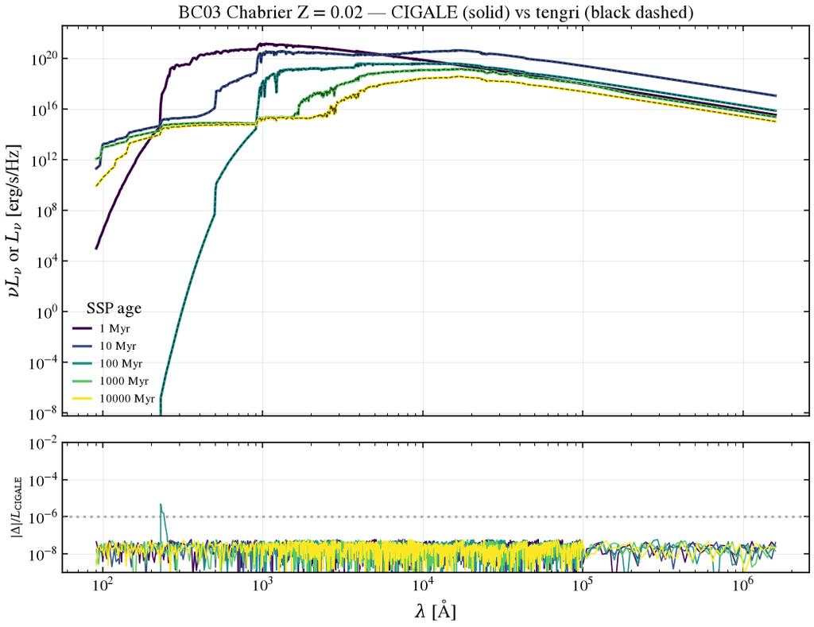

```python
import pickle as _pickle
from pathlib import Path as _P

ages_yr = [1e6, 1e7, 1e8, 1e9, 1e10]

# CIGALE side: raw BC03 Chabrier Z=0.02 pickle, converted W/nm/Msun →
# Lsun/Hz/Msun (the exact conversion used by _drivers/cigale_ssp_to_dsps.py).
import sys as _sys

_pkl_path = next(
    (
        _p / "pcigale" / "data" / "bc03" / "Z=0.02_imf=chab.pickle"
        for _p in map(_P, _sys.path)
        if (_p / "pcigale" / "data" / "bc03" / "Z=0.02_imf=chab.pickle").exists()
    ),
    _P(_sys.prefix)
    / "lib"
    / "python3.12"
    / "site-packages"
    / "pcigale"
    / "data"
    / "bc03"
    / "Z=0.02_imf=chab.pickle",
)
with open(_pkl_path, "rb") as _f:
    _raw = _pickle.load(_f)
_wl_aa = np.asarray(_raw.wl) * 10.0  # nm → Å
cigale_ssp = []
for age_yr in ages_yr:
    ia = int(np.argmin(np.abs(np.asarray(_raw.t) - age_yr / 1e6)))  # raw.t in Myr
    lnu = np.asarray(_raw.spec[:, ia]) * 1e6 * _wl_aa**2 / C_AA / L_SUN  # Lsun/Hz/Msun
    cigale_ssp.append((_wl_aa, lnu * L_SUN))  # → erg/s/Hz/Msun for plotting

i_zsun = int(np.argmin(np.abs(ssp.ssp_lgmet - np.log10(0.02))))
tengri_ssp = []
for age_yr in ages_yr:
    i_age = int(np.argmin(np.abs(ssp.ssp_lg_age_gyr - np.log10(age_yr / 1e9))))
    # ssp_flux axes: (n_met, n_age, n_wave) — metallicity first, then age.
    tengri_ssp.append((ssp.ssp_wave, ssp.ssp_flux[i_zsun, i_age, :] * L_SUN))

# Overlay both codes on one SED axis + a residual panel underneath.
fig, (ax, ax_r) = plt.subplots(
    2, 1, figsize=(9, 7), sharex=True, gridspec_kw={"height_ratios": [3, 1]}
)
colors = plt.cm.viridis(np.linspace(0, 1, len(ages_yr)))
print("§1 SSP residual |tengri − CIGALE| / CIGALE (float32 eps = 1.19e-7):")
for color, age_yr, (w_c, L_c), (w_t, L_t) in zip(colors, ages_yr, cigale_ssp, tengri_ssp):
    label = f"{age_yr / 1e6:g} Myr"
    ax.plot(w_c, L_c, color=color, linewidth=2.0, label=label)
    ax.plot(w_t, L_t, color="k", linewidth=0.8, linestyle="--", alpha=0.7)
    # Residual on the CIGALE wavelength grid (tengri regridded onto it).
    L_t_on_c = U.regrid(w_t, L_t, w_c)
    resid = np.abs(L_t_on_c - L_c) / np.maximum(np.abs(L_c), 1e-30)
    resid[~np.isfinite(resid)] = 0.0
    _pos = L_c > 0
    print(
        f"    {age_yr / 1e6:>6g} Myr: median {np.median(resid[_pos]):.2e}, "
        f"max {resid[_pos].max():.2e}, "
        f"{int((resid[_pos] > 1e-7).sum())}/{int(_pos.sum())} points above 1e-7"
    )
    ax_r.plot(w_c, resid, color=color, linewidth=1.0)
ax.set_xscale("log")
ax.set_yscale("log")
ax.set_ylabel(r"$\nu L_\nu$ or $L_\nu$ [erg/s/Hz]")
ax.set_title("BC03 Chabrier Z = 0.02 — CIGALE (solid) vs tengri (black dashed)")
ax.legend(fontsize=9, title="SSP age")
ax.grid(True, alpha=0.3)
ax_r.set_xscale("log")
ax_r.set_yscale("log")
ax_r.set_xlabel(r"$\lambda$ [Å]")
ax_r.set_ylabel(r"$|\Delta| / L_{\rm CIGALE}$", fontsize=9)
ax_r.set_ylim(1e-9, 1e-2)
ax_r.axhline(1e-6, color="gray", linestyle=":", alpha=0.6)
ax_r.grid(True, alpha=0.3)
fig.tight_layout()
save_fig("cigale_01_ssp_bc03.png")
```

## §2 Star formation histories

Each subsection prints the SFR(t) shape agreement and the mass integral. The two codes sample the same analytic shape on different grids, so CIGALE is interpolated onto tengri's points and the median and worst-point ratios are reported. The plotted maximum of the delayed curve falls at the log node nearest t = τ, which is where the grid is and not a different peak.

**Verification Status:** PARTIAL (11/33): Parametric SFH family physics

### τ-delayed

```
tengri ∫SFR dt = 0.9999 M☉  (log_total_mass=0 → 1.0000)
§2 delayed SFR(t) shape, tengri / CIGALE on tengri's grid: median 1.00002×, max 1.0000× at t = 0.112 Gyr, 0/1970 points more than 1 % off
  common interval: t_c [0.0090, 4.9990] Gyr, t_t range [0.0205, 4.9990] Gyr
```

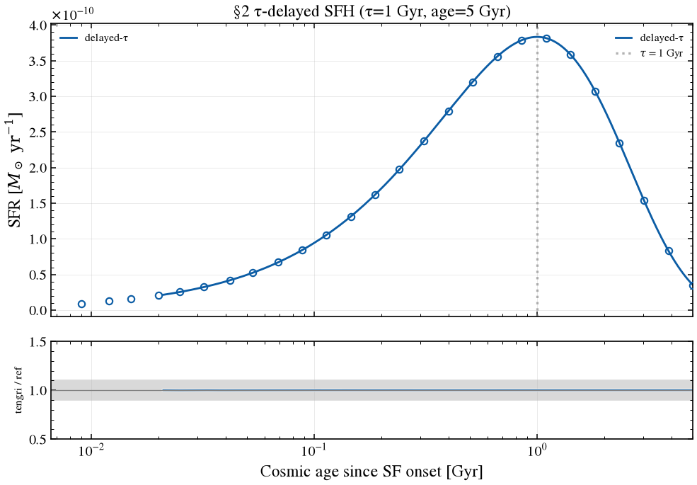

```python
t_c, sfr_c = C.sfh_curve(
    "sfhdelayed",
    tau_main=1000,
    age_main=5000,
    tau_burst=50,
    age_burst=20,
    f_burst=0.0,
    sfr_A=1.0,
    normalise=True,
)

# tengri's actual pipeline SFR history (not the analytic formula): build
# a minimal SEDModel with the delayed SFH and read sfr_history off the
# resulting state. The pipeline samples on the spec's log-spaced
# lookback grid (n_grid=256 by default) — visibly smooth across the
# rise-and-decay. That grid is what every fit downstream sees, so
# plotting it honestly is the test: if the area under this curve doesn't
# integrate to 1 M☉ formed (= log_total_mass = 0.0), tengri's SFH
# normalization is broken regardless of how clean the analytic shape
# looks.
tau_gyr, age_gyr = 1.0, 5.0
_m_sfh = SEDModel.build(
    ssp_data=ssp,
    met=MET_FIDUCIAL,
    sfh={
        "type": "delayed",
        "tau_gyr": Fixed(tau_gyr),
        "age_gyr": Fixed(age_gyr),
        "log_total_mass": Fixed(0.0),
        "all_params": Fixed(DEFAULT),
    },
    dust_attenuation={
        "law": "power_law",
        "type": "two_component",
        "tau_bc": Fixed(0.0),
        "tau_diff": Fixed(0.0),
        "all_params": Fixed(DEFAULT),
    },
    neb=NEB_FIDUCIAL_TENGRI, redshift=Fixed(0.0),
    # dense lookback grid: the table compares the SFH form, not the
    # 256-point diagnostic grid
    n_grid=4096,
)
_state_sfh = _m_sfh.predict_state({})
_lbt_yr = np.asarray(_state_sfh.derived["sfh_grid_lbt_yr"])
_sfr_history = np.asarray(_state_sfh.derived["sfr_history"])
# Convert lookback time → cosmic age since SF onset (consistent with the
# CIGALE x-axis above): t_cosmic = age_gyr - lbt
t_t = (age_gyr - _lbt_yr / 1e9) * 1e9  # yr
sfr_t = _sfr_history
# The SFH grid spans the full cosmic lookback; keep the epoch after formation.
_keep_t = t_t >= 0
t_t_valid = t_t[_keep_t]
sfr_t_valid = sfr_t[_keep_t]
assert t_t_valid.min() >= 0, f"negative cosmic age: min={t_t_valid.min()}"
# Verify normalization: trapezoid of SFR over cosmic-age axis should be
# 10**log_total_mass = 1.0 M☉ within numerical accuracy of the n_grid pipeline.
# tengri's pipeline carries sfh_grid in decreasing lookback time, so
# integrate against the increasing-time order.
_idx = np.argsort(t_t_valid)
_mass_formed = float(np.trapezoid(sfr_t_valid[_idx], t_t_valid[_idx]))
print(f"tengri ∫SFR dt = {_mass_formed:.4f} M☉  (log_total_mass=0 → 1.0000)")


def _sfr_shape_report(label, t_c_yr, sfr_c_arr, t_t_yr, sfr_t_arr, age_gyr):
    """Print the SFR(t) shape agreement on tengri's own grid.

    The two codes sample the same shape on different grids — CIGALE on a
    uniform 1-Myr axis, tengri on a 256-point log-spaced lookback axis — so
    the comparison is CIGALE interpolated onto tengri's points, over the
    interior of the history (the first 2 % and last 1 % of the age are
    dropped: both ends are grid edges, not physics).
    """
    _c_on_t = np.interp(t_t_yr, np.asarray(t_c_yr), np.asarray(sfr_c_arr), left=np.nan, right=np.nan)
    _ok = (
        np.isfinite(_c_on_t)
        & (_c_on_t > 0)
        & (t_t_yr > 0.02 * age_gyr * 1e9)
        & (t_t_yr < 0.99 * age_gyr * 1e9)
    )
    _rr = np.asarray(sfr_t_arr)[_ok] / _c_on_t[_ok]
    _k = int(np.argmax(np.abs(_rr - 1.0)))
    print(
        f"{label} SFR(t) shape, tengri / CIGALE on tengri's grid: "
        f"median {float(np.median(_rr)):.5f}×, max {float(_rr.max()):.4f}× at "
        f"t = {t_t_yr[_ok][_k] / 1e9:.3f} Gyr, "
        f"{int((np.abs(_rr - 1.0) > 0.01).sum())}/{int(_ok.sum())} points more than 1 % off"
    )


_sfr_shape_report("§2 delayed", t_c, sfr_c, t_t_valid, sfr_t_valid, age_gyr)

# Both arms on their common interval.
_t_min_broad = max(t_c.min() / 1e9, t_t_valid.min() / 1e9)
_t_max_broad = min(t_c.max() / 1e9, t_t_valid.max() / 1e9)
_keep_c_1 = (t_c / 1e9 >= _t_min_broad) & (t_c / 1e9 <= _t_max_broad)
_keep_t_1 = (t_t_valid / 1e9 >= _t_min_broad) & (t_t_valid / 1e9 <= _t_max_broad)

_t_c_temp = (t_c / 1e9)[_keep_c_1]
_t_t_temp = (t_t_valid / 1e9)[_keep_t_1]
_t_min_aligned = max(_t_c_temp.min(), _t_t_temp.min())
_keep_final_c = (_t_c_temp >= _t_min_aligned)
_keep_final_t = (_t_t_temp >= _t_min_aligned)
_t_c_overlap = t_c[_keep_c_1][_keep_final_c]
_sfr_c_overlap = sfr_c[_keep_c_1][_keep_final_c]
_t_t_valid_overlap = t_t_valid[_keep_t_1][_keep_final_t]
_sfr_t_valid_overlap = sfr_t_valid[_keep_t_1][_keep_final_t]

print(
    f"  common interval: t_c [{_t_c_overlap.min()/1e9:.4f}, {_t_c_overlap.max()/1e9:.4f}] Gyr, "
    f"t_t range [{_t_t_valid_overlap.min()/1e9:.4f}, {_t_t_valid_overlap.max()/1e9:.4f}] Gyr"
)

fig, (ax, ax_r), ratio = V.sweep_fig(
    [("delayed-τ", _t_c_overlap / 1e9, _sfr_c_overlap, _t_t_valid_overlap / 1e9, _sfr_t_valid_overlap)],
    ref_label="pcigale",
    title="§2 τ-delayed SFH (τ=1 Gyr, age=5 Gyr)",
    xlabel="Cosmic age since SF onset [Gyr]",
    ylabel=r"SFR [$M_\odot\ \mathrm{yr}^{-1}$]",
    xlim=(0, 5),
    logy=False,
)
ax.axvline(1.0, color="gray", linestyle=":", alpha=0.6, label=r"$\tau$ = 1 Gyr")
ax.legend(fontsize=9)
fig.tight_layout()
save_fig("cigale_02_sfh_tau.png")
```

### Note on the FSPS / BAGPIPES declining-exponential

CIGALE's `sfh2exp(f_burst=0)` and FSPS's `sfh=1` both produce a declining exponential peaking at galaxy formation, a *different* shape from CIGALE's `sfhdelayed` plotted above. tengri intentionally does **not** register this shape as `sfh.tau`, to avoid confusion with the τ-delayed model, which has opposite physics; `delayed` (= CIGALE `sfhdelayed`) is the only τ-style SFH in the registry. The `declining_exponential` function remains importable from the `sfh` builder grammar for expert use cases.

### Double-exponential with a burst (sfh2exp)

CIGALE's `sfh2exp` superposes an old declining-exponential population and a recent exponential burst that carries a fixed fraction `f_burst` of the total stellar mass. tengri registers the same form (`sfh.sfh2exp`). At matched parameters (τ_main = 4 Gyr, τ_burst = 0.1 Gyr, f_burst = 0.1, burst 0.3 Gyr ago, age 10 Gyr) the two histories agree everywhere except at the burst onset.

```
tengri ∫SFR dt = 0.9970 M☉  (log_total_mass=0 → 1.0000)
§2 sfh2exp SFR(t) shape, tengri / CIGALE on tengri's grid: median 1.00015×, max 1.0054× at t = 9.699 Gyr, 2/1969 points more than 1 % off
  common interval: t_c2 [0.0130, 9.9990] Gyr, _t_2exp range [0.0354, 9.9990] Gyr
```

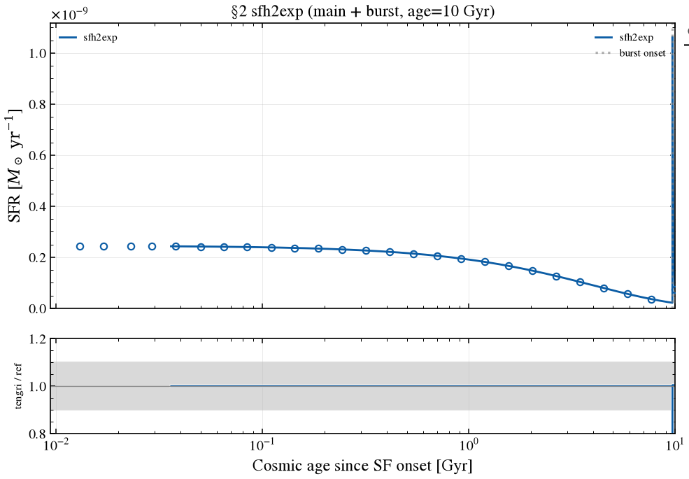

```python
t_c2, sfr_c2 = C.sfh_curve(
    "sfh2exp",
    tau_main=4000,
    tau_burst=100,
    f_burst=0.1,
    age=10000,
    burst_age=300,
    sfr_0=1.0,
    normalise=True,
)

_age_gyr_2exp = 10.0
_m_2exp = SEDModel.build(
    ssp_data=ssp,
    met=MET_FIDUCIAL,
    sfh={
        "type": "sfh2exp",
        "tau_main_gyr": Fixed(4.0),
        "tau_burst_gyr": Fixed(0.1),
        "f_burst": Fixed(0.1),
        "age_gyr": Fixed(_age_gyr_2exp),
        "burst_age_gyr": Fixed(0.3),
        "log_total_mass": Fixed(0.0),
        "all_params": Fixed(DEFAULT),
    },
    dust_attenuation={
        "law": "power_law",
        "type": "two_component",
        "tau_bc": Fixed(0.0),
        "tau_diff": Fixed(0.0),
        "all_params": Fixed(DEFAULT),
    },
    neb=NEB_FIDUCIAL_TENGRI, redshift=Fixed(0.0),
    n_grid=4096,
)
_st_2exp = _m_2exp.predict_state({})
_lbt_2exp = np.asarray(_st_2exp.derived["sfh_grid_lbt_yr"])
_sfr_2exp = np.asarray(_st_2exp.derived["sfr_history"])
_t_2exp = (_age_gyr_2exp - _lbt_2exp / 1e9) * 1e9  # cosmic age since SF onset [yr]
# Restrict to the epoch the galaxy exists: keep only samples with _t_2exp >= 0
_keep_2exp = _t_2exp >= 0
_t_2exp_valid = _t_2exp[_keep_2exp]
_sfr_2exp_valid = _sfr_2exp[_keep_2exp]
assert _t_2exp_valid.min() >= 0, f"negative cosmic age: min={_t_2exp_valid.min()}"
_idx2 = np.argsort(_t_2exp_valid)
_mass_2exp = float(np.trapezoid(_sfr_2exp_valid[_idx2], _t_2exp_valid[_idx2]))
print(f"tengri ∫SFR dt = {_mass_2exp:.4f} M☉  (log_total_mass=0 → 1.0000)")
_sfr_shape_report("§2 sfh2exp", t_c2, sfr_c2, _t_2exp_valid, _sfr_2exp_valid, _age_gyr_2exp)

# Both arms on their common interval.
_t2_min_broad = max(t_c2.min() / 1e9, _t_2exp_valid.min() / 1e9)
_t2_max_broad = min(t_c2.max() / 1e9, _t_2exp_valid.max() / 1e9)
_keep2_c_1 = (t_c2 / 1e9 >= _t2_min_broad) & (t_c2 / 1e9 <= _t2_max_broad)
_keep2_t_1 = (_t_2exp_valid / 1e9 >= _t2_min_broad) & (_t_2exp_valid / 1e9 <= _t2_max_broad)

_t2_c_temp = (t_c2 / 1e9)[_keep2_c_1]
_t2_t_temp = (_t_2exp_valid / 1e9)[_keep2_t_1]
_t2_min_aligned = max(_t2_c_temp.min(), _t2_t_temp.min())
_keep2_final_c = (_t2_c_temp >= _t2_min_aligned)
_keep2_final_t = (_t2_t_temp >= _t2_min_aligned)
_t_c2_overlap = t_c2[_keep2_c_1][_keep2_final_c]
_sfr_c2_overlap = sfr_c2[_keep2_c_1][_keep2_final_c]
_t_2exp_valid_overlap = _t_2exp_valid[_keep2_t_1][_keep2_final_t]
_sfr_2exp_valid_overlap = _sfr_2exp_valid[_keep2_t_1][_keep2_final_t]

print(
    f"  common interval: t_c2 [{_t_c2_overlap.min()/1e9:.4f}, {_t_c2_overlap.max()/1e9:.4f}] Gyr, "
    f"_t_2exp range [{_t_2exp_valid_overlap.min()/1e9:.4f}, {_t_2exp_valid_overlap.max()/1e9:.4f}] Gyr"
)

fig, (ax, ax_r), ratio = V.sweep_fig(
    [("sfh2exp", _t_c2_overlap / 1e9, _sfr_c2_overlap, _t_2exp_valid_overlap / 1e9, _sfr_2exp_valid_overlap)],
    ref_label="pcigale",
    title="§2 sfh2exp (main + burst, age=10 Gyr)",
    xlabel="Cosmic age since SF onset [Gyr]",
    ylabel=r"SFR [$M_\odot\ \mathrm{yr}^{-1}$]",
    xlim=(0, 10),
    logy=False,
    ratio_ylim=(0.8, 1.2),
)
ax.axvline(_age_gyr_2exp - 0.3, color="gray", linestyle=":", alpha=0.6, label="burst onset")
ax.legend(fontsize=9)
ax.set_ylim(bottom=0.0)
fig.tight_layout()
save_fig("cigale_02_sfh2exp.png")
```

### §2c Beyond delayed: delayed_bq, periodic, buat08

Three more parametric SFHs. `delayed_bq` (Ciesla+2017) adds a burst/quench step of ratio `r_sfr` at lookback `age_bq`; `periodic` repeats one burst shape (`burst_type` 0/1/2 = exponential/delayed/ rectangular) every `delta_bursts`; `buat08` sets the shape from a rotational velocity, with the same parameters in Gyr as `sfh.delayed_bq`, `sfh.periodic`, `sfh.buat08`. Seven cases: τ_main=2, age_main=8, age_bq=0.5 Gyr, r_sfr ∈ {0.1, 5}; burst_type ∈ {0, 1, 2} at δ=1, τ=0.2, age=8 Gyr; velocity ∈ {150, 250} km/s at age=8 Gyr. The shapes agree (median ratio 1.000 in every case except periodic exponential, 0.999, and periodic rectangular, 0.993). The large maximum deviations sit on discontinuities, the delayed_bq burst/quench step at T = age_main − age_bq and the periodic burst onsets at T = kΔ, where each code's time grid samples the edge differently. Tabulated histories enter tengri via `Catalog.from_histories`, so `sfhfromfile` is not compared.

```
  §2c SFH families beyond delayed (SFR(t), 2-95% of age; deviation as % of peak SFR)
  case                           median × max |Δ| [% peak]  x at max [Gyr]
  --------------------------------------------------------------------------
  delayed_bq r_sfr=0.1              1.000x           13.7%            7.50  <-- check
  delayed_bq r_sfr=5.0              1.000x           50.7%            7.50  <-- check
  periodic exponential              0.999x           90.5%            4.00  <-- check
  periodic delayed                  1.000x            4.4%            1.00
  periodic rectangular              0.993x           90.8%            4.00  <-- check
  buat08 v=150                      1.000x            0.0%            7.60
  buat08 v=250                      1.000x            0.0%            3.25
```

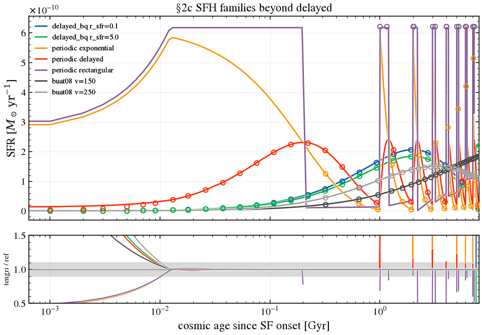

```python
_AGE_2C_GYR = 8.0
_DUST_OFF_2C = {
    "law": "power_law",
    "type": "two_component",
    "tau_bc": Fixed(0.0),
    "tau_diff": Fixed(0.0),
    "all_params": Fixed(DEFAULT),
}
_cases_2c = []

for _r in (0.1, 5.0):
    _t_c, _sfr_c = C.sfh_curve(
        "sfhdelayedbq", tau_main=2000, age_main=8000, age_bq=500, r_sfr=_r, sfr_A=1.0, normalise=True
    )
    _m = SEDModel.build(
        ssp_data=ssp,
        met=MET_FIDUCIAL,
        sfh={
            "type": "delayed_bq",
            "tau_main_gyr": Fixed(2.0),
            "age_main_gyr": Fixed(_AGE_2C_GYR),
            "age_bq_gyr": Fixed(0.5),
            "r_sfr": Fixed(_r),
            "log_total_mass": Fixed(0.0),
            "all_params": Fixed(DEFAULT),
        },
        dust_attenuation=_DUST_OFF_2C,
        neb=NEB_FIDUCIAL_TENGRI, redshift=Fixed(0.0),
        n_grid=4096,
    )
    _st = _m.predict_state({})
    _lbt = np.asarray(_st.derived["sfh_grid_lbt_yr"])
    _sfr_t = np.asarray(_st.derived["sfr_history"])
    _t_t = (_AGE_2C_GYR - _lbt / 1e9) * 1e9
    _idx = np.argsort(_t_t)
    _cases_2c.append((f"delayed_bq r_sfr={_r}", np.asarray(_t_c), np.asarray(_sfr_c), _t_t[_idx], _sfr_t[_idx]))

for _bt in (0, 1, 2):
    _t_c, _sfr_c = C.sfh_curve(
        "sfhperiodic", type_bursts=_bt, delta_bursts=1000, tau_bursts=200, age=8000, sfr_A=1.0, normalise=True
    )
    _m = SEDModel.build(
        ssp_data=ssp,
        met=MET_FIDUCIAL,
        sfh={
            "type": "periodic",
            "delta_bursts_gyr": Fixed(1.0),
            "tau_bursts_gyr": Fixed(0.2),
            "burst_type": Fixed(_bt),
            "age_gyr": Fixed(_AGE_2C_GYR),
            "log_total_mass": Fixed(0.0),
            "all_params": Fixed(DEFAULT),
        },
        dust_attenuation=_DUST_OFF_2C,
        neb=NEB_FIDUCIAL_TENGRI, redshift=Fixed(0.0),
        n_grid=4096,
    )
    _st = _m.predict_state({})
    _lbt = np.asarray(_st.derived["sfh_grid_lbt_yr"])
    _sfr_t = np.asarray(_st.derived["sfr_history"])
    _t_t = (_AGE_2C_GYR - _lbt / 1e9) * 1e9
    _idx = np.argsort(_t_t)
    _label = {0: "exponential", 1: "delayed", 2: "rectangular"}[_bt]
    _cases_2c.append((f"periodic {_label}", np.asarray(_t_c), np.asarray(_sfr_c), _t_t[_idx], _sfr_t[_idx]))

for _v in (150, 250):
    _t_c, _sfr_c = C.sfh_curve("sfh_buat08", velocity=_v, age=8000, normalise=True)
    _m = SEDModel.build(
        ssp_data=ssp,
        met=MET_FIDUCIAL,
        sfh={
            "type": "buat08",
            "velocity_km_s": Fixed(float(_v)),
            "age_gyr": Fixed(_AGE_2C_GYR),
            "log_total_mass": Fixed(0.0),
            "all_params": Fixed(DEFAULT),
        },
        dust_attenuation=_DUST_OFF_2C,
        neb=NEB_FIDUCIAL_TENGRI, redshift=Fixed(0.0),
        n_grid=4096,
    )
    _st = _m.predict_state({})
    _lbt = np.asarray(_st.derived["sfh_grid_lbt_yr"])
    _sfr_t = np.asarray(_st.derived["sfr_history"])
    _t_t = (_AGE_2C_GYR - _lbt / 1e9) * 1e9
    _idx = np.argsort(_t_t)
    _cases_2c.append((f"buat08 v={_v}", np.asarray(_t_c), np.asarray(_sfr_c), _t_t[_idx], _sfr_t[_idx]))

for _label, _wr, _lr, _wt, _lt in _cases_2c:
    _assert_comparable(_lr, _lt, name=f"§2c {_label}")

fig, (ax, ax_r), _ratios_2c = V.sweep_fig(
    _cases_2c,
    ref_label="CIGALE",
    title="§2c SFH families beyond delayed",
    xlim=(0, _AGE_2C_GYR),
    x_of_wave=lambda t: t / 1e9,
    xlabel="cosmic age since SF onset [Gyr]",
    ylabel=r"SFR [$M_\odot\,\mathrm{yr}^{-1}$]",
    logy=False,
)
fig.tight_layout()
save_fig("cigale_02c_sfh_families.png")

_rows_2c = V.window_rows(
    _cases_2c, lo=0.02 * _AGE_2C_GYR * 1e9, hi=0.95 * _AGE_2C_GYR * 1e9, rel_to="peak"
)
V.print_window_table(
    _rows_2c,
    ref_name="CIGALE",
    title="§2c SFH families beyond delayed (SFR(t), 2-95% of age; deviation as % of peak SFR)",
    x_unit="Gyr",
    x_scale=1e-9,
)
```

## §3 Integrated stellar SED

**The one convention difference on this SSP, and where it goes.** The two codes place the same star formation on the same SSP age grid in different ways, and the whole rest of the notebook inherits the result, so it is stated once here.

tengri integrates the SFH onto the age axis with a cloud-in-cell kernel whose integrand extends to lookback zero, so the youngest SSP node (1 Myr on this grid) receives the star formation of the whole `[0, 1 Myr]` parcel. CIGALE gives that node exactly one 1-Myr bin and ages every star by +1 Myr (`pcigale/sed_modules/bc03.py`). tengri therefore carries recent star formation that a native-age binning drops, and since the 1–10 Myr population dominates the ionizing and far-UV output, the difference is strongly wavelength-dependent. Measured on this pair, printed below:

| quantity | tengri / CIGALE |
| --- | --- |
| 912–1200 Å | 1.060× |
| 1200–3000 Å | 1.034× |
| 0.3–1 µm | 1.002× |
| stellar L_bol | 1.016× |
| Q_H (λ < 911.76 Å) | 1.150× |

The 200–912 Å band is not quoted: with the nebular emitter on, both codes absorb nearly every Lyman-continuum photon, so there is nothing to take a ratio of. This is tengri's documented convention, not a defect: the ionizing budget moves toward the analytic continuous SFH→SSP convolution, so the side that drops the parcel is the one that is incomplete.

Three later sections are this table and nothing else. §6's dust IR is normalized to `L_absorbed`, which inherits the L_bol offset weighted toward the UV, and lands at 1.010× CIGALE's `dust.luminosity`. §11's synchrotron is anchored on the same luminosity, so that factor appears there as a flat offset. §8's line luminosities scale with Q_H. None of those is a separate discrepancy.

```python
sed_c = C.run_chain(
    [
        (
            "sfhdelayed",
            dict(
                tau_main=1000,
                age_main=5000,
                tau_burst=50,
                age_burst=20,
                f_burst=0.0,
                sfr_A=1.0,
                normalise=True,
            ),
        ),
        ("bc03", dict(imf=1, metallicity=0.02, separation_age=10)),
        NEB_FIDUCIAL_CIGALE,
    ]
)
w_c, L_c = C.to_lnu(sed_c)

m_stellar = SEDModel.build(
    ssp_data=ssp,
    met=MET_FIDUCIAL,
    sfh={
        "type": "delayed",
        "tau_gyr": Fixed(1.0),
        "age_gyr": Fixed(5.0),
        "log_total_mass": Fixed(0.0),
        "all_params": Fixed(DEFAULT),
    },
    dust_attenuation={
        "law": "power_law",
        "type": "two_component",
        "tau_bc": Fixed(0.0),
        "tau_diff": Fixed(0.0),
        "all_params": Fixed(DEFAULT),
    },
    neb=NEB_FIDUCIAL_TENGRI, redshift=Fixed(0.0),
)
s_stellar = m_stellar.predict_state({})
_assert_comparable(L_c, s_stellar.sed_intrinsic, name="§3 stellar")

# Shared-axis overlay + tengri/CIGALE ratio panel: a single scale makes any
# normalization offset visible at a glance. Both codes form 1 M_sun; the
# tengri box reports its *surviving* stellar mass, so the ratio panel shows
# whether the M_star = 1.0 vs 0.558 label difference is a real SED offset (it is
# not — formed-vs-surviving-mass convention) or a genuine ~1.8x mismatch.
m_star = 10.0 ** float(s_stellar.derived["log_mstar"])
fig, ax, ax_r, ratio = U.overlay_ratio_fig(
    w_c,
    L_c,
    np.asarray(s_stellar.wave),
    np.asarray(s_stellar.sed_intrinsic),
    title="§3 stellar SED — CIGALE sfhdelayed+bc03 vs tengri (both 1 M$_\\odot$ formed)",
    label_c="CIGALE  sfhdelayed + bc03",
    label_t="tengri  sfh.delayed + bc03",
    xlim=(1e2, 1e6),
)
ax.text(
    0.05,
    0.95,
    rf"formed $M_\star = 1\,M_\odot$ both; tengri surviving $M_\star = {m_star:.3f}\,M_\odot$",
    transform=ax.transAxes,
    fontsize=9,
    va="top",
    bbox=dict(boxstyle="round", facecolor="wheat", alpha=0.5),
)
_opt = (w_c >= 1e3) & (w_c <= 1e4) & (L_c > 0)
print(f"§3 stellar tengri/CIGALE median (0.1–1 µm): {float(np.median(ratio[_opt])):.3f}×")

# The age-binning convention, band by band. This is the table the §3 prose
# quotes, and the term every later section inherits.
_L_t_on_c3 = U.regrid(np.asarray(s_stellar.wave), np.asarray(s_stellar.sed_intrinsic), w_c)
# A relative floor, not a bare L_c > 0: the deep Lyman continuum carries a few
# points where CIGALE's flux is positive but numerically negligible, and a
# near-zero denominator turns a real agreement into a meaningless quadrillion-x
# ratio.
_r3 = _L_t_on_c3 / np.where(L_c > 1e-6 * L_c.max(), L_c, np.nan)
print("§3 intrinsic stellar SED, median ratio by band (tengri / CIGALE):")
for _lo, _hi, _wname in (
    (200.0, 912.0, "200–912 Å  "),
    (912.0, 1200.0, "912–1200 Å "),
    (1200.0, 3000.0, "1200–3000 Å"),
    (3000.0, 10000.0, "0.3–1 µm   "),
):
    _m3 = (w_c >= _lo) & (w_c <= _hi) & np.isfinite(_r3)
    if _m3.any():
        print(f"    {_wname}: {float(np.median(_r3[_m3])):.3f}×")
    else:
        print(f"    {_wname}: --   (CIGALE flux below the 1e-6 floor here)")
_pos3 = L_c > 0
_lbol_c3 = _lbol_nu(w_c[_pos3], np.asarray(L_c)[_pos3])
_lbol_t3 = _lbol_nu(w_c[_pos3], _L_t_on_c3[_pos3])
_n_ly_c3 = float(sed_c.info["stellar.n_ly"])
_q_h_t3 = float(np.asarray(s_stellar.derived["nion"]))
print(
    f"    stellar L_bol: CIGALE {_lbol_c3:.4e}, tengri {_lbol_t3:.4e} erg/s "
    f"→ {_lbol_t3 / _lbol_c3:.3f}×"
)
print(
    f"    Q_H          : CIGALE {_n_ly_c3:.4e}, tengri {_q_h_t3:.4e} ph/s "
    f"→ {_q_h_t3 / _n_ly_c3:.3f}×"
)
fig.tight_layout()
plt.close(fig)  # superseded by §3b's tau x age grid, which replaces this panel
```

```
§3 stellar tengri/CIGALE median (0.1–1 µm): 1.010×
§3 intrinsic stellar SED, median ratio by band (tengri / CIGALE):
    200–912 Å  : --   (CIGALE flux below the 1e-6 floor here)
    912–1200 Å : 1.060×
    1200–3000 Å: 1.034×
    0.3–1 µm   : 1.002×
    stellar L_bol: CIGALE 4.7400e+33, tengri 4.8162e+33 erg/s → 1.016×
    Q_H          : CIGALE 5.2700e+42, tengri 6.0590e+42 ph/s → 1.150×
```

### §3b τ × age grid

Stellar SED dependence on the delayed SFH's shape parameters: τ ∈ {0.3, 1, 3} Gyr at age = 1 and 10 Gyr, plus the τ = 1 Gyr, age = 5 Gyr fiducial (7 cases). One tengri build with `sfh_delayed_tau_gyr` and `sfh_delayed_age_gyr` free, evaluated per case via `predict_rest_sed`; one CIGALE `sfhdelayed` + `bc03` chain per case. Table over the GALEX-through-2MASS bands (`UV_TO_NIR`), since this comparison carries no dust IR. The worst band ratio in the printed table is τ = 0.3 Gyr, age = 10 Gyr.

```
§3b τ × age grid (UV_TO_NIR band ratio per case):
  §3b τ=0.3, age=1 Gyr                                 median 1.011x  worst 1.062x  1/10 outside 5%
  §3b τ=1, age=1 Gyr                                   median 1.018x  worst 1.114x  1/10 outside 5%
  §3b τ=3, age=1 Gyr                                   median 1.020x  worst 1.129x  2/10 outside 5%
  §3b τ=0.3, age=10 Gyr                                median 0.999x  worst 0.837x  2/10 outside 5%
  §3b τ=1, age=10 Gyr                                  median 1.000x  worst 0.995x  0/10 outside 5%
  §3b τ=3, age=10 Gyr                                  median 1.005x  worst 1.041x  0/10 outside 5%
  §3b τ=1, age=5 Gyr                                   median 1.004x  worst 1.040x  0/10 outside 5%
```

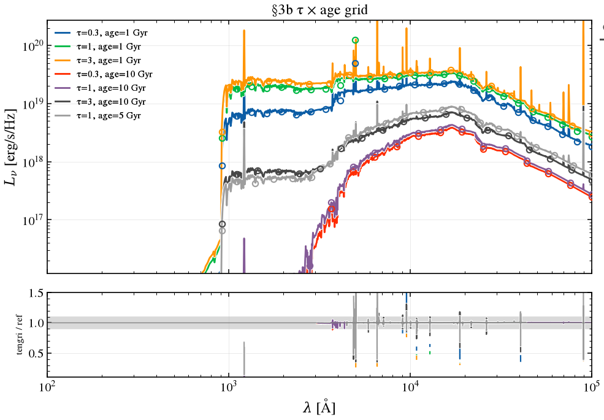

```python
_tau_age_cases_grid = [(0.3, 1.0), (1.0, 1.0), (3.0, 1.0), (0.3, 10.0), (1.0, 10.0), (3.0, 10.0), (1.0, 5.0)]

m_3b = SEDModel.build(
    ssp_data=ssp,
    met=MET_FIDUCIAL,
    sfh={
        "type": "delayed",
        "tau_gyr": Uniform(0.1, 10.0, default=1.0),
        "age_gyr": Uniform(0.5, 13.0, default=5.0),
        "log_total_mass": Fixed(0.0),
        "all_params": Fixed(DEFAULT),
    },
    dust_attenuation={
        "law": "power_law",
        "type": "two_component",
        "tau_bc": Fixed(0.0),
        "tau_diff": Fixed(0.0),
        "all_params": Fixed(DEFAULT),
    },
    neb=NEB_FIDUCIAL_TENGRI, redshift=Fixed(0.0),
)
_p_3b = dict(m_3b.spec.sample(jax.random.PRNGKey(0)))

_cases_3b = []
for _tau, _age in _tau_age_cases_grid:
    _t_main, _a_main = int(round(_tau * 1000)), int(round(_age * 1000))
    _sed_c3b = C.run_chain(
        [
            (
                "sfhdelayed",
                dict(
                    tau_main=_t_main,
                    age_main=_a_main,
                    tau_burst=50,
                    age_burst=20,
                    f_burst=0.0,
                    sfr_A=1.0,
                    normalise=True,
                ),
            ),
            ("bc03", dict(imf=1, metallicity=0.02, separation_age=10)),
            NEB_FIDUCIAL_CIGALE,
        ]
    )
    _w_c3b, _L_c3b = C.to_lnu(_sed_c3b)
    _o_3b = m_3b.predict_rest_sed(
        {**_p_3b, "sfh_delayed_tau_gyr": jnp.float64(_tau), "sfh_delayed_age_gyr": jnp.float64(_age)}
    )
    _cases_3b.append(
        (f"τ={_tau:g}, age={_age:g} Gyr", _w_c3b, _L_c3b, np.asarray(_o_3b.wavelength), np.asarray(_o_3b.sed))
    )
    _assert_comparable(_L_c3b, np.asarray(_o_3b.sed), name=f"§3b tau={_tau} age={_age}")

fig, (ax, ax_r), _ratios_3b = V.sweep_fig(
    _cases_3b, ref_label="CIGALE", title="§3b τ × age grid", xlim=(1e2, 1e5)
)
fig.tight_layout()
save_fig("cigale_03b_tau_age_grid.png")

print("§3b τ × age grid (UV_TO_NIR band ratio per case):")
for _label, _w_ref, _L_ref, _w_t, _L_t in _cases_3b:
    _rows = V.filter_rows_native(np.asarray(_w_t), np.asarray(_L_t), _w_ref, _L_ref, filters=V.UV_TO_NIR)
    V.print_filter_table(_rows, ref_name="CIGALE", title=f"§3b {_label}", compact=True)
```

## §4 Dust attenuation curves

CIGALE's three `dustatt_*` families against tengri's, each side evaluating its own analytic curve on one grid and normalized to `A(λ)/A_V` at 5500 Å. The pairings are by curve, not by module name:

| CIGALE | tengri | shared continuum |
| --- | --- | --- |
| `dustatt_calzleit` | `leitherer02` | Calzetti+2000 with the L02 far-UV extension |
| `dustatt_modified_starburst`, `uv_bump_amplitude = 3` | `noll09(dust_bump_strength=3)` | the same, plus the 2175 Å Drude bump |
| `dustatt_modified_CF00` | `power_law` twice, `slope_ISM = −0.7` + `slope_BC = −1.3` | (λ/5500 Å)^δ, two screens |

`calzleit` is paired with `leitherer02`, not with tengri's `calzetti`: CIGALE's curve carries the Leitherer far-UV extension and tengri's bare `calzetti` does not, which is an 8.4 % gap below 1500 Å between two laws that are not the same law. `modified_CF00` needs two curves on each side: CIGALE attenuates young stars through the birth cloud *and* the ISM (`Av_BC = Av_ISM(1−µ)/µ = 1.53` at the defaults), so a single (λ/5500 Å)^−0.7 is the wrong object to compare it against.

**The one real convention difference is the Leitherer↔Calzetti crossover.** CIGALE hands over at 1500 Å (`a_vs_ebv`), tengri at 1800 Å, which is the upper end of the 912–1800 Å range Leitherer et al. (2002) state for their fit. That is the whole of the printed max |Δ| below; away from 1500–1800 Å the pairs agree to 0.000 %. tengri is the reference here: pcigale's own `k_leitherer2002` docstring gives the range as 91.2–180 nm while `a_vs_ebv` truncates it at 150 nm.

Below the Lyman limit the two diverge by construction: CIGALE's curves are zero there, tengri's polynomial continues unless `dust_attenuation={'lyman_cutoff': True}` clips it. Every applied-dust section below sets that flag; see §5.

**Verification Status:** CROSSVAL: Attenuation law library

```
§4 attenuation law parity (tengri / CIGALE, A_λ/A_V):
  calzleit ↔ leitherer02             max|Δ|  0.252%  median ratio 1.00000  (outside 1500–1800 Å: max|Δ|  0.000%)
  modified_starburst ↔ noll09        max|Δ|  0.247%  median ratio 1.00000  (outside 1500–1800 Å: max|Δ|  0.000%)
  modified_CF00 ↔ power_law × 2      max|Δ|  0.000%  median ratio 1.00000  (outside 1500–1800 Å: max|Δ|  0.000%)
  for contrast, calzleit ↔ calzetti (no L02 extension) below 1500 Å: max|Δ| 8.4%
```

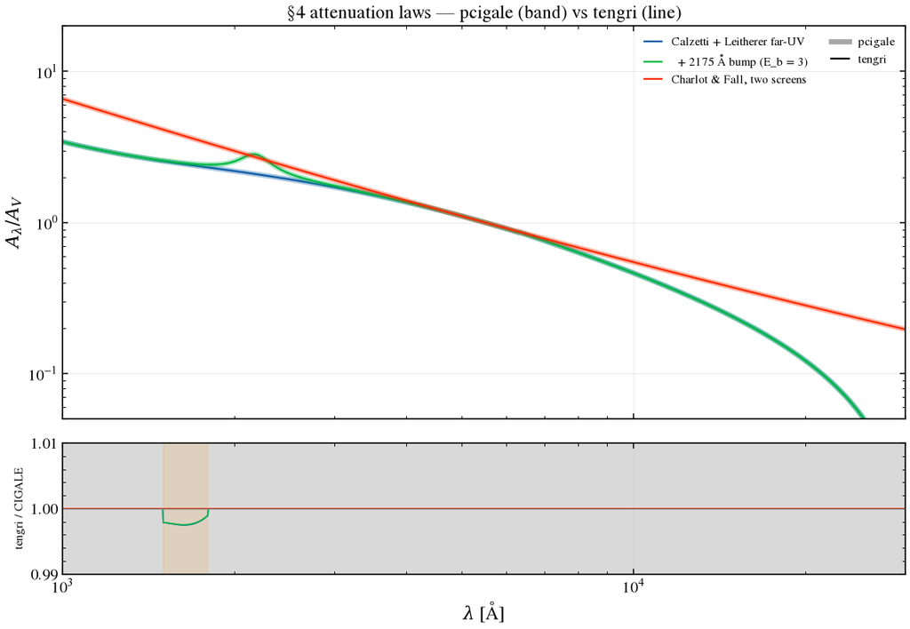

```python
from tengri.dust import list_laws

_tengri_laws = list_laws(headline=False).to_dict("fn")  # {name: fn(wave_aa) -> k at tau_V=1}
wave_law = np.logspace(np.log10(1000.0), np.log10(30000.0), 2000)


def _norm_AV(wave, A):
    """A(λ) normalized to A_V at 5500 Å."""
    return A / A[np.argmin(np.abs(wave - 5500.0))]


# CIGALE's bump/slope arguments are the module defaults except where a pair
# exercises one of them: bump_wave and bump_width in nm, bump_ampl the
# Milky-Way 3.0 for the second pair, power_slope 0.
_BUMP_KW = dict(bump_wave=217.5, bump_width=35.0, bump_ampl=0.0, power_slope=0.0)

_A_ISM, _MU = 1.2, 0.44
_AV_BC = _A_ISM * (1.0 - _MU) / _MU  # CIGALE ModCF00Att._init_code

# Charlot & Fall: the curve a young star sees is both screens in series.
# CIGALE returns A(λ)/A_V per screen, so compose in magnitudes before
# normalizing; tengri's law functions return k(λ) with k(5500 Å) = 1, so the
# same composition is A_V-weighted there.
_cf00_c = _A_ISM * C.attenuation_curve(
    "dustatt_modified_CF00", wave_law, delta=-0.7
) + _AV_BC * C.attenuation_curve("dustatt_modified_CF00", wave_law, delta=-1.3)
_cf00_t = _A_ISM * np.asarray(
    _tengri_laws["power_law"](wave_law, dust_slope=-0.7)
) + _AV_BC * np.asarray(_tengri_laws["power_law"](wave_law, dust_slope=-1.3))

_law_pairs = [
    (
        "Calzetti + Leitherer far-UV",
        C.attenuation_curve("dustatt_calzleit", wave_law, **_BUMP_KW),
        np.asarray(_tengri_laws["leitherer02"](wave_law)),
        "calzleit ↔ leitherer02",
    ),
    (
        "  + 2175 Å bump (E_b = 3)",
        C.attenuation_curve("dustatt_modified_starburst", wave_law, **{**_BUMP_KW, "bump_ampl": 3.0}),
        np.asarray(_tengri_laws["noll09"](wave_law, dust_bump_strength=3.0)),
        "modified_starburst ↔ noll09",
    ),
    (
        "Charlot & Fall, two screens",
        _cf00_c,
        _cf00_t,
        "modified_CF00 ↔ power_law × 2",
    ),
]

# pcigale thick and translucent, tengri thin on top (the §6-knobs
# convention): agreement reads as a line down the middle of its own halo.
fig, (ax, ax_r) = plt.subplots(
    2, 1, figsize=(10, 7), sharex=True, gridspec_kw={"height_ratios": [3, 1]}
)
print("§4 attenuation law parity (tengri / CIGALE, A_λ/A_V):")
for (label, A_c, A_t, pair), color in zip(_law_pairs, ("C0", "C1", "C3")):
    a_c, a_t = _norm_AV(wave_law, A_c), _norm_AV(wave_law, A_t)
    ax.plot(wave_law, a_c, color=color, lw=4.0, alpha=0.35, solid_capstyle="round")
    ax.plot(wave_law, a_t, color=color, lw=1.4, label=label)
    _r = a_t / np.where(a_c > 0, a_c, np.nan)
    ax_r.plot(wave_law, _r, color=color, lw=1.0)
    _cross = (wave_law >= 1500.0) & (wave_law <= 1800.0)
    print(
        f"  {pair:34s} max|Δ| {float(np.nanmax(np.abs(_r - 1.0))) * 100:6.3f}%  "
        f"median ratio {float(np.nanmedian(_r)):.5f}  "
        f"(outside 1500–1800 Å: max|Δ| "
        f"{float(np.nanmax(np.abs(_r[~_cross] - 1.0))) * 100:6.3f}%)"
    )

# The mispairing this section avoids, measured rather than asserted: tengri's
# bare ``calzetti`` against the same CIGALE calzleit curve, below 1500 Å.
_a_c_cz = _norm_AV(wave_law, C.attenuation_curve("dustatt_calzleit", wave_law, **_BUMP_KW))
_a_t_cz = _norm_AV(wave_law, np.asarray(_tengri_laws["calzetti"](wave_law)))
_m_fuv = wave_law < 1500.0
print(
    f"  for contrast, calzleit ↔ calzetti (no L02 extension) below 1500 Å: "
    f"max|Δ| {float(np.abs(_a_t_cz[_m_fuv] / _a_c_cz[_m_fuv] - 1.0).max()) * 100:.1f}%"
)

ax.plot([], [], "k-", lw=4.0, alpha=0.35, label="pcigale")
ax.plot([], [], "k-", lw=1.4, label="tengri")
ax.set(xscale="log", yscale="log", xlim=(1e3, 3e4), ylim=(0.05, 20))
ax.set_ylabel(r"$A_\lambda / A_V$")
ax.set_title("§4 attenuation laws — pcigale (band) vs tengri (line)")
ax.legend(fontsize=9, ncol=2)
ax.grid(True, alpha=0.3)
ax_r.axhspan(0.99, 1.01, color="0.85", zorder=0)
ax_r.axhline(1.0, color="0.5", lw=0.8)
ax_r.axvspan(1500.0, 1800.0, color="C2", alpha=0.12, zorder=0)
ax_r.set(xscale="log", ylim=(0.99, 1.01))
ax_r.set_xlabel(r"$\lambda$ [Å]")
ax_r.set_ylabel("tengri / CIGALE", fontsize=9)
ax_r.grid(True, alpha=0.3)
fig.tight_layout()
save_fig("cigale_04_dust_attenuation.png")
plt.show()
```

## §5 Dust attenuation applied

Fiducial galaxy with and without attenuation. CIGALE uses `modified_starburst` at E(B−V)_lines = 0.3; tengri uses the two-component Calzetti law at τ_BC and τ_diff derived from the same E(B−V)_lines via `cigale_ebv_lines_to_tau`.

**Verification Status:** PARTIAL (2/88): Two-component attenuation (birth cloud and diffuse)

```python
sed_c_nodust = C.run_chain(
    [
        (
            "sfhdelayed",
            dict(
                tau_main=1000,
                age_main=5000,
                tau_burst=50,
                age_burst=20,
                f_burst=0.0,
                sfr_A=1.0,
                normalise=True,
            ),
        ),
        ("bc03", dict(imf=1, metallicity=0.02, separation_age=10)),
        NEB_FIDUCIAL_CIGALE,
    ]
)
w_c_nd, L_c_nd = C.to_lnu(sed_c_nodust)

sed_c_dust = C.run_chain(
    [
        (
            "sfhdelayed",
            dict(
                tau_main=1000,
                age_main=5000,
                tau_burst=50,
                age_burst=20,
                f_burst=0.0,
                sfr_A=1.0,
                normalise=True,
            ),
        ),
        ("bc03", dict(imf=1, metallicity=0.02, separation_age=10)),
        NEB_FIDUCIAL_CIGALE,
        ("dustatt_modified_starburst", dict(E_BV_lines=0.3)),
    ]
)
w_c_d, L_c_d = C.to_lnu(sed_c_dust)

m_nd = SEDModel.build(
    ssp_data=ssp,
    met=MET_FIDUCIAL,
    sfh={
        "type": "delayed",
        "tau_gyr": Fixed(1.0),
        "age_gyr": Fixed(5.0),
        "log_total_mass": Fixed(0.0),
        "all_params": Fixed(DEFAULT),
    },
    dust_attenuation={
        "law": "power_law",
        "type": "two_component",
        "tau_bc": Fixed(0.0),
        "tau_diff": Fixed(0.0),
        "all_params": Fixed(DEFAULT),
    },
    neb=NEB_FIDUCIAL_TENGRI, redshift=Fixed(0.0),
)
s_nd = m_nd.predict_state({})

m_d = SEDModel.build(
    ssp_data=ssp,
    met=MET_FIDUCIAL,
    sfh={
        "type": "delayed",
        "tau_gyr": Fixed(1.0),
        "age_gyr": Fixed(5.0),
        "log_total_mass": Fixed(0.0),
        "all_params": Fixed(DEFAULT),
    },
    dust_attenuation={
        "type": "two_component",
        "law_bc": "leitherer02",
        "law_diff": "leitherer02",
        "tau_bc": Fixed(TAU_BC_FIDUCIAL),
        "tau_diff": Fixed(TAU_DIFF_FIDUCIAL),
        # Match CIGALE's ``dustatt_modified_starburst``, which zeros its curve
        # below the Lyman limit (LyC photons ionize H rather than heat dust).
        # Without this tengri's leitherer02 polynomial extrapolates through the
        # FUV and over-attenuates λ < 912 Å relative to CIGALE.
        "lyman_cutoff": True,
        "all_params": Fixed(DEFAULT),
    },
    neb=NEB_FIDUCIAL_TENGRI, redshift=Fixed(0.0),
)
s_d = m_d.predict_state({})
_assert_comparable(L_c_d, s_d.derived["sed_dust_attenuated"], name="§5 dust applied")

# The four panels are two comparisons — intrinsic and attenuated — and a
# side-by-side layout with independent y-axes cannot show a normalization
# offset in either. One number each.
print("§5 attenuation applied (tengri / CIGALE, on CIGALE's grid):")
for _name, _wc, _Lc, _wt, _Lt in (
    ("intrinsic ", w_c_nd, L_c_nd, np.asarray(s_nd.wave), np.asarray(s_nd.sed_intrinsic)),
    (
        "attenuated",
        w_c_d,
        L_c_d,
        np.asarray(s_d.wave),
        np.asarray(s_d.derived["sed_dust_attenuated"]),
    ),
):
    _Lt_on_c = U.regrid(_wt, _Lt, _wc)
    _r5 = _Lt_on_c / np.where(_Lc > 0, _Lc, np.nan)
    for _lo, _hi, _wname in ((912.0, 1200.0, "912–1200 Å"), (1000.0, 10000.0, "0.1–1 µm  ")):
        _m5 = (_wc >= _lo) & (_wc <= _hi) & np.isfinite(_r5)
        _d5 = np.abs(_r5[_m5] - 1.0)
        # Where the worst point is, not just how bad it is: on this ~20 Å
        # optical grid the extremum is a single point in a line or a deep
        # absorption trough, and the median is what the panel shows.
        print(
            f"    {_name} {_wname}: median {float(np.median(_r5[_m5])):.4f}×, "
            f"max |Δ| {float(_d5.max()) * 100:.2f}% at "
            f"{float(_wc[_m5][int(np.argmax(_d5))]):.0f} Å"
        )

fig, ((ax_l1, ax_r1), (ax_l2, ax_r2)) = plt.subplots(2, 2, sharey=True, figsize=(12, 8))
U.panel(ax_l1, ax_r1, label_l="pcigale  intrinsic", label_r="tengri  intrinsic")
U.panel(
    ax_l2,
    ax_r2,
    label_l="pcigale  modified_starburst  (E(B−V)_lines = 0.3)",
    label_r=rf"tengri  two-component Calzetti  ($\tau_{{BC}}$={TAU_BC_FIDUCIAL:.2f}, "
    rf"$\tau_{{diff}}$={TAU_DIFF_FIDUCIAL:.2f})",
)
ax_l1.plot(w_c_nd, L_c_nd, "C0-", linewidth=1.5)
ax_r1.plot(s_nd.wave, s_nd.sed_intrinsic, "C1-", linewidth=1.5)
ax_l2.plot(w_c_d, L_c_d, "C0-", linewidth=1.5)
ax_r2.plot(s_d.wave, s_d.derived["sed_dust_attenuated"], "C1-", linewidth=1.5)
_ymax = float(np.asarray(s_nd.sed_intrinsic).max())
for ax in (ax_l1, ax_r1, ax_l2, ax_r2):
    ax.set_ylim(_ymax * 1e-6, _ymax * 2)
    ax.grid(True, alpha=0.3)
fig.tight_layout()
plt.close(fig)  # superseded by §5b's attenuation-knob grids, which replace this panel
```

```
§5 attenuation applied (tengri / CIGALE, on CIGALE's grid):
    intrinsic  912–1200 Å: median 1.0604×, max |Δ| 14.50% at 915 Å
    intrinsic  0.1–1 µm  : median 1.0093×, max |Δ| 923.04% at 1214 Å
    attenuated 912–1200 Å: median 1.0561×, max |Δ| 12.02% at 915 Å
    attenuated 0.1–1 µm  : median 0.9988×, max |Δ| 94.48% at 1216 Å
```

### §5b Attenuation knobs

Two more attenuation modules. `dustatt_modified_starburst` at E(B−V)_lines ∈ {0.1, 0.3, 0.6} × `uv_bump_amplitude` ∈ {0, 3} (6 cases) → tengri `two_component`, law `noll09` on both screens, `tau_diff` from the Setup E→τ conversion, `tau_bc = 0`, `bump_strength_diff` matching the bump. `dustatt_2powerlaws` (Av_BC=1.0, slope_BC=−1.3, BC_to_ISM_factor=0.44) at slope_ISM ∈ {−0.4, −0.7, −1.0} (3 cases) → tengri `power_law` on both screens, `tau_bc = 1.0/1.086`, `tau_diff = (1.0/0.44)/1.086` (CIGALE sets Av_ISM = Av_BC / BC_to_ISM_factor, not the product). Both attenuated SEDs against the `UV_TO_NIR` bands; both stand-alone A(λ)/A_V curves against `C.attenuation_curve` over 1216–3000 Å. This fiducial galaxy is old-star dominated, so the ISM screen carries almost all the attenuation and the `2powerlaws` ratio does not move with `slope_ISM`.

```
§5b modified_starburst E(B-V) × bump grid (UV_TO_NIR):
  §5b E(B-V)=0.1, bump=0                               median 0.998x  worst 0.952x  0/10 outside 5%
  §5b E(B-V)=0.3, bump=0                               median 0.998x  worst 0.970x  0/10 outside 5%
  §5b E(B-V)=0.6, bump=0                               median 0.999x  worst 1.034x  0/10 outside 5%
  §5b E(B-V)=0.1, bump=3                               median 0.998x  worst 0.953x  0/10 outside 5%
  §5b E(B-V)=0.3, bump=3                               median 0.999x  worst 1.028x  0/10 outside 5%
  §5b E(B-V)=0.6, bump=3                               median 1.001x  worst 1.044x  0/10 outside 5%
```

```
§5b 2powerlaws slope_ISM sweep (UV_TO_NIR):
  §5b slope_ISM=-0.4                                   median 1.000x  worst 1.022x  0/10 outside 5%
  §5b slope_ISM=-0.7                                   median 1.000x  worst 1.022x  0/10 outside 5%
  §5b slope_ISM=-1.0                                   median 1.000x  worst 1.022x  0/10 outside 5%

  §5b A(λ)/A_V, modified_starburst screen, 1216-3000 Å
  case                           median ×     max |Δ| [%]    x at max [Å]
  --------------------------------------------------------------------------
  bump=0                            1.000x            0.3%         1632.34
  bump=3                            1.000x            0.2%         1629.57
```

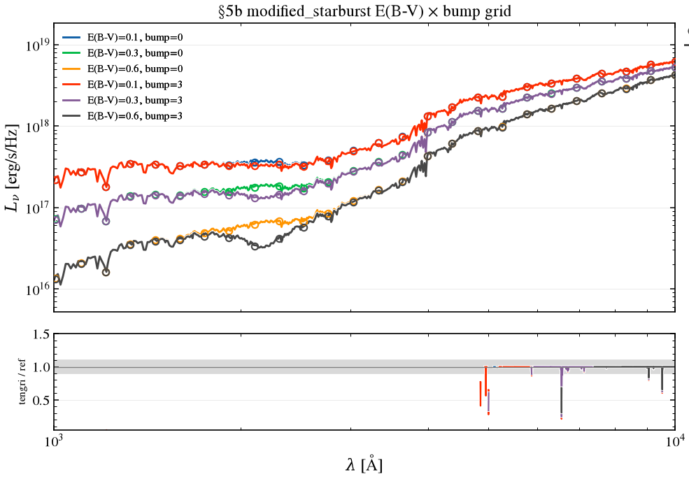

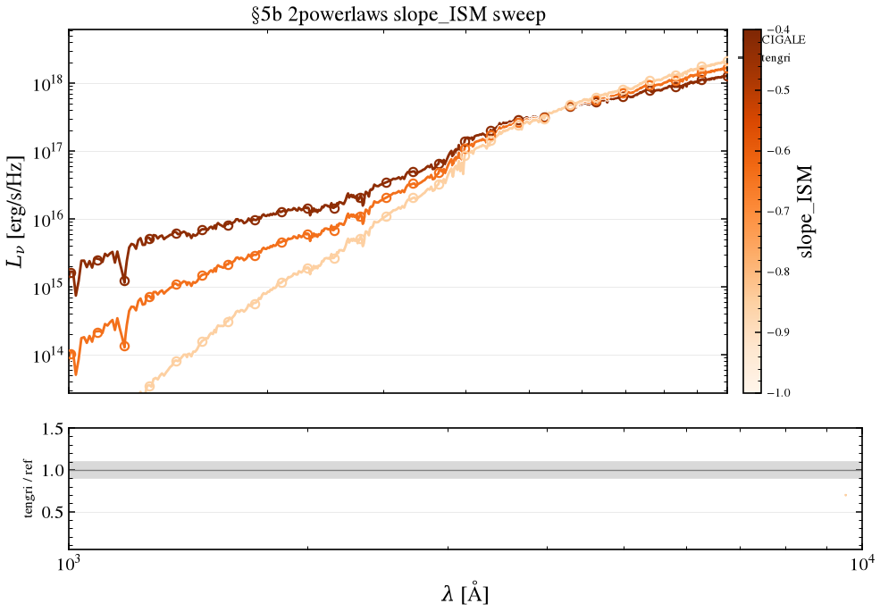

```python
_cases_5b_noll = []
for _ebv, _bump in [(0.1, 0.0), (0.3, 0.0), (0.6, 0.0), (0.1, 3.0), (0.3, 3.0), (0.6, 3.0)]:
    _tau_d = _R_V_CALZETTI * _F_CONT_OVER_LINES * _ebv / 1.086
    _sed_cn = C.run_chain(
        [
            (
                "sfhdelayed",
                dict(
                    tau_main=1000,
                    age_main=5000,
                    tau_burst=50,
                    age_burst=20,
                    f_burst=0.0,
                    sfr_A=1.0,
                    normalise=True,
                ),
            ),
            ("bc03", dict(imf=1, metallicity=0.02, separation_age=10)),
            NEB_FIDUCIAL_CIGALE,
            ("dustatt_modified_starburst", dict(E_BV_lines=_ebv, uv_bump_amplitude=_bump)),
        ]
    )
    _w_cn, _L_cn = C.to_lnu(_sed_cn)
    _m_n = SEDModel.build(
        ssp_data=ssp,
        met=MET_FIDUCIAL,
        sfh={
            "type": "delayed",
            "tau_gyr": Fixed(1.0),
            "age_gyr": Fixed(5.0),
            "log_total_mass": Fixed(0.0),
            "all_params": Fixed(DEFAULT),
        },
        dust_attenuation={
            "type": "two_component",
            "law_bc": "noll09",
            "law_diff": "noll09",
            "tau_bc": Fixed(0.0),
            "tau_diff": Fixed(_tau_d),
            "bump_strength_diff": _bump,
            "lyman_cutoff": True,
            "all_params": Fixed(DEFAULT),
        },
        neb=NEB_FIDUCIAL_TENGRI, redshift=Fixed(0.0),
    )
    _s_n = _m_n.predict_state({})
    _cases_5b_noll.append(
        (
            f"E(B-V)={_ebv}, bump={_bump:g}",
            _w_cn,
            _L_cn,
            np.asarray(_s_n.wave),
            np.asarray(_s_n.derived["sed_dust_attenuated"]),
        )
    )
    _assert_comparable(_L_cn, np.asarray(_s_n.derived["sed_dust_attenuated"]), name=f"§5b noll09 {_ebv},{_bump}")

fig, (ax, ax_r), _ratios_5bn = V.sweep_fig(
    _cases_5b_noll, ref_label="CIGALE", title="§5b modified_starburst E(B-V) × bump grid", xlim=(1e3, 1e4)
)
fig.tight_layout()
save_fig("cigale_05b_noll09_grid.png")
print("§5b modified_starburst E(B-V) × bump grid (UV_TO_NIR):")
for _label, _w_ref, _L_ref, _w_t, _L_t in _cases_5b_noll:
    _rows = V.filter_rows_native(np.asarray(_w_t), np.asarray(_L_t), _w_ref, _L_ref, filters=V.UV_TO_NIR)
    V.print_filter_table(_rows, ref_name="CIGALE", title=f"§5b {_label}", compact=True)

_cases_5b_2pl = []
for _slope_ism in (-0.4, -0.7, -1.0):
    _sed_c2p = C.run_chain(
        [
            (
                "sfhdelayed",
                dict(
                    tau_main=1000,
                    age_main=5000,
                    tau_burst=50,
                    age_burst=20,
                    f_burst=0.0,
                    sfr_A=1.0,
                    normalise=True,
                ),
            ),
            ("bc03", dict(imf=1, metallicity=0.02, separation_age=10)),
            NEB_FIDUCIAL_CIGALE,
            (
                "dustatt_2powerlaws",
                dict(Av_BC=1.0, slope_BC=-1.3, BC_to_ISM_factor=0.44, slope_ISM=_slope_ism),
            ),
        ]
    )
    _w_c2p, _L_c2p = C.to_lnu(_sed_c2p)
    _m_2p = SEDModel.build(
        ssp_data=ssp,
        met=MET_FIDUCIAL,
        sfh={
            "type": "delayed",
            "tau_gyr": Fixed(1.0),
            "age_gyr": Fixed(5.0),
            "log_total_mass": Fixed(0.0),
            "all_params": Fixed(DEFAULT),
        },
        dust_attenuation={
            "type": "two_component",
            "law_bc": "power_law",
            "law_diff": "power_law",
            "slope_bc": -1.3,
            "slope_diff": _slope_ism,
            # CIGALE's dustatt_2powerlaws sets Av_ISM = Av_BC / BC_to_ISM_factor
            # (dustatt_2powerlaws.py _init_code), not Av_BC * factor despite the
            # parameter's "Av ISM / Av BC (<1)" docstring -- verified against the
            # installed module directly.
            "tau_bc": Fixed(1.0 / 1.086),
            "tau_diff": Fixed((1.0 / 0.44) / 1.086),
            "lyman_cutoff": True,
            "all_params": Fixed(DEFAULT),
        },
        neb=NEB_FIDUCIAL_TENGRI, redshift=Fixed(0.0),
    )
    _s_2p = _m_2p.predict_state({})
    _cases_5b_2pl.append(
        (
            f"slope_ISM={_slope_ism}",
            _w_c2p,
            _L_c2p,
            np.asarray(_s_2p.wave),
            np.asarray(_s_2p.derived["sed_dust_attenuated"]),
        )
    )
    _assert_comparable(
        _L_c2p, np.asarray(_s_2p.derived["sed_dust_attenuated"]), name=f"§5b 2powerlaws {_slope_ism}"
    )

fig, (ax, ax_r), _ratios_5b2 = V.sweep_fig(
    _cases_5b_2pl, ref_label="CIGALE", title="§5b 2powerlaws slope_ISM sweep", xlim=(1e3, 1e4),
    cmap="Oranges",
    values=[-0.4, -0.7, -1.0],
    param_label="slope_ISM",
)
fig.tight_layout()
save_fig("cigale_05c_2powerlaws_slope.png")
print("§5b 2powerlaws slope_ISM sweep (UV_TO_NIR):")
for _label, _w_ref, _L_ref, _w_t, _L_t in _cases_5b_2pl:
    _rows = V.filter_rows_native(np.asarray(_w_t), np.asarray(_L_t), _w_ref, _L_ref, filters=V.UV_TO_NIR)
    V.print_filter_table(_rows, ref_name="CIGALE", title=f"§5b {_label}", compact=True)

# Stand-alone A(λ)/A_V curves (no SFH/SSP, no E(B-V) scale — the ratio is
# shape-only), the same way §4 reads each law's own analytic function.
_wave_5b = np.logspace(np.log10(1000.0), np.log10(30000.0), 2000)
_cases_5b_curve = []
for _bump in (0.0, 3.0):
    _A_c = _norm_AV(
        _wave_5b,
        C.attenuation_curve(
            "dustatt_modified_starburst", _wave_5b, bump_wave=217.5, bump_width=35.0,
            bump_ampl=_bump, power_slope=0.0,
        ),
    )
    _A_t = _norm_AV(_wave_5b, np.asarray(_tengri_laws["noll09"](_wave_5b, dust_bump_strength=_bump)))
    _cases_5b_curve.append((f"bump={_bump:g}", _wave_5b, _A_c, _wave_5b, _A_t))
_rows_5b_curve = V.window_rows(_cases_5b_curve, lo=1216.0, hi=3000.0)
V.print_window_table(_rows_5b_curve, ref_name="CIGALE", title="§5b A(λ)/A_V, modified_starburst screen, 1216-3000 Å")
```

## §6 Dust IR re-emission and energy balance

**The energy anchor.** tengri's `L_absorbed` sits 1.0 % above CIGALE's `dust.luminosity` (printed below). That is §3's age-binning convention arriving here: the absorbed luminosity is an integral over the attenuated far-UV and optical, weighted toward the wavelengths where tengri's youngest SSP node adds flux. The two codes' attenuation *curves* are not the cause: §4 measures them agreeing to 0.000 % away from the 1500–1800 Å crossover, and the absorbed fractions they produce are printed below (0.359 for CIGALE, 0.357 for tengri). Since the IR is normalized to that anchor, it appears in the printed 10–100 µm median as a floor under whatever the templates themselves do.

**Lyman continuum.** tengri's attenuation curves polynomial-extend through the FUV; CIGALE zeros attenuation below 912 Å, and the models here set `dust_attenuation={'lyman_cutoff': True}` to match. This changes the emergent far-UV continuum, which is what §7's panel shows, and *not* the IR budget: `L_absorbed` masks λ < 912 Å unconditionally, on the reasoning that Lyman-continuum photons ionize hydrogen rather than heat dust. The IR here is bit-identical with and without the flag.

**Verification Status:** CROSSVAL: Dust IR emission versus BAGPIPES

```python
sed_c_ir = C.run_chain(
    [
        (
            "sfhdelayed",
            dict(
                tau_main=1000,
                age_main=5000,
                tau_burst=50,
                age_burst=20,
                f_burst=0.0,
                sfr_A=1.0,
                normalise=True,
            ),
        ),
        ("bc03", dict(imf=1, metallicity=0.02, separation_age=10)),
        NEB_FIDUCIAL_CIGALE,
        ("dustatt_modified_starburst", dict(E_BV_lines=0.3)),
        ("dale2014", dict(alpha=2.0)),
    ]
)
w_c_ir, L_c_ir = C.to_lnu(sed_c_ir)

m_ir = SEDModel.build(
    ssp_data=ssp,
    met=MET_FIDUCIAL,
    sfh={
        "type": "delayed",
        "tau_gyr": Fixed(1.0),
        "age_gyr": Fixed(5.0),
        "log_total_mass": Fixed(0.0),
        "all_params": Fixed(DEFAULT),
    },
    dust_attenuation={
        "type": "two_component",
        "law_bc": "leitherer02",
        "law_diff": "leitherer02",
        "tau_bc": Fixed(TAU_BC_FIDUCIAL),
        "tau_diff": Fixed(TAU_DIFF_FIDUCIAL),
        # Lyman-limit clip (CIGALE parity) — see §5. The dust IR is energy-balance
        # normalized to L_absorbed, whose integral already excludes λ < 912 Å, so
        # this only changes the emergent FUV continuum, not the IR budget.
        "lyman_cutoff": True,
        "all_params": Fixed(DEFAULT),
    },
    dust_emission={"type": "dale2014_cigale", "alpha_dale": Fixed(2.0), "all_params": Fixed(DEFAULT)},
    neb=NEB_FIDUCIAL_TENGRI, redshift=Fixed(0.0),
)
s_ir = m_ir.predict_state({})
L_abs = float(s_ir.derived.get("L_absorbed", 0.0))
L_emit = float(s_ir.derived.get("L_ir", 0.0))
residual = abs(L_abs - L_emit) / max(L_abs, 1e-30)
_assert_comparable(L_c_ir, s_ir.sed_intrinsic, name="§6 IR")

# Shared-axis overlay + ratio panel: the FIR-peak partition difference is
# only readable on one scale.
fig, ax, ax_r, ratio = U.overlay_ratio_fig(
    w_c_ir,
    L_c_ir,
    np.asarray(s_ir.wave),
    np.asarray(s_ir.sed_intrinsic),
    title="§6 stellar + Dale+2014 dust IR — CIGALE vs tengri",
    label_c="CIGALE  + Dale+2014 (α = 2)",
    label_t="tengri  + dust.emission.dale2014 (α = 2)",
    xlim=(1e3, 5e6),
    dyn_range=1e-4,
)
ax.text(
    0.98,
    0.05,
    rf"tengri $|L_{{\rm IR}} - L_{{\rm abs}}|/L_{{\rm abs}} = {residual:.1e}$",
    transform=ax.transAxes,
    fontsize=9,
    ha="right",
    va="bottom",
    bbox=dict(boxstyle="round", facecolor="wheat", alpha=0.7),
)
_fir = (w_c_ir >= 1e5) & (w_c_ir <= 1e6) & (L_c_ir > 0)
print(f"§6 dust IR tengri/CIGALE median (10–100 µm): {float(np.median(ratio[_fir])):.3f}×")

# The energy anchor the IR is normalized to, and the absorbed fraction that
# sets it. Printed because §6's IR ratio, §11's synchrotron amplitude and the
# capstone's FIR all rest on this one number, and it is not the attenuation
# curve (§4) — it is the §3 age-binning convention reaching the integral.
_L_DUST_C = float(sed_c_ir.info["dust.luminosity"]) * 1e7
_L_STAR_C = float(sed_c_ir.info["stellar.lum"]) * 1e7
# §3's dust-free twin is this galaxy's intrinsic stellar SED — same SFH, same
# SSP, same 1 M☉ — so its bolometric integral is the denominator CIGALE's
# ``stellar.lum`` is.
_L_star_t = _lbol_nu(np.asarray(s_stellar.wave), np.asarray(s_stellar.sed_intrinsic))
print(
    f"§6 energy anchor: CIGALE dust.luminosity {_L_DUST_C:.4e}, "
    f"tengri L_absorbed {L_abs:.4e} erg/s → {L_abs / _L_DUST_C:.4f}×"
)
print(
    f"§6 absorbed fraction: CIGALE {_L_DUST_C / _L_STAR_C:.6f}, "
    f"tengri {L_abs / _L_star_t:.6f}"
)
print(f"§6 energy balance |L_IR − L_abs| / L_abs = {residual:.3e}")
fig.tight_layout()
plt.close(fig)  # superseded by §6c's IR-library grids, which replace this panel
```

```
§6 dust IR tengri/CIGALE median (10–100 µm): 1.010×
§6 energy anchor: CIGALE dust.luminosity 1.6367e+33, tengri L_absorbed 1.6529e+33 erg/s → 1.0099×
§6 absorbed fraction: CIGALE 0.359135, tengri 0.357268
§6 energy balance |L_IR − L_abs| / L_abs = 0.000e+00
```

### Dust-IR model knobs: AGN heating and the radiation-field slope

Two further CIGALE dust-IR parameters. Both panels sit on the same energy anchor as §6: `_knob_model` uses the notebook's fiducial attenuation block, a single screen (`tau_bc = 0`, matching `dustatt_modified_starburst`, which has no Charlot & Fall birth cloud; A_V = R_V × E(B−V)_cont = 4.05 × 0.132 = 0.535 mag) carrying the Leitherer-extended Calzetti curve with the 912 Å clip. So the 1.0 % anchor offset of §3/§6 enters every ratio printed here, and what the panels add is whatever the *templates* do on top of it.

**Left: Dale 2014 AGN fraction (`dale2014.fracAGN`).** `fracAGN` adds an AGN-heated source as a separate power budget ($L_{\rm AGN}=L_{\rm dust}\,f/(1-f)$) using CIGALE's own `model_quasar` template ($SED = L\,T_{\rm SF}(\alpha) + L_{\rm AGN}\,T_{\rm QSO}$, `dale2014.py`). The subtlety that makes the mixing work: CIGALE normalizes `model_quasar` to unit luminosity over its full native grid (~60 nm onward), where ~46 % of the quasar energy is the UV/optical accretion-disc continuum below the dust grid's blue edge. Only its ~0.42 IR share enters the dust mixing, and tengri carries that same partition. The cell prints the 3–8 µm and 8–1000 µm median ratio at each $f_{\rm AGN}$, so the question of whether the mid-IR lift drifts with $f_{\rm AGN}$ is answered by three numbers rather than by eye.

**Right: THEMIS slope $\alpha$ (`themis.alpha`, $dU/dM \propto U^{-\alpha}$, matched `qhac=0.17, umin=1.0, gamma=0.1`).** tengri's THEMIS templates are built from the published DustEM grids (Jones+2017) and conserve the absorbed energy. The a-C(:H) aromatic fraction `qhac` is pinned to CIGALE's 0.17 on both sides. CIGALE quotes it as a fraction while the DustEM grid tabulates it in FSPS scaling (`qhac × 100/2.2`), so the two must be reconciled before interpolation or the wrong grain model is selected. One input is *not* matched and cannot be: CIGALE's own DustEM run used `umax = 1e7`, a slightly hotter PDR. The cell prints both an 8–30 µm and an 8–1000 µm ratio at each α, so a redistribution of the IR within the band can be told apart from a change in its total.

```
§6 knobs — Dale 2014 fracAGN sweep (tengri / CIGALE, median in band):
```

```
    f_AGN = 0.0:  3–8 µm 1.0075×   8–1000 µm 1.0101×
```

```
    f_AGN = 0.3:  3–8 µm 1.0107×   8–1000 µm 1.0113×
```

```
    f_AGN = 0.6:  3–8 µm 1.0127×   8–1000 µm 1.0128×
```

```
§6 knobs — THEMIS α sweep (tengri / CIGALE, median in band):
```

```
    α = 1.0:  8–30 µm 1.0101×   8–1000 µm 1.0115×
```

```
    α = 2.0:  8–30 µm 1.0102×   8–1000 µm 1.0101×
```

```
    α = 3.0:  8–30 µm 1.0103×   8–1000 µm 1.0103×
```

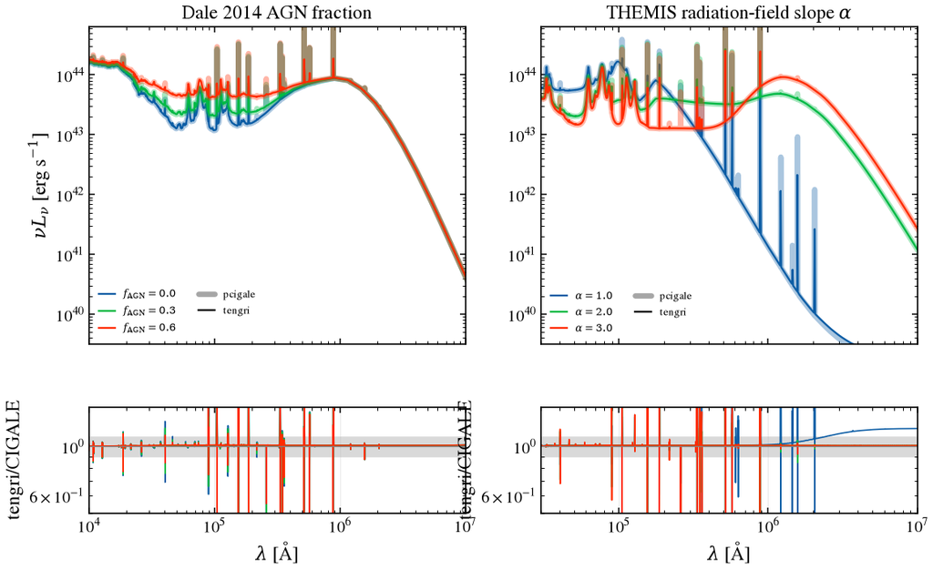

```python
import jax
import jax.numpy as jnp

_c_aa_dust = C_AA

# Matched fiducial chain (mirrors the §6 dale2014 cell): same SFH + BC03 +
# Calzetti attenuation on both sides, so the absorbed luminosity that feeds
# the IR re-emission template is identical. pcigale's normalise=True forms
# 1 M_sun; tengri's log_total_mass=11 forms 1e11 M_sun, so scale the pcigale
# curve by 1e11 to overlay the two at the same stellar mass.
_KNOB_MASS = 1e11
_SFH_CHAIN = (
    "sfhdelayed",
    dict(
        tau_main=1000,
        age_main=5000,
        tau_burst=50,
        age_burst=20,
        f_burst=0.0,
        sfr_A=1.0,
        normalise=True,
    ),
)
_BC03_CHAIN = ("bc03", dict(imf=1, metallicity=0.02, separation_age=10))
_DUSTATT_CHAIN = ("dustatt_modified_starburst", dict(E_BV_lines=0.3))


def _knob_model(emission_type, **emkw):
    """tengri fiducial twin of the matched pcigale chain (1e11 M_sun).

    The attenuation is the notebook's fiducial: a **single** screen
    (``tau_bc = 0``, matching CIGALE's ``dustatt_modified_starburst``, which
    has no Charlot & Fall birth cloud) carrying the Leitherer-extended
    Calzetti curve with the 912 Å clip, i.e. exactly the block §5–§11 use.
    That matters here rather than being housekeeping: the Dale and THEMIS
    templates are normalized to the *absorbed* starlight, so the IR can only
    match to the extent the attenuation does, and a different curve or a
    missing clip would show up as an IR offset with no dust-side cause.
    """
    return SEDModel.build(
        ssp_data=ssp,
        met=MET_FIDUCIAL,
        sfh={
            "type": "delayed",
            "tau_gyr": Fixed(1.0),
            "age_gyr": Fixed(5.0),
            "log_total_mass": Fixed(11.0),
            "all_params": Fixed(DEFAULT),
        },
        dust_attenuation={
            "type": "two_component",
            "law_bc": "leitherer02",
            "law_diff": "leitherer02",
            "tau_bc": Fixed(TAU_BC_FIDUCIAL),
            "tau_diff": Fixed(TAU_DIFF_FIDUCIAL),
            "lyman_cutoff": True,
            "all_params": Fixed(DEFAULT),
        },
        dust_emission={"type": emission_type, "all_params": Fixed(DEFAULT), **emkw},
        neb=NEB_FIDUCIAL_TENGRI, redshift=Fixed(0.0),
    )


def _nu_lnu(wave_aa, l_nu):
    w = np.asarray(wave_aa)
    return w, _c_aa_dust / w * np.asarray(l_nu)


def _band_median(ratio, wave_aa, lo_um, hi_um):
    """Median of ``ratio`` over ``[lo_um, hi_um]`` on the Å grid ``wave_aa``."""
    m = (wave_aa >= lo_um * 1e4) & (wave_aa <= hi_um * 1e4) & np.isfinite(ratio)
    return float(np.median(ratio[m])) if m.any() else float("nan")


fig = plt.figure(figsize=(11, 6.5))
gs = fig.add_gridspec(2, 2, height_ratios=[3, 1], hspace=0.3)
ax_l, ax_r = fig.add_subplot(gs[0, 0]), fig.add_subplot(gs[0, 1])
ax_lr, ax_rr = fig.add_subplot(gs[1, 0]), fig.add_subplot(gs[1, 1])
ax_lr.sharex(ax_l)
ax_rr.sharex(ax_r)

# Where the two codes agree, a thin pcigale line simply disappears under
# tengri's — the panel then reads as though only one code were plotted, which
# is the opposite of the point. Draw pcigale as a thick translucent band and
# tengri as a thin line on top (the convention the AGNFITTER-RX notebook uses):
# agreement shows as a crisp line running down the middle of its own halo, and
# any divergence separates the two immediately.
_REF_KW = dict(lw=4.0, alpha=0.35, solid_capstyle="round")
_TNG_LW = 1.4
_peaks = []
_ratios_l, _ratios_r = [], []

# LEFT — Dale 2014 AGN fraction: pcigale dale2014.fracAGN (band) vs tengri (line).
m_frac = _knob_model("dale2014_cigale", alpha_dale=Fixed(2.0), frac_agn=Uniform(0.0, 0.99, default=0.3))
p_frac = dict(m_frac.spec.sample(jax.random.PRNGKey(0)))
print("§6 knobs — Dale 2014 fracAGN sweep (tengri / CIGALE, median in band):")
for f, c in zip([0.0, 0.3, 0.6], ["C0", "C1", "C3"]):
    sed = C.run_chain(
        [_SFH_CHAIN, _BC03_CHAIN, NEB_FIDUCIAL_CIGALE, _DUSTATT_CHAIN, ("dale2014", dict(alpha=2.0, fracAGN=f))]
    )
    w_c, nl_c = _nu_lnu(*C.to_lnu(sed))
    ax_l.loglog(w_c, nl_c * _KNOB_MASS, color=c, **_REF_KW)
    o = m_frac.predict_rest_sed({**p_frac, "dust_frac_agn": jnp.float64(f)})
    w_t, nl_t = _nu_lnu(o.wavelength, o.sed)
    ax_l.loglog(w_t, nl_t, color=c, lw=_TNG_LW, label=rf"$f_{{\rm AGN}}={f}$")
    _peaks.append(float(np.nanmax(nl_t)))
    _rk = U.regrid(w_t, nl_t, w_c) / np.where(nl_c > 0, nl_c * _KNOB_MASS, np.nan)
    _ratios_l.append((c, w_c, _rk))
    print(
        f"    f_AGN = {f}:  3–8 µm {_band_median(_rk, w_c, 3.0, 8.0):.4f}×"
        f"   8–1000 µm {_band_median(_rk, w_c, 8.0, 1000.0):.4f}×"
    )
ax_l.plot([], [], "k-", **_REF_KW, label="pcigale")
ax_l.plot([], [], "k-", lw=_TNG_LW, label="tengri")
ax_l.set(
    xlim=(1e4, 1e7),
    ylabel=r"$\nu L_\nu$ [erg s$^{-1}$]",
    title="Dale 2014 AGN fraction",
)
ax_l.legend(fontsize=8, frameon=False, ncol=2)
ax_l.tick_params(labelbottom=False)

# RIGHT — THEMIS slope alpha, matched qhac=0.17, umin=1.0, gamma=0.1.
m_alpha = _knob_model("themis", gamma_dl=Fixed(0.1), qhac=Fixed(0.17), alpha=Uniform(1.0, 3.0, default=2.0))
p_alpha = dict(m_alpha.spec.sample(jax.random.PRNGKey(0)))
print("§6 knobs — THEMIS α sweep (tengri / CIGALE, median in band):")
for a, c in zip([1.0, 2.0, 3.0], ["C0", "C1", "C3"]):
    sed = C.run_chain(
        [
            _SFH_CHAIN,
            _BC03_CHAIN,
            NEB_FIDUCIAL_CIGALE,
            _DUSTATT_CHAIN,
            ("themis", dict(qhac=0.17, umin=1.0, gamma=0.1, alpha=a)),
        ]
    )
    w_c, nl_c = _nu_lnu(*C.to_lnu(sed))
    ax_r.loglog(w_c, nl_c * _KNOB_MASS, color=c, **_REF_KW)
    o = m_alpha.predict_rest_sed({**p_alpha, "dust_alpha": jnp.float64(a)})
    w_t, nl_t = _nu_lnu(o.wavelength, o.sed)
    ax_r.loglog(w_t, nl_t, color=c, lw=_TNG_LW, label=rf"$\alpha={a}$")
    _peaks.append(float(np.nanmax(nl_t)))
    _rk = U.regrid(w_t, nl_t, w_c) / np.where(nl_c > 0, nl_c * _KNOB_MASS, np.nan)
    _ratios_r.append((c, w_c, _rk))
    print(
        f"    α = {a}:  8–30 µm {_band_median(_rk, w_c, 8.0, 30.0):.4f}×"
        f"   8–1000 µm {_band_median(_rk, w_c, 8.0, 1000.0):.4f}×"
    )
ax_r.plot([], [], "k-", **_REF_KW, label="pcigale")
ax_r.plot([], [], "k-", lw=_TNG_LW, label="tengri")
ax_r.set(xlim=(3e4, 1e7), title=r"THEMIS radiation-field slope $\alpha$")
ax_r.legend(fontsize=8, frameon=False, ncol=2)
ax_r.tick_params(labelbottom=False)

# Ratio panels
for c, w, ratio in _ratios_l:
    pos = w > 0
    ax_lr.plot(w[pos], ratio[pos], color=c, linewidth=1.0)
ax_lr.axhspan(0.9, 1.1, color="0.85", zorder=0)
ax_lr.axhline(1.0, color="0.5", linewidth=0.8)
ax_lr.set(xlim=(1e4, 1e7), ylim=(0.5, 1.5), yscale="log", xlabel=r"$\lambda$ [Å]", ylabel="tengri/CIGALE")
ax_lr.grid(True, alpha=0.3)

for c, w, ratio in _ratios_r:
    pos = w > 0
    ax_rr.plot(w[pos], ratio[pos], color=c, linewidth=1.0)
ax_rr.axhspan(0.9, 1.1, color="0.85", zorder=0)
ax_rr.axhline(1.0, color="0.5", linewidth=0.8)
ax_rr.set(xlim=(3e4, 1e7), ylim=(0.5, 1.5), yscale="log", xlabel=r"$\lambda$ [Å]", ylabel="tengri/CIGALE")
ax_rr.grid(True, alpha=0.3)

_ypk = max(_peaks)
for ax in (ax_l, ax_r):
    ax.set_ylim(_ypk * 1e-5, _ypk * 2.0)

fig.tight_layout()
save_fig("cigale_06_dust_ir_knobs.png")
plt.show()
```

### §6c IR library sweep

Three more dust-IR template families, on the §6-knobs fiducial (1e11 M☉, single-screen Calzetti attenuation; the §3 energy-anchor offset sits under every ratio). `dl2007` (qpah, umin, γ) at three grid points, cold to warm; `dl2014` at α ∈ {1, 2, 3}; `casey2012` at T ∈ {25, 35, 50} K (β=1.6, α_mir=2.0); `schreiber2016` at T ∈ {25, 35, 50} K; `dale2014` (CIGALE's own grid, via `dale2014_cigale`) at α ∈ {0.5, 2, 4}. One tengri build per family, swept knob(s) free, via `predict_rest_sed`. `IR_BANDS` rows plus the 8–1000 µm L_ν ratio locate each family's shape. Both implementations are normalized on the same absorbed stellar energy (`L_absorbed`), and the 8–1000 µm L_ν ratios printed below lie between 1.009× and 1.021× across the sweep. The filter-by-filter tables show where shapes differ: `dl2014` at α=1 has a worst filter ratio of 1.370× with 7 of 13 bands outside 5%, and every other row has none outside 5% (`f_pah` matches CIGALE's 0.05 default). `schreiber2016` is the tabulated Schreiber et al. (2018) library as CIGALE packages it: per unit dust mass, a dust-continuum and a PAH template at each temperature (the library tabulates 15–99 K; pcigale accepts 15–60 K), mixed by the PAH mass fraction `f_pah` as pcigale does and normalized to the absorbed energy. At T = 25, 35 and 50 K its 8–1000 µm ratio is 1.010× each time, and its filter-by-filter median is 1.009×, 1.009× and 1.010× with worst cases of 1.015×, 1.015× and 1.032×.

```
§6c dl2007 grid (tengri / CIGALE, median in 8-1000 µm band):
```

```
    qpah=0.47 umin=0.1 gamma=0.01: 8-1000 µm 1.0102×
```

```
    qpah=2.5 umin=1 gamma=0.1: 8-1000 µm 1.0102×
```

```
    qpah=4.58 umin=10 gamma=0.5: 8-1000 µm 1.0127×
§6c dl2014 grid (tengri / CIGALE, median in 8-1000 µm band):
```

```
    alpha=1: 8-1000 µm 1.0211×
```

```
    alpha=2: 8-1000 µm 1.0103×
```

```
    alpha=3: 8-1000 µm 1.0103×
```

```
  §6c dl2007 qpah=0.47                                 median 1.010x  worst 1.024x  0/13 outside 5%
  §6c dl2007 qpah=2.5                                  median 1.010x  worst 1.015x  0/13 outside 5%
  §6c dl2007 qpah=4.58                                 median 1.012x  worst 1.039x  0/13 outside 5%
  §6c dl2014 α=1                                       median 1.012x  worst 1.370x  7/13 outside 5%
  §6c dl2014 α=2                                       median 1.010x  worst 1.013x  0/13 outside 5%
  §6c dl2014 α=3                                       median 1.010x  worst 1.018x  0/13 outside 5%
§6c casey2012 T sweep (tengri / CIGALE, median in 8-1000 µm band):
```

```
    T=25 K: 8-1000 µm 1.0095×
```

```
    T=35 K: 8-1000 µm 1.0098×
```

```
    T=50 K: 8-1000 µm 1.0099×
§6c schreiber2016 T sweep (tengri / CIGALE, median in 8-1000 µm band):
```

```
    T=25 K: 8-1000 µm 1.0101×
```

```
    T=35 K: 8-1000 µm 1.0101×
```

```
    T=50 K: 8-1000 µm 1.0102×
§6c dale2014 alpha sweep (tengri / CIGALE, median in 8-1000 µm band):
```

```
    alpha=0.5: 8-1000 µm 1.0100×
```

```
    alpha=2: 8-1000 µm 1.0101×
```

```
    alpha=4: 8-1000 µm 1.0103×
```

```
  §6c casey2012 T=25                                   median 1.009x  worst 1.024x  0/13 outside 5%
  §6c casey2012 T=35                                   median 1.010x  worst 1.022x  0/13 outside 5%
  §6c casey2012 T=50                                   median 1.010x  worst 1.020x  0/13 outside 5%
  §6c schreiber2016 T=25                               median 1.009x  worst 1.015x  0/13 outside 5%
  §6c schreiber2016 T=35                               median 1.009x  worst 1.015x  0/13 outside 5%
  §6c schreiber2016 T=50                               median 1.010x  worst 1.032x  0/13 outside 5%
  §6c dale2014 α=0.5                                   median 1.011x  worst 1.027x  0/13 outside 5%
  §6c dale2014 α=2                                     median 1.010x  worst 1.015x  0/13 outside 5%
  §6c dale2014 α=4                                     median 1.010x  worst 1.014x  0/13 outside 5%
```

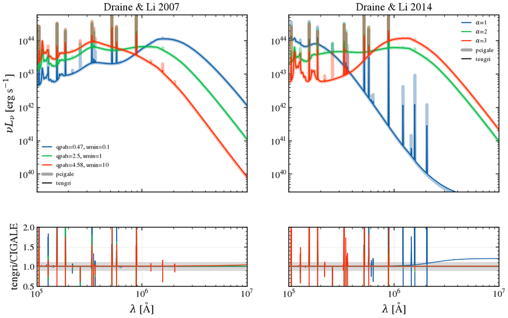

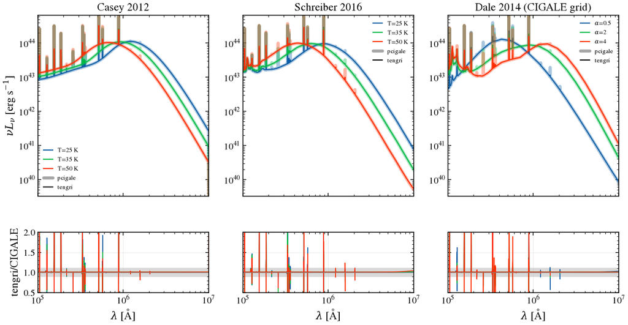

```python
_peaks_6c = []
fig = plt.figure(figsize=(11, 6.5))
gs = fig.add_gridspec(2, 2, height_ratios=[3, 1], hspace=0.3)
ax_l, ax_r = fig.add_subplot(gs[0, 0]), fig.add_subplot(gs[0, 1])
ax_lr, ax_rr = fig.add_subplot(gs[1, 0]), fig.add_subplot(gs[1, 1])
ax_lr.sharex(ax_l)
ax_rr.sharex(ax_r)
ax_rr.sharey(ax_lr)

print("§6c dl2007 grid (tengri / CIGALE, median in 8-1000 µm band):")
m_dl07 = _knob_model(
    "draine_li2007",
    qpah=Uniform(0.1, 10.0, default=2.5),
    umin=Uniform(0.1, 25.0, default=1.0),
    gamma_dl=Uniform(0.0, 1.0, default=0.1),
)
p_dl07 = dict(m_dl07.spec.sample(jax.random.PRNGKey(0)))
_dl07_cases = []
_ratios_6c_l, _ratios_6c_r = [], []
for (_qpah, _umin, _gamma), _c in zip([(0.47, 0.1, 0.01), (2.5, 1.0, 0.1), (4.58, 10.0, 0.5)], ["C0", "C1", "C3"]):
    sed = C.run_chain(
        [_SFH_CHAIN, _BC03_CHAIN, NEB_FIDUCIAL_CIGALE, _DUSTATT_CHAIN, ("dl2007", dict(qpah=_qpah, umin=_umin, gamma=_gamma))]
    )
    _w_c_raw, _L_c_raw = C.to_lnu(sed)
    w_c, nl_c = _nu_lnu(_w_c_raw, _L_c_raw)
    ax_l.loglog(w_c, nl_c * _KNOB_MASS, color=_c, **_REF_KW)
    o = m_dl07.predict_rest_sed(
        {**p_dl07, "dust_qpah": jnp.float64(_qpah), "dust_umin": jnp.float64(_umin), "dust_gamma_dl": jnp.float64(_gamma)}
    )
    w_t, nl_t = _nu_lnu(o.wavelength, o.sed)
    ax_l.loglog(w_t, nl_t, color=_c, lw=_TNG_LW, label=rf"qpah={_qpah:g}, umin={_umin:g}")
    _peaks_6c.append(float(np.nanmax(nl_t)))
    _rk = U.regrid(w_t, nl_t, w_c) / np.where(nl_c > 0, nl_c * _KNOB_MASS, np.nan)
    _ratios_6c_l.append((_c, w_c, _rk))
    print(f"    qpah={_qpah:g} umin={_umin:g} gamma={_gamma:g}: 8-1000 µm {_band_median(_rk, w_c, 8.0, 1000.0):.4f}×")
    _dl07_cases.append(
        (f"dl2007 qpah={_qpah:g}", _w_c_raw, _L_c_raw * _KNOB_MASS, np.asarray(o.wavelength), np.asarray(o.sed))
    )
ax_l.plot([], [], "k-", **_REF_KW, label="pcigale")
ax_l.plot([], [], "k-", lw=_TNG_LW, label="tengri")
ax_l.set(xlim=(1e4, 1e7), ylabel=r"$\nu L_\nu$ [erg s$^{-1}$]", title="Draine & Li 2007")
ax_l.legend(fontsize=8, frameon=False)
ax_l.tick_params(labelbottom=False)

print("§6c dl2014 grid (tengri / CIGALE, median in 8-1000 µm band):")
m_dl14 = _knob_model(
    "draine_li2014",
    qpah=Fixed(2.5),
    umin=Fixed(1.0),
    gamma_dl=Fixed(0.1),
    alpha_dl14=Uniform(1.0, 3.0, default=2.0),
)
p_dl14 = dict(m_dl14.spec.sample(jax.random.PRNGKey(0)))
_dl14_cases = []
for _alpha, _c in zip([1.0, 2.0, 3.0], ["C0", "C1", "C3"]):
    sed = C.run_chain(
        [_SFH_CHAIN, _BC03_CHAIN, NEB_FIDUCIAL_CIGALE, _DUSTATT_CHAIN, ("dl2014", dict(qpah=2.5, umin=1.0, alpha=_alpha, gamma=0.1))]
    )
    _w_c_raw, _L_c_raw = C.to_lnu(sed)
    w_c, nl_c = _nu_lnu(_w_c_raw, _L_c_raw)
    ax_r.loglog(w_c, nl_c * _KNOB_MASS, color=_c, **_REF_KW)
    o = m_dl14.predict_rest_sed({**p_dl14, "dust_alpha_dl14": jnp.float64(_alpha)})
    w_t, nl_t = _nu_lnu(o.wavelength, o.sed)
    ax_r.loglog(w_t, nl_t, color=_c, lw=_TNG_LW, label=rf"$\alpha$={_alpha:g}")
    _peaks_6c.append(float(np.nanmax(nl_t)))
    _rk = U.regrid(w_t, nl_t, w_c) / np.where(nl_c > 0, nl_c * _KNOB_MASS, np.nan)
    _ratios_6c_r.append((_c, w_c, _rk))
    print(f"    alpha={_alpha:g}: 8-1000 µm {_band_median(_rk, w_c, 8.0, 1000.0):.4f}×")
    _dl14_cases.append(
        (f"dl2014 α={_alpha:g}", _w_c_raw, _L_c_raw * _KNOB_MASS, np.asarray(o.wavelength), np.asarray(o.sed))
    )
ax_r.plot([], [], "k-", **_REF_KW, label="pcigale")
ax_r.plot([], [], "k-", lw=_TNG_LW, label="tengri")
ax_r.set(xlim=(1e4, 1e7), title="Draine & Li 2014")
ax_r.legend(fontsize=8, frameon=False)
ax_r.tick_params(labelbottom=False)

_ypk6c = max(_peaks_6c)
for ax in (ax_l, ax_r):
    ax.set_ylim(_ypk6c * 1e-5, _ypk6c * 2.0)

# Ratio panels for dl2007 (restrict to dust-dominated range above 10^5 Å to avoid nebular line spikes)
for c, w, ratio in _ratios_6c_l:
    pos = (w >= 1e5) & (w > 0)
    ax_lr.plot(w[pos], ratio[pos], color=c, linewidth=1.0)
ax_lr.axhspan(0.9, 1.1, color="0.85", zorder=0)
ax_lr.axhline(1.0, color="0.5", linewidth=0.8)
ax_lr.set(xlim=(1e5, 1e7), ylim=(0.5, 2.0), xlabel=r"$\lambda$ [Å]", ylabel="tengri/CIGALE")
ax_lr.grid(True, alpha=0.3)

# Ratio panels for dl2014 (restrict to dust-dominated range above 10^5 Å to avoid nebular line spikes)
for c, w, ratio in _ratios_6c_r:
    pos = (w >= 1e5) & (w > 0)
    ax_rr.plot(w[pos], ratio[pos], color=c, linewidth=1.0)
ax_rr.axhspan(0.9, 1.1, color="0.85", zorder=0)
ax_rr.axhline(1.0, color="0.5", linewidth=0.8)
ax_rr.set(xlim=(1e5, 1e7), ylim=(0.5, 2.0), xlabel=r"$\lambda$ [Å]")
ax_rr.tick_params(labelleft=False)
ax_rr.grid(True, alpha=0.3)

fig.tight_layout()
save_fig("cigale_06c_dl07_dl14.png")

for _name, _cases in (("dl2007", _dl07_cases), ("dl2014", _dl14_cases)):
    for _label, _w_ref, _L_ref, _w_t, _L_t in _cases:
        _rows = V.filter_rows_native(np.asarray(_w_t), np.asarray(_L_t), _w_ref, _L_ref, filters=V.IR_BANDS)
        V.print_filter_table(_rows, ref_name="CIGALE", title=f"§6c {_label}", compact=True)

fig = plt.figure(figsize=(13.5, 6.5))
gs = fig.add_gridspec(2, 3, height_ratios=[3, 1], hspace=0.3)
ax_a, ax_b, ax_c = fig.add_subplot(gs[0, 0]), fig.add_subplot(gs[0, 1]), fig.add_subplot(gs[0, 2])
ax_ar, ax_br, ax_cr = fig.add_subplot(gs[1, 0]), fig.add_subplot(gs[1, 1]), fig.add_subplot(gs[1, 2])
ax_ar.sharex(ax_a)
ax_br.sharex(ax_b)
ax_cr.sharex(ax_c)
ax_br.sharey(ax_ar)
ax_cr.sharey(ax_ar)
_peaks_6d = []

print("§6c casey2012 T sweep (tengri / CIGALE, median in 8-1000 µm band):")
m_cas = _knob_model("casey2012", T=Uniform(10.0, 80.0, default=35.0), beta_ir=Fixed(1.6), alpha_mir=Fixed(2.0))
p_cas = dict(m_cas.spec.sample(jax.random.PRNGKey(0)))
_cas_cases = []
_ratios_6d_a = []
for _T, _c in zip([25.0, 35.0, 50.0], ["C0", "C1", "C3"]):
    sed = C.run_chain([_SFH_CHAIN, _BC03_CHAIN, NEB_FIDUCIAL_CIGALE, _DUSTATT_CHAIN, ("casey2012", dict(temperature=_T, beta=1.6, alpha=2.0))])
    _w_c_raw, _L_c_raw = C.to_lnu(sed)
    w_c, nl_c = _nu_lnu(_w_c_raw, _L_c_raw)
    ax_a.loglog(w_c, nl_c * _KNOB_MASS, color=_c, **_REF_KW)
    o = m_cas.predict_rest_sed({**p_cas, "dust_T": jnp.float64(_T)})
    w_t, nl_t = _nu_lnu(o.wavelength, o.sed)
    ax_a.loglog(w_t, nl_t, color=_c, lw=_TNG_LW, label=rf"T={_T:g} K")
    _peaks_6d.append(float(np.nanmax(nl_t)))
    _rk = U.regrid(w_t, nl_t, w_c) / np.where(nl_c > 0, nl_c * _KNOB_MASS, np.nan)
    _ratios_6d_a.append((_c, w_c, _rk))
    print(f"    T={_T:g} K: 8-1000 µm {_band_median(_rk, w_c, 8.0, 1000.0):.4f}×")
    _cas_cases.append(
        (f"casey2012 T={_T:g}", _w_c_raw, _L_c_raw * _KNOB_MASS, np.asarray(o.wavelength), np.asarray(o.sed))
    )
ax_a.plot([], [], "k-", **_REF_KW, label="pcigale")
ax_a.plot([], [], "k-", lw=_TNG_LW, label="tengri")
ax_a.set(xlim=(1e4, 1e7), ylabel=r"$\nu L_\nu$ [erg s$^{-1}$]", title="Casey 2012")
ax_a.legend(fontsize=8, frameon=False)
ax_a.tick_params(labelbottom=False)

print("§6c schreiber2016 T sweep (tengri / CIGALE, median in 8-1000 µm band):")
m_sch = _knob_model("schreiber2016", T=Uniform(15.0, 60.0, default=30.0))
p_sch = dict(m_sch.spec.sample(jax.random.PRNGKey(0)))
_sch_cases = []
_ratios_6d_b = []
for _T, _c in zip([25.0, 35.0, 50.0], ["C0", "C1", "C3"]):
    sed = C.run_chain([_SFH_CHAIN, _BC03_CHAIN, NEB_FIDUCIAL_CIGALE, _DUSTATT_CHAIN, ("schreiber2016", dict(tdust=_T))])
    _w_c_raw, _L_c_raw = C.to_lnu(sed)
    w_c, nl_c = _nu_lnu(_w_c_raw, _L_c_raw)
    ax_b.loglog(w_c, nl_c * _KNOB_MASS, color=_c, **_REF_KW)
    o = m_sch.predict_rest_sed({**p_sch, "dust_T": jnp.float64(_T)})
    w_t, nl_t = _nu_lnu(o.wavelength, o.sed)
    ax_b.loglog(w_t, nl_t, color=_c, lw=_TNG_LW, label=rf"T={_T:g} K")
    _peaks_6d.append(float(np.nanmax(nl_t)))
    _rk = U.regrid(w_t, nl_t, w_c) / np.where(nl_c > 0, nl_c * _KNOB_MASS, np.nan)
    _ratios_6d_b.append((_c, w_c, _rk))
    print(f"    T={_T:g} K: 8-1000 µm {_band_median(_rk, w_c, 8.0, 1000.0):.4f}×")
    _sch_cases.append(
        (f"schreiber2016 T={_T:g}", _w_c_raw, _L_c_raw * _KNOB_MASS, np.asarray(o.wavelength), np.asarray(o.sed))
    )
ax_b.plot([], [], "k-", **_REF_KW, label="pcigale")
ax_b.plot([], [], "k-", lw=_TNG_LW, label="tengri")
ax_b.set(xlim=(1e4, 1e7), title="Schreiber 2016")
ax_b.legend(fontsize=8, frameon=False)
ax_b.tick_params(labelbottom=False)

print("§6c dale2014 alpha sweep (tengri / CIGALE, median in 8-1000 µm band):")
m_dale = _knob_model("dale2014_cigale", alpha_dale=Uniform(0.0625, 4.0, default=2.0))
p_dale = dict(m_dale.spec.sample(jax.random.PRNGKey(0)))
_dale_cases = []
_ratios_6d_c = []
for _alpha, _c in zip([0.5, 2.0, 4.0], ["C0", "C1", "C3"]):
    sed = C.run_chain([_SFH_CHAIN, _BC03_CHAIN, NEB_FIDUCIAL_CIGALE, _DUSTATT_CHAIN, ("dale2014", dict(alpha=_alpha))])
    _w_c_raw, _L_c_raw = C.to_lnu(sed)
    w_c, nl_c = _nu_lnu(_w_c_raw, _L_c_raw)
    ax_c.loglog(w_c, nl_c * _KNOB_MASS, color=_c, **_REF_KW)
    o = m_dale.predict_rest_sed({**p_dale, "dust_alpha_dale": jnp.float64(_alpha)})
    w_t, nl_t = _nu_lnu(o.wavelength, o.sed)
    ax_c.loglog(w_t, nl_t, color=_c, lw=_TNG_LW, label=rf"$\alpha$={_alpha:g}")
    _peaks_6d.append(float(np.nanmax(nl_t)))
    _rk = U.regrid(w_t, nl_t, w_c) / np.where(nl_c > 0, nl_c * _KNOB_MASS, np.nan)
    _ratios_6d_c.append((_c, w_c, _rk))
    print(f"    alpha={_alpha:g}: 8-1000 µm {_band_median(_rk, w_c, 8.0, 1000.0):.4f}×")
    _dale_cases.append(
        (f"dale2014 α={_alpha:g}", _w_c_raw, _L_c_raw * _KNOB_MASS, np.asarray(o.wavelength), np.asarray(o.sed))
    )
ax_c.plot([], [], "k-", **_REF_KW, label="pcigale")
ax_c.plot([], [], "k-", lw=_TNG_LW, label="tengri")
ax_c.set(xlim=(1e4, 1e7), title="Dale 2014 (CIGALE grid)")
ax_c.legend(fontsize=8, frameon=False)
ax_c.tick_params(labelbottom=False)

_ypk6d = max(_peaks_6d)
for ax in (ax_a, ax_b, ax_c):
    ax.set_ylim(_ypk6d * 1e-5, _ypk6d * 2.0)

# Ratio panels (restrict to dust-dominated range above 10^5 Å to avoid nebular line spikes)
for c, w, ratio in _ratios_6d_a:
    pos = (w >= 1e5) & (w > 0)
    ax_ar.plot(w[pos], ratio[pos], color=c, linewidth=1.0)
ax_ar.axhspan(0.9, 1.1, color="0.85", zorder=0)
ax_ar.axhline(1.0, color="0.5", linewidth=0.8)
ax_ar.set(xlim=(1e5, 1e7), ylim=(0.5, 2.0), xlabel=r"$\lambda$ [Å]", ylabel="tengri/CIGALE")
ax_ar.grid(True, alpha=0.3)

for c, w, ratio in _ratios_6d_b:
    pos = (w >= 1e5) & (w > 0)
    ax_br.plot(w[pos], ratio[pos], color=c, linewidth=1.0)
ax_br.axhspan(0.9, 1.1, color="0.85", zorder=0)
ax_br.axhline(1.0, color="0.5", linewidth=0.8)
ax_br.set(xlim=(1e5, 1e7), ylim=(0.5, 2.0), xlabel=r"$\lambda$ [Å]")
ax_br.tick_params(labelleft=False)
ax_br.grid(True, alpha=0.3)

for c, w, ratio in _ratios_6d_c:
    pos = (w >= 1e5) & (w > 0)
    ax_cr.plot(w[pos], ratio[pos], color=c, linewidth=1.0)
ax_cr.axhspan(0.9, 1.1, color="0.85", zorder=0)
ax_cr.axhline(1.0, color="0.5", linewidth=0.8)
ax_cr.set(xlim=(1e5, 1e7), ylim=(0.5, 2.0), xlabel=r"$\lambda$ [Å]")
ax_cr.tick_params(labelleft=False)
ax_cr.grid(True, alpha=0.3)

fig.tight_layout()
save_fig("cigale_06d_casey_schreiber_dale.png")

for _name, _cases in (("casey2012", _cas_cases), ("schreiber2016", _sch_cases), ("dale2014", _dale_cases)):
    for _label, _w_ref, _L_ref, _w_t, _L_t in _cases:
        _rows = V.filter_rows_native(np.asarray(_w_t), np.asarray(_L_t), _w_ref, _L_ref, filters=V.IR_BANDS)
        V.print_filter_table(_rows, ref_name="CIGALE", title=f"§6c {_label}", compact=True)
```

## §7 Panchromatic SED

**Far-UV (λ < 912 Å).** Calzetti+2000 was fit on 1200–22000 Å; tengri's polynomial extrapolates below that, while CIGALE's `dustatt_modified_starburst` drops to zero at 912 Å. Setting `dust_attenuation={'lyman_cutoff': True}` applies the same 912 Å clip on both sides.

```
§7 panchromatic median ratio (tengri / CIGALE):
    200–912 Å (LyC) : tengri's grid does not reach this band (3 CIGALE points)
    912–1200 Å      : 1.0599×  (29/29 points where both grids carry a model)
    1200–3000 Å     : 1.0620×  (423/423 points where both grids carry a model)
    0.3–1 µm        : 1.0038×  (932/932 points where both grids carry a model)
    3–8 µm          : 1.0075×  (340/340 points where both grids carry a model)
    10–100 µm       : 1.0102×  (448/448 points where both grids carry a model)
    100–1000 µm     : 1.0102×  (375/375 points where both grids carry a model)
```

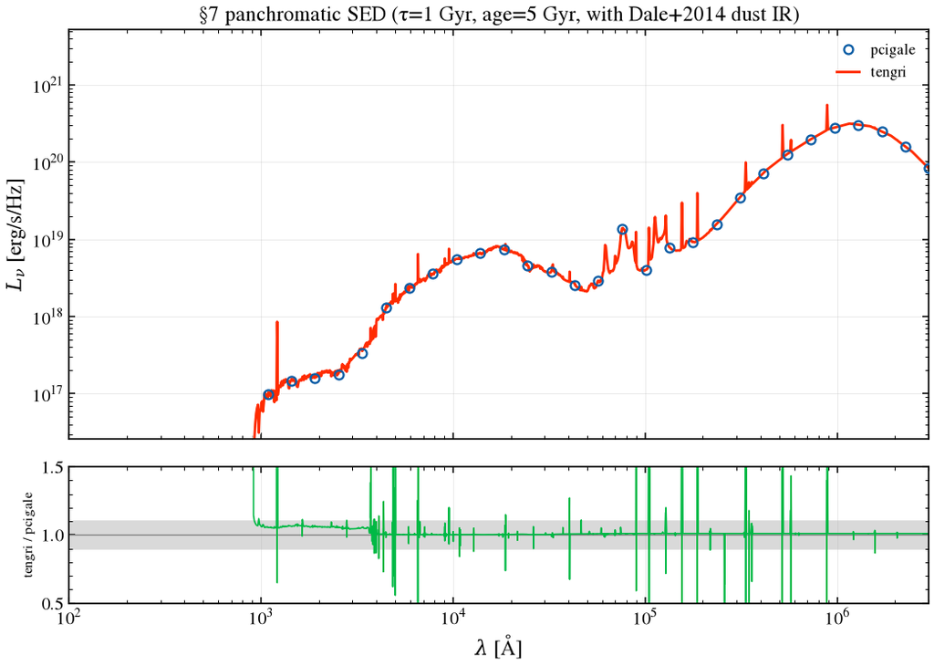

```python
# Two panels on independent y-axes read as agreement whatever they contain,
# so the band-by-band ratio is printed beside them. The §6 model, seen from
# the Lyman continuum to the submillimeter.
_L_t_pan = U.regrid(np.asarray(s_ir.wave), np.asarray(s_ir.sed_intrinsic), w_c_ir)
# ``regrid`` zero-fills outside tengri's grid, and a zero divided by CIGALE's
# model is a ratio of 0.000 that reads as total disagreement rather than as
# "the model stops here". Count the points where *both* codes carry a model
# and say so, so the mm tail is reported as missing coverage and not as a
# residual.
_L_c_ir_floor = 1e-6 * L_c_ir.max()
_cov_pan = (L_c_ir > _L_c_ir_floor) & (_L_t_pan > 0)
_r_pan = np.where(_cov_pan, _L_t_pan / np.where(_cov_pan, L_c_ir, 1.0), np.nan)
print("§7 panchromatic median ratio (tengri / CIGALE):")
for _lo, _hi, _wname in (
    (200.0, 912.0, "200–912 Å (LyC) "),
    (912.0, 1200.0, "912–1200 Å      "),
    (1200.0, 3000.0, "1200–3000 Å     "),
    (3000.0, 10000.0, "0.3–1 µm        "),
    (3.0e4, 8.0e4, "3–8 µm          "),
    (1.0e5, 1.0e6, "10–100 µm       "),
    (1.0e6, 1.0e7, "100–1000 µm     "),
):
    _band = (w_c_ir >= _lo) & (w_c_ir <= _hi)
    _n_c = int((_band & (L_c_ir > 0)).sum())
    _n_both = int((_band & _cov_pan).sum())
    if _n_both:
        print(
            f"    {_wname}: {float(np.nanmedian(_r_pan[_band])):.4f}×  "
            f"({_n_both}/{_n_c} points where both grids carry a model)"
        )
    else:
        print(f"    {_wname}: tengri's grid does not reach this band ({_n_c} CIGALE points)")

fig, ax, ax_r, ratio = V.overlay_ratio_fig(
    w_c_ir,
    L_c_ir,
    np.asarray(s_ir.wave),
    np.asarray(s_ir.sed_intrinsic),
    xlabel=r"$\lambda$ [Å]",
    title="§7 panchromatic SED (τ=1 Gyr, age=5 Gyr, with Dale+2014 dust IR)",
    ref_label="pcigale",
    label_t="tengri",
    xlim=(1e2, 3e6),
)
ax.set_ylabel(r"$L_\nu$ [erg/s/Hz]")
fig.tight_layout()
fig.savefig(str(figs_dir / "cigale_07_panchromatic_full.png"), dpi=150, bbox_inches="tight")
plt.show()
```

## §8 Nebular emission

CIGALE uses static CLOUDY grids (`pcigale.sed_modules.nebular`). tengri uses **Cue** (Li et al. 2025), a neural emulator of the same physics that exposes logU, gas metallicity and IMF as continuous parameters. Cue requires the bare-stellar SSP this notebook loaded.

**Fiducial choice: young population.** Sections §3–§7 use a 5 Gyr quiescent τ=1 Gyr galaxy (Boquien+2019 reference), which has almost no ionizing budget. Nebular emission lives in stars ≲ 100 Myr old, so §8 swaps to a **τ=300 Myr, age=100 Myr** delayed SFH where Hα and the metal-line forest are physically strong. Only the SFH changes.

The two emitters see the same H II region: `logU = −2.0`, Z_gas = 0.02 (Cue's `neb_logZ_gas` pinned to `log10(0.02/Z_⊙) ≈ +0.149`, the same absolute metallicity as CIGALE's `zgas = 0.02` and as the stars on both sides), `f_esc = 0`, `n_H = 100 cm⁻³` (`gas_logn = 2.0`), solar N/O and C/O (`gas_logno = gas_logco = 0`). The Q_H reaching Cue is the integral of the SSP-convolved ionizing spectrum below 911.76 Å, published by the stellar component on every forward pass.

**Read the ionizing budget before the line ratios.** Every line scales with the Q_H handed to the emitter, so the cell prints Q_H first: CIGALE's `stellar.n_ly` against tengri's `nion`, on the shared BC03 grid and on the dense FSPS grid the lines are measured on. Two known terms enter it. On the shared grid it is §3's age-binning convention alone. On the dense grid the SSP swap adds to it as well, a deliberate choice, and the reason for it follows below.

**What is left after that is the emitter.** Cue was trained on Cloudy 22.00 (Li et al. 2025, ApJ 986, 9, arXiv:2405.04598) while CIGALE evaluates its own bundled Cloudy grids, and Cue's bare-stellar path differs from CIGALE's wNE-SSP convolution. The printed line ratios divide out neither term, so they are an upper bound on the emitter difference rather than a measurement of it, and they do not move together: the recombination lines and [O III] behave differently, which is what a line-physics or abundance difference looks like and not what a uniform normalization offset looks like. Closing this properly needs tengri's own static grid at matched Q_H (`neb={'type': 'cloudy'}`, below), a Cloudy-against-Cloudy comparison; this notebook does not run it.

Each line is quantified with the **integrated** luminosity (continuum-subtracted, width-independent), not a single-bin peak ratio, which would measure line width and grid resolution (CIGALE broadens to `lines_width = 300 km/s`) rather than physics.

**Verification Status:** PARTIAL (1/10): Cue nebular emulator

```python
# §8 young fiducial: τ=300 Myr, age=100 Myr — Hα-bright. CIGALE accepts
# Myr values directly; tengri takes Gyr via tau_gyr/age_gyr.
_TAU_MAIN_YOUNG_MYR = 300
_AGE_MAIN_YOUNG_MYR = 100
_sfh_args = (
    "sfhdelayed",
    dict(
        tau_main=_TAU_MAIN_YOUNG_MYR,
        age_main=_AGE_MAIN_YOUNG_MYR,
        tau_burst=50,
        age_burst=20,
        f_burst=0.0,
        sfr_A=1.0,
        normalise=True,
    ),
)
sed_c_st = C.run_chain(
    [
        _sfh_args,
        ("bc03", dict(imf=1, metallicity=0.02, separation_age=10)),
    ]
)
w_c_st, L_c_st = C.to_lnu(sed_c_st)

sed_c_neb = C.run_chain(
    [
        _sfh_args,
        ("bc03", dict(imf=1, metallicity=0.02, separation_age=10)),
        (
            "nebular",
            dict(
                logU=-2.0,
                zgas=0.02,
                ne=100,
                f_esc=0.0,
                f_dust=0.0,
                lines_width=300.0,
                emission=True,
                line_list="",
            ),
        ),
    ]
)
w_c_neb, L_c_neb = C.to_lnu(sed_c_neb)

_neb_sfh_kw = {
    "type": "delayed",
    "tau_gyr": Fixed(_TAU_MAIN_YOUNG_MYR / 1000),
    "age_gyr": Fixed(_AGE_MAIN_YOUNG_MYR / 1000),
    "log_total_mass": Fixed(0.0),
    "all_params": Fixed(DEFAULT),
}

m_neb = SEDModel.build(
    ssp_data=ssp,
    met=MET_FIDUCIAL,
    sfh=_neb_sfh_kw,
    neb=NEB_FIDUCIAL_TENGRI,  # ionspec_* slopes stay at their SSP-derived Fixed values
    dust_attenuation={
        "law": "power_law",
        "type": "two_component",
        "tau_bc": Fixed(0.0),
        "tau_diff": Fixed(0.0),
        "all_params": Fixed(DEFAULT),
    },
    redshift=Fixed(0.0),
)
s_neb = m_neb.predict_state({})

fig, ax_l, ax_r = U.two_panel_fig()
U.panel(ax_l, ax_r, label_l="pcigale  CLOUDY nebular", label_r="tengri  Cue nebular (Li+2024)")
# CIGALE side — dashed stellar + solid (stellar+nebular) + dotted
# nebular-only (the line forest + smooth continuum that CLOUDY adds).
L_c_neb_only = np.maximum(L_c_neb - U.regrid(w_c_st, L_c_st, w_c_neb), 1e-30)
ax_l.plot(w_c_st, L_c_st, "k--", linewidth=1.0, alpha=0.5, label="stellar only")
ax_l.plot(w_c_neb, L_c_neb, "C0-", linewidth=1.4, alpha=0.7, label="stellar + CLOUDY nebular")
ax_l.plot(w_c_neb, L_c_neb_only, "C0:", linewidth=1.4, label="CLOUDY nebular only")
ax_l.legend(fontsize=8)
# tengri side — same three traces (stellar dashed, stellar+Cue solid,
# Cue-only dotted). Agreement is limited by the two emitters' Cloudy
# models (Cue: Cloudy 22.00), bare-stellar vs wNE-SSP path, and line-broadening kernel;
# see the integrated-line-luminosity ratio printed below.
# ``derived["sed_nebular"]`` publishes the photoionized continuum + lines
# directly, so the stellar-only trace is read off the same nebular-on build
# by subtracting it back out -- no separate stellar-only model needed (every
# build on this page carries the nebular fiducial; see Setup).
L_t_neb_only = np.maximum(np.asarray(s_neb.derived["sed_nebular"]), 1e-30)
_s_stellar_on_neb = np.maximum(np.asarray(s_neb.sed_intrinsic) - L_t_neb_only, 1e-30)
ax_r.plot(
    s_neb.wave, _s_stellar_on_neb, "k--", linewidth=1.0, alpha=0.5, label="stellar only"
)
ax_r.plot(s_neb.wave, s_neb.sed_intrinsic, "C1-", linewidth=1.4, alpha=0.7, label="stellar + Cue")
ax_r.plot(s_neb.wave, L_t_neb_only, "C1:", linewidth=1.4, label="Cue nebular only")
ax_r.legend(fontsize=8)
_xmin_n = float(min(w_c_neb.min(), float(np.asarray(s_neb.wave).min())))
_xmax_n = float(max(w_c_neb.max(), float(np.asarray(s_neb.wave).max())))
_ymax_n = max(float(L_c_neb.max()), float(np.asarray(s_neb.sed_intrinsic).max()))
for ax in (ax_l, ax_r):
    ax.set_xlim(_xmin_n, _xmax_n)
    ax.set_ylim(_ymax_n * 1e-6, _ymax_n * 2)
    ax.grid(True, alpha=0.3)
fig.tight_layout()
plt.close(fig)  # superseded by §8b's logU x Z_gas x f_esc grid, which replaces this panel

# Quantify the residual by integrated line luminosity (width- and grid-
# independent). A single-bin peak ratio measures line width, not luminosity —
# CIGALE broadens its lines (lines_width=300 km/s) while Cue applies its own.
#
# CIGALE's native BC03 grid (repackaged unchanged into `bc03_from_cigale.h5`) is
# non-uniform and only ~20 Å in the optical — that is CIGALE's own spectral
# resolution, not a repackaging artifact, and it cannot resolve an emission line (a
# ±12 Å window holds a single grid point). So the integrated measure is taken on
# the dense FSPS MIST+MILES bare-stellar SSP that Cue was validated on (the same
# SSP swap the ProSpect notebook §8 makes, and for the same reason). The CIGALE
# reference stays CLOUDY-on-BC03.
_ssp_neb_dense = load_ssp_data(
    str(tengri.download_ssp("fsps_mist_miles_chabrier", dest=str(_HERE / "_drivers" / "data")))
)
_m_neb_dense = SEDModel.build(
    ssp_data=_ssp_neb_dense,
    # CIGALE runs this section at Z = 0.02 for both the stars (bc03
    # metallicity=0.02) and the gas (nebular zgas=0.02). Pin both sides of
    # the dense-SSP twin to the same absolute metallicity — a bare
    # ``logzsol = 0.0`` here would be Z = 0.0142, a 0.15 dex mismatch on top
    # of the disclosed SSP swap, and it moves the metal lines much more than
    # the recombination lines.
    met=MET_FIDUCIAL,
    sfh=_neb_sfh_kw,
    neb=NEB_FIDUCIAL_TENGRI,
    dust_attenuation={
        "law": "power_law",
        "type": "two_component",
        "tau_bc": Fixed(0.0),
        "tau_diff": Fixed(0.0),
        "all_params": Fixed(DEFAULT),
    },
    redshift=Fixed(0.0),
)
_s_neb_dense = _m_neb_dense.predict_state({})
_w_t_dense = np.asarray(_s_neb_dense.wave)
_L_t_dense = np.asarray(_s_neb_dense.derived["sed_nebular"])

# The ionizing budget first. Every line scales with the Q_H handed to the
# emitter, so a line ratio read without it cannot separate "different line
# physics" from "different number of ionizing photons". CIGALE publishes it
# as ``stellar.n_ly``; tengri as ``derived["nion"]``. Both sides form 1 M☉,
# so the two are directly comparable.
_n_ly_c = float(sed_c_neb.info["stellar.n_ly"])
print("§8 ionizing photon rate Q_H reaching the emitter [ph/s per M☉ formed]:")
print(f"    CIGALE  stellar.n_ly on BC03      {_n_ly_c:.4e}")
for _label, _st in (
    ("tengri  shared BC03 SSP          ", s_neb),
    ("tengri  dense FSPS MIST+MILES    ", _s_neb_dense),
):
    _qh = float(np.asarray(_st.derived["nion"]))
    print(f"    {_label}{_qh:.4e}  → {_qh / _n_ly_c:.3f}×")

print("§8 integrated line luminosity (tengri Cue / CIGALE CLOUDY; tengri on dense FSPS SSP):")
for _c, _name in [(6563.0, "Hα"), (5007.0, "[O III]"), (4861.0, "Hβ")]:
    _lc = U.line_lum(w_c_neb, L_c_neb_only, _c)
    _lt = U.line_lum(_w_t_dense, _L_t_dense, _c)
    if _lc > 0:
        print(
            f"    {_name} {_c:.0f} Å: CIGALE {_lc:.2e}, tengri {_lt:.2e} erg/s → {_lt / _lc:.2f}×"
        )
    else:
        # Not skipped silently: an empty CIGALE window is a grid-resolution
        # failure of the measurement, not an absent line.
        print(f"    {_name} {_c:.0f} Å: CIGALE window holds < 2 grid points — not measurable here")
```

```
SSP file already exists at fsps_mist_miles_chabrier.h5; skipping download.
```

```
§8 ionizing photon rate Q_H reaching the emitter [ph/s per M☉ formed]:
    CIGALE  stellar.n_ly on BC03      2.5888e+45
    tengri  shared BC03 SSP          2.9629e+45  → 1.145×
    tengri  dense FSPS MIST+MILES    3.5669e+45  → 1.378×
§8 integrated line luminosity (tengri Cue / CIGALE CLOUDY; tengri on dense FSPS SSP):
    Hα 6563 Å: CIGALE 3.68e+33, tengri 4.98e+33 erg/s → 1.35×
    [O III] 5007 Å: CIGALE 2.42e+33, tengri 1.14e+33 erg/s → 0.47×
    Hβ 4861 Å: CIGALE 1.29e+33, tengri 1.72e+33 erg/s → 1.33×
```

### §8b logU × Z_gas × f_esc

Same young fiducial and dense FSPS SSP as above. logU ∈ {−3, −2, −1.5} at Z_gas = 0.02; Z_gas ∈ {0.004, 0.02, 0.041} (CIGALE's nearest grid point to 0.04) at logU = −2; f_esc ∈ {0, 0.5} at the logU/Z_gas fiducial (7 cases). One tengri build with `neb_logU`, `neb_logZ_gas`, `neb_fesc` free, evaluated per case via `predict_state`; one CIGALE `nebular` call per case. Rows: Hα/Hβ, [O III]/Hβ, [O II]/Hβ, tengri and CIGALE side by side; a residual here is Cue versus CLOUDY (§8), not a parity check. The cell closes with the largest tengri/CIGALE ratio-of-ratios per line over the seven cases. The [O III]/Hβ and [O II]/Hβ ratios are an open difference: across logU = −3 to −1.5 CIGALE's [O III]/Hβ rises from 0.559 to 2.307 while Cue's stays between 0.603 and 0.665, and Cue's [O II]/Hβ is larger than CIGALE's at every case printed.

```
§8b logU × Z_gas × f_esc (7 cases) — Ha/Hb, [OIII]/Hb, [OII]/Hb, tengri vs CIGALE:
```

```
    logU=-3        tengri Ha/Hb 2.935, [OIII]/Hb 0.603, [OII]/Hb 2.010  |  CIGALE Ha/Hb 2.857, [OIII]/Hb 0.559, [OII]/Hb 0.627
```

```
    logU=-2 (fid)  tengri Ha/Hb 2.900, [OIII]/Hb 0.665, [OII]/Hb 0.908  |  CIGALE Ha/Hb 2.848, [OIII]/Hb 1.869, [OII]/Hb 0.321
    logU=-1.5      tengri Ha/Hb 2.895, [OIII]/Hb 0.645, [OII]/Hb 0.745  |  CIGALE Ha/Hb 2.845, [OIII]/Hb 2.307, [OII]/Hb 0.148
```

```
    Zgas=0.004     tengri Ha/Hb 2.806, [OIII]/Hb 3.519, [OII]/Hb 1.419  |  CIGALE Ha/Hb 2.766, [OIII]/Hb 8.036, [OII]/Hb 0.681
```

```
    Zgas=0.041     tengri Ha/Hb 2.974, [OIII]/Hb 0.025, [OII]/Hb 0.478  |  CIGALE Ha/Hb 2.985, [OIII]/Hb 0.006, [OII]/Hb 0.011
    fesc=0         tengri Ha/Hb 2.900, [OIII]/Hb 0.665, [OII]/Hb 0.908  |  CIGALE Ha/Hb 2.848, [OIII]/Hb 1.869, [OII]/Hb 0.321
```

```
    fesc=0.5       tengri Ha/Hb 2.900, [OIII]/Hb 0.665, [OII]/Hb 0.908  |  CIGALE Ha/Hb 2.838, [OIII]/Hb 1.864, [OII]/Hb 0.323
§8b Ha/Hb: largest tengri/CIGALE ratio-of-ratios 1.03× at logU=-3
§8b [OIII]/Hb: largest tengri/CIGALE ratio-of-ratios 3.96× at Zgas=0.041
§8b [OII]/Hb: largest tengri/CIGALE ratio-of-ratios 44.75× at Zgas=0.041
```

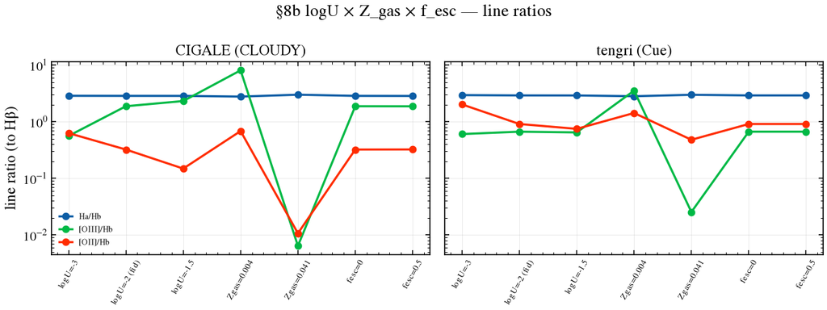

```python
_m_8b = SEDModel.build(
    ssp_data=_ssp_neb_dense,
    met=MET_FIDUCIAL,
    sfh=_neb_sfh_kw,
    neb={
        "type": "cue",
        "neb_logU": Uniform(-4.0, -1.0, default=-2.0),
        "neb_logZ_gas": Uniform(-1.0, 0.5, default=MET_LOGZSOL),
        "neb_fesc": Uniform(0.0, 1.0, default=0.0),
        "all_params": Fixed(DEFAULT),
    },
    dust_attenuation={
        "law": "power_law",
        "type": "two_component",
        "tau_bc": Fixed(0.0),
        "tau_diff": Fixed(0.0),
        "all_params": Fixed(DEFAULT),
    },
    redshift=Fixed(0.0),
)
_p_8b = dict(_m_8b.spec.sample(jax.random.PRNGKey(0)))

_8b_grid = [
    ("logU=-3", -3.0, 0.02, 0.0),
    ("logU=-2 (fid)", -2.0, 0.02, 0.0),
    ("logU=-1.5", -1.5, 0.02, 0.0),
    ("Zgas=0.004", -2.0, 0.004, 0.0),
    ("Zgas=0.041", -2.0, 0.041, 0.0),
    ("fesc=0", -2.0, 0.02, 0.0),
    ("fesc=0.5", -2.0, 0.02, 0.5),
]
_LINE_RATIOS_8B = (("Ha/Hb", 6563.0, 4861.0), ("[OIII]/Hb", 5007.0, 4861.0), ("[OII]/Hb", 3728.0, 4861.0))

_rt_8b_all, _rc_8b_all = [], []
print("§8b logU × Z_gas × f_esc (7 cases) — Ha/Hb, [OIII]/Hb, [OII]/Hb, tengri vs CIGALE:")
for _label, _logU, _zgas, _fesc in _8b_grid:
    _sed_c8b = C.run_chain(
        [
            _sfh_args,
            ("bc03", dict(imf=1, metallicity=0.02, separation_age=10)),
            (
                "nebular",
                dict(
                    logU=_logU, zgas=_zgas, ne=100, f_esc=_fesc, f_dust=0.0,
                    lines_width=300.0, emission=True, line_list="",
                ),
            ),
        ]
    )
    _w_c8b, _L_c8b_full = C.to_lnu(_sed_c8b)
    _L_c8b_st = U.regrid(w_c_st, L_c_st, _w_c8b)
    _L_c8b_neb = np.maximum(_L_c8b_full - _L_c8b_st, 1e-30)

    _logzgas_8b = float(np.log10(_zgas) - LOG10_ZSUN)
    _st_8b = _m_8b.predict_state(
        {
            **_p_8b,
            "neb_logU": jnp.float64(_logU),
            "neb_logZ_gas": jnp.float64(_logzgas_8b),
            "neb_fesc": jnp.float64(_fesc),
        }
    )
    _w_t8b = np.asarray(_st_8b.wave)
    _L_t8b_neb = np.asarray(_st_8b.derived["sed_nebular"])

    _rt, _rc = {}, {}
    for _name, _num, _den in _LINE_RATIOS_8B:
        _lt_n, _lt_d = U.line_lum(_w_t8b, _L_t8b_neb, _num), U.line_lum(_w_t8b, _L_t8b_neb, _den)
        _lc_n, _lc_d = U.line_lum(_w_c8b, _L_c8b_neb, _num), U.line_lum(_w_c8b, _L_c8b_neb, _den)
        _rt[_name] = _lt_n / _lt_d if _lt_d > 0 else float("nan")
        _rc[_name] = _lc_n / _lc_d if _lc_d > 0 else float("nan")
    print(
        f"    {_label:<14} tengri Ha/Hb {_rt['Ha/Hb']:.3f}, [OIII]/Hb {_rt['[OIII]/Hb']:.3f}, "
        f"[OII]/Hb {_rt['[OII]/Hb']:.3f}  |  CIGALE Ha/Hb {_rc['Ha/Hb']:.3f}, "
        f"[OIII]/Hb {_rc['[OIII]/Hb']:.3f}, [OII]/Hb {_rc['[OII]/Hb']:.3f}"
    )
    _rt_8b_all.append(_rt)
    _rc_8b_all.append(_rc)

for _name, _, _ in _LINE_RATIOS_8B:
    _rr = [_t[_name] / _c[_name] for _t, _c in zip(_rt_8b_all, _rc_8b_all)]
    _j = int(np.argmax(np.abs(np.log(_rr))))
    print(f"§8b {_name}: largest tengri/CIGALE ratio-of-ratios {_rr[_j]:.2f}× at {_8b_grid[_j][0]}")

fig, (ax_l, ax_r) = plt.subplots(1, 2, figsize=(11, 4.2), sharey=True)
_x_8b = np.arange(len(_8b_grid))
for _ax, _rows, _title in ((ax_l, _rc_8b_all, "CIGALE (CLOUDY)"), (ax_r, _rt_8b_all, "tengri (Cue)")):
    for _name, _color in zip(("Ha/Hb", "[OIII]/Hb", "[OII]/Hb"), ("C0", "C1", "C3")):
        _ax.plot(_x_8b, [r[_name] for r in _rows], "o-", color=_color, label=_name)
    _ax.set_xticks(_x_8b)
    _ax.set_xticklabels([g[0] for g in _8b_grid], rotation=60, fontsize=8)
    _ax.set_title(_title)
    _ax.set_yscale("log")
    _ax.grid(True, alpha=0.3)
ax_l.set_ylabel("line ratio (to Hβ)")
ax_l.legend(fontsize=8)
fig.suptitle("§8b logU × Z_gas × f_esc — line ratios")
fig.tight_layout()
save_fig("cigale_08b_neb_grid.png")
```

## §9 AGN

CIGALE module `skirtor2016` ↔ tengri `agn={"type": "composable", "disc": schartmann2005, "torus": skirtor, "atten": polar_dust}` at the SKIRTOR fiducial (i = 30°, τ_9.7 = 7, oa = 40°, p = q = 1). The figure overlays the stellar + dust + AGN SEDs of the two codes; §9c prints the disc, torus and polar-dust luminosities separately.

**Disc.** `disc.schartmann2005` matches CIGALE's `skirtor2016 disk_type=1` default: the Schartmann (2005) piecewise power law with the 1200 Å bend that CIGALE substitutes for the FITS-bundled disc. tengri also ships `disc.skirtor` (CIGALE `disk_type=0`, §9b) and `disc.adaf_lopez2024` (`disk_type=2`). For a differentiable (M_BH, ṁ, spin) disc use `disc={"type": "multicolor", ...}`; its UV continuum differs from CIGALE's, so this notebook uses `disc.schartmann2005`.

**Three components, and all three have to be selected.** CIGALE's `skirtor2016` emits a disc, a torus and a Casey-2012 polar-dust graybody, and publishes them separately. tengri's composable AGN has the same three, but the polar graybody is a standalone `atten` block, and `derived["sed_agn_polar"]` is a zeros array whenever the block is not selected. The build names all three at CIGALE's defaults (`oa = 40°`, τ_9.7 = 7, p = q = 1, i = 30°, `agn_polar_ebv = 0.03`, T = 100 K, β = 1.6).

**Inclination and polar cone.** `agn_cos_inc` is the one inclination of every torus (cos 30° here). The polar cone shares the opening angle of the selected torus (`agn_oa_skirtor`), so the cone's share of the disc follows the torus geometry.

**Polar-dust extinction law.** CIGALE's `law=0` is the Bongiorno et al. (2012) power law `k = 1.39 (λ/µm)^−1.2` above 100 nm, with the SMC-bar shape of Weingartner & Draine (2001) below it. tengri's `polar_law="bongiorno"` is that curve and is what the builds here use. tengri's default, `polar_law="smc"` (Pei 1992), is a different curve; §9d prints how far apart they are.

**The polar component is disc-shaped by construction.** Both codes set its luminosity from `g(oa) × ∫ disc(1 − e^−τ_polar) dλ`, the disc's own spectrum seen through the polar screen, so it moves with the disc's UV shape even at fixed `oa`, `agn_polar_ebv`, T and β. §9c and §9b print each code's polar share of its own AGN dust budget beside the component ratios: pcigale's share moves between its two disc types, and tengri's moves with it.

**Energy-balance normalization.** CIGALE ties disc, torus and polar dust to a single `agn_power` reference through the fixed SKIRTOR template ratios. tengri's default `agn_norm='cigale_joint'` does the same: the tie normalizes the disc only (a corona, when the disc block carries one, rides on top; the Schartmann disc has none), with the disc set to `agn_power × R`, where `R = η(i)·∫disc/∫dust` and `η(i) = cos i (1+2cos i)/3` is the Stalevski+2016 anisotropy factor. With `agn_ir_frac` set, `agn_power` is derived from `L_absorbed × f/(1−f)`, as CIGALE derives it from `fracAGN`, so §6's energy anchor enters the AGN normalization too. `agn_log_lbol`, the angle-integrated accretion power, is then not a free input: setting both is two statements of one power, and the build refuses it. Use `agn_norm='independent'` and `agn_log_lbol` for a model with no `agn_ir_frac`.

**Verification Status:** CROSSVAL: SKIRTOR torus (mean 3-param)

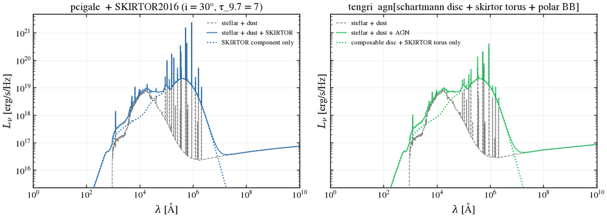

```python
# CIGALE's polar dust (`law=0`, E(B-V) = 0.03) is tengri's `polar_dust` block with
# `polar_law="bongiorno"`; the default `polar_law="smc"` is Pei (1992), a
# different curve (§9d prints the difference).
_POLAR_DUST_BLOCK = {
    "type": "polar_dust",
    "polar_law": "bongiorno",
    "agn_polar_ebv": Fixed(0.03),
    "all_params": Fixed(DEFAULT),
}
_sfh_args_d = (
    "sfhdelayed",
    dict(
        tau_main=1000,
        age_main=5000,
        tau_burst=50,
        age_burst=20,
        f_burst=0.0,
        sfr_A=1.0,
        normalise=True,
    ),
)
sed_c_base = C.run_chain(
    [
        _sfh_args_d,
        ("bc03", dict(imf=1, metallicity=0.02, separation_age=10)),
        NEB_FIDUCIAL_CIGALE,
        ("dustatt_modified_starburst", dict(E_BV_lines=0.3)),
    ]
)
w_base, L_base = C.to_lnu(sed_c_base)

m_agn_base = SEDModel.build(
    ssp_data=ssp,
    met=MET_FIDUCIAL,
    sfh={
        "type": "delayed",
        "tau_gyr": Fixed(1.0),
        "age_gyr": Fixed(5.0),
        "log_total_mass": Fixed(0.0),
        "all_params": Fixed(DEFAULT),
    },
    dust_attenuation={
        "type": "two_component",
        "law_bc": "leitherer02",
        "law_diff": "leitherer02",
        "tau_bc": Fixed(TAU_BC_FIDUCIAL),
        "tau_diff": Fixed(TAU_DIFF_FIDUCIAL),
        # Match CIGALE's dustatt_modified_starburst, which drops to zero at the
        # Lyman limit; §7/§11 do the same. Without it the Calzetti/Leitherer
        # polynomial extrapolates below 912 Å and the stellar+dust baseline
        # sits above CIGALE in the far-UV, muddying the AGN comparison.
        "lyman_cutoff": True,
        "all_params": Fixed(DEFAULT),
    },
    neb=NEB_FIDUCIAL_TENGRI, redshift=Fixed(0.0),
)
s_agn_base = m_agn_base.predict_state({})

# Full SED with and without AGN on both sides — clearer than the
# differential plot when one side has X-ray + the other doesn't.
sed_skirtor = C.run_chain(
    [
        _sfh_args_d,
        ("bc03", dict(imf=1, metallicity=0.02, separation_age=10)),
        NEB_FIDUCIAL_CIGALE,
        ("dustatt_modified_starburst", dict(E_BV_lines=0.3)),
        (
            "skirtor2016",
            dict(
                t=7,
                pl=1.0,
                q=1.0,
                oa=40,
                R=20,
                Mcl=0.97,
                i=30,
                disk_type=1,
                delta=0,
                fracAGN=0.3,
                lambda_fracAGN="0/0",
                law=0,
                EBV=0.03,
                temperature=100.0,
                emissivity=1.6,
            ),
        ),
    ]
)
w_skirt, L_skirt = C.to_lnu(sed_skirtor)

m_agn = SEDModel.build(
    ssp_data=ssp,
    met=MET_FIDUCIAL,
    sfh={
        "type": "delayed",
        "tau_gyr": Fixed(1.0),
        "age_gyr": Fixed(5.0),
        "log_total_mass": Fixed(0.0),
        "all_params": Fixed(DEFAULT),
    },
    dust_attenuation={
        "type": "two_component",
        "law_bc": "leitherer02",
        "law_diff": "leitherer02",
        "tau_bc": Fixed(TAU_BC_FIDUCIAL),
        "tau_diff": Fixed(TAU_DIFF_FIDUCIAL),
        # Match CIGALE's dustatt_modified_starburst, which drops to zero at the
        # Lyman limit; §7/§11 do the same. Without it the Calzetti/Leitherer
        # polynomial extrapolates below 912 Å and the stellar+dust baseline
        # sits above CIGALE in the far-UV, muddying the AGN comparison.
        "lyman_cutoff": True,
        "all_params": Fixed(DEFAULT),
    },
    # tengri's AGN defaults match CIGALE skirtor2016's (oa=40, tau=7, p=q=1,
    # i=30, EBV=0.03, T=100, β=1.6, disk_type=1 → ``disc.schartmann2005``),
    # except the polar-dust law, set in ``_POLAR_DUST_BLOCK``.
    agn={
        "type": "composable",
        "disc": {"type": "schartmann2005", "all_params": Fixed(DEFAULT)},
        "torus": {"type": "skirtor", "all_params": Fixed(DEFAULT)},
        # The Casey-2012 polar-dust graybody is its own attenuation block, not
        # part of the torus: without this entry ``derived["sed_agn_polar"]`` is
        # zeros. ``agn_polar_ebv = 0.03``, T = 100 K and β = 1.6 are CIGALE's
        # skirtor2016 defaults on both sides.
        "atten": _POLAR_DUST_BLOCK,
        # ``agn_ir_frac = 0.3`` mirrors CIGALE's ``fracAGN`` parameter.
        # tengri's AGN component reads ``state.derived["L_absorbed"]``
        # and computes ``agn_power = L_abs × frac/(1-frac)`` exactly
        # like CIGALE ``skirtor2016.py:498`` (lambda_fracAGN="0/0")
        # via cross-component energy coupling. That coupling *is* the AGN
        # power here, so there is no ``agn_log_lbol`` to set: the two
        # together are a contradiction the build refuses.
        "agn_ir_frac": Fixed(0.3),
        "all_params": Fixed(DEFAULT),
    },
    neb=NEB_FIDUCIAL_TENGRI, redshift=Fixed(0.0),
)
s_agn = m_agn.predict_state({})

fig, ax_l, ax_r = U.two_panel_fig()
U.panel(
    ax_l,
    ax_r,
    label_l="pcigale  + SKIRTOR2016 (i = 30°, τ_9.7 = 7)",
    label_r="tengri  agn[schartmann disc + skirtor torus + polar BB]",
)
# CIGALE side — full chain (stellar+dust dashed, full +SKIRTOR solid,
# AGN-only differential to show what SKIRTOR adds).
L_skirt_only = np.maximum(L_skirt - U.regrid(w_base, L_base, w_skirt), 1e-50)
ax_l.plot(w_base, L_base, "k--", linewidth=1.0, alpha=0.5, label="stellar + dust")
ax_l.plot(w_skirt, L_skirt, "C0-", linewidth=1.5, alpha=0.7, label="stellar + dust + SKIRTOR")
ax_l.plot(w_skirt, L_skirt_only, "C0:", linewidth=1.5, label="SKIRTOR component only")
ax_l.legend(fontsize=9)
ax_l.grid(True, alpha=0.3)
# tengri side — same three-line layout. ``derived['sed_agn']`` carries
# the disc + torus contribution; ``sed_intrinsic`` is the full SED with
# everything; dashed baseline is the no-AGN build.
L_t_agn_only = np.maximum(np.asarray(s_agn.derived["sed_agn"]), 1e-50)
ax_r.plot(
    s_agn_base.wave,
    s_agn_base.sed_intrinsic,
    "k--",
    linewidth=1.0,
    alpha=0.5,
    label="stellar + dust",
)
ax_r.plot(
    s_agn.wave, s_agn.sed_intrinsic, "C1-", linewidth=1.5, alpha=0.7, label="stellar + dust + AGN"
)
ax_r.plot(
    s_agn.wave, L_t_agn_only, "C1:", linewidth=1.5, label="composable disc + SKIRTOR torus only"
)
ax_r.legend(fontsize=9)
ax_r.grid(True, alpha=0.3)

# Bound both axes to the same windows so the panels are visually
# comparable. Without explicit ``set_xlim``, matplotlib auto-scales
# each panel to its widest trace's native grid — the no-AGN baseline
# (SSP grid, 91 Å – 160 µm) is shorter than the +AGN trace (SKIRTOR
# grid extends X-ray and FIR), so the two panels would show different
# x-spans for reasons that look like data but are really cosmetics.
_xmin_a = float(min(w_skirt.min(), float(np.asarray(s_agn.wave).min())))
_xmax_a = float(max(w_skirt.max(), float(np.asarray(s_agn.wave).max())))
_ymax_a = max(float(np.asarray(L_skirt).max()), float(np.asarray(s_agn.sed_intrinsic).max()))
for ax in (ax_l, ax_r):
    ax.set_xlim(_xmin_a, _xmax_a)
    ax.set_ylim(_ymax_a * 1e-6, _ymax_a * 2)

fig.tight_layout()
save_fig("cigale_09_agn_skirtor.png")
```

### §9c AGN parity — full-spectrum ratio

The two `stellar + dust + AGN` SEDs of §9 on a shared grid, read out as the tengri / CIGALE median in three AGN-dominated bands (disc UV, torus mid-IR, polar/FIR) and then component by component as integrated luminosities. A band ratio locates a residual in wavelength but cannot say which component carries it, since at 100 µm all three overlap; the component ladder can. Both codes publish disc, torus and polar dust separately. The printed ladder gives the three luminosity ratios (about 1 % each), the emergent disc shape deviation and each code's polar share.

```python
w_c_agn, L_c_agn = w_skirt, np.asarray(L_skirt)  # CIGALE stellar+dust+SKIRTOR
w_t_agn, L_t_agn = np.asarray(s_agn.wave), np.asarray(s_agn.sed_intrinsic)  # tengri full
L_t_on_c_agn = U.regrid(w_t_agn, L_t_agn, w_c_agn)
ratio_agn = L_t_on_c_agn / np.maximum(L_c_agn, 1e-50)

fig, (ax, ax_r) = plt.subplots(
    2, 1, figsize=(10, 7), sharex=True, gridspec_kw={"height_ratios": [3, 1]}
)
ax.plot(w_c_agn, L_c_agn, "C0-", linewidth=1.6, label="CIGALE  skirtor2016")
ax.plot(w_c_agn, L_t_on_c_agn, "C1--", linewidth=1.4, label="tengri  (regridded)")
ax.set_xscale("log")
ax.set_yscale("log")
ax.set_xlim(1e3, 1e7)
_ymx_agn = float(max(np.nanmax(L_c_agn), np.nanmax(L_t_on_c_agn)))
ax.set_ylim(_ymx_agn * 1e-5, _ymx_agn * 2.0)
ax.set_ylabel(r"$L_\nu$ [erg/s/Hz]")
ax.set_title("AGN parity — CIGALE skirtor2016 vs tengri (stellar + dust + AGN)")
ax.legend(fontsize=10)
ax.grid(True, alpha=0.3)

ax_r.axhspan(0.9, 1.1, color="0.85", zorder=0)
ax_r.axhline(1.0, color="0.5", linewidth=0.8)
ax_r.plot(w_c_agn, ratio_agn, "C1-", linewidth=1.0)
ax_r.set_xscale("log")
ax_r.set_ylim(0.5, 1.5)
ax_r.set_xlabel(r"$\lambda$ [Å]")
ax_r.set_ylabel("tengri / CIGALE", fontsize=9)
ax_r.grid(True, alpha=0.3)

# Per-band AGN ratios (median over each AGN-dominated window).
print("§9 AGN per-band parity (tengri / CIGALE, full stellar+dust+AGN SED):")
for _name, _lo, _hi in [
    ("disc UV    1500-3000 Å", 1500.0, 3000.0),
    ("torus MIR  5-30 µm    ", 5.0e4, 3.0e5),
    ("polar FIR  100 µm     ", 8.0e5, 1.2e6),
]:
    _m = (w_c_agn >= _lo) & (w_c_agn <= _hi) & (L_c_agn > 0)
    if _m.any():
        print(f"  {_name}: {float(np.median(ratio_agn[_m])):.3f}×")


# A band ratio locates a residual in wavelength; it does not say which
# component carries it, and in the FIR three of them overlap. CIGALE separates
# its SKIRTOR contributions (``agn.SKIRTOR2016_disk`` / ``_torus`` /
# ``_polar_dust``) and tengri publishes the same three on ``state.derived``,
# so the comparison can be made component by component instead.
def _agn_component_pair(sed_c, state_t, cig_key, tengri_key):
    """(CIGALE, tengri) ∫L_ν dν for one AGN component, on their shared support.

    Both codes are integrated over the same wavelength points — CIGALE's grid,
    masked to where both sides are non-zero — so the ratio is a luminosity
    comparison and not a difference in grid extent.
    """
    _wc, _Lc = U.wnm_to_erg_per_hz_per_aa(
        np.asarray(sed_c.wavelength_grid), np.asarray(sed_c.luminosities[cig_key])
    )
    _Lt_on_c = U.regrid(np.asarray(state_t.wave), np.asarray(state_t.derived[tengri_key]), _wc)
    _m = (_Lc > 0) & (_Lt_on_c > 0)
    if int(_m.sum()) < 2:
        return float("nan"), float("nan")
    return _lbol_nu(_wc[_m], _Lc[_m]), _lbol_nu(_wc[_m], _Lt_on_c[_m])


_AGN_COMPONENTS = (
    ("disc      ", "agn.SKIRTOR2016_disk", "sed_agn_disc"),
    ("torus     ", "agn.SKIRTOR2016_torus", "sed_agn_torus"),
    ("polar dust", "agn.SKIRTOR2016_polar_dust", "sed_agn_polar"),
)


def _disc_shape_dev(sed_c, state_t, lo=1000.0, hi=5000.0):
    """max |Δ| between the emergent disc shapes, each set to 1 at 2500 Å.

    Normalizing at 2500 Å removes the luminosity scale, which the component
    ladder reports separately. What is left is the *shape* of the disc that
    emerges — the analytic disc times the polar-dust screen, because both
    codes redden the disc before publishing it.
    """
    _wc, _Lc = U.wnm_to_erg_per_hz_per_aa(
        np.asarray(sed_c.wavelength_grid),
        np.asarray(sed_c.luminosities["agn.SKIRTOR2016_disk"]),
    )
    _Lt = U.regrid(np.asarray(state_t.wave), np.asarray(state_t.derived["sed_agn_disc"]), _wc)
    _j = int(np.argmin(np.abs(_wc - 2500.0)))
    _r = (_Lt / _Lt[_j]) / (_Lc / _Lc[_j])
    _m = (_wc >= lo) & (_wc <= hi) & (_Lc > 0) & (_Lt > 0)
    return float(np.abs(_r[_m] - 1.0).max()), int(_m.sum())


def _print_agn_report(header, sed_c, state_t):
    """Print the disc-shape deviation, the three component ratios and the polar share.

    The polar share -- polar / (polar + torus), each code against its own
    budget -- is what makes the polar component's disc dependence visible: it
    is a property of one code, not a comparison between them, so §9 and §9b
    printing different values for the *same* code is the disc moving it.
    """
    print(header)
    _dev, _n = _disc_shape_dev(sed_c, state_t)
    print(f"  disc shape, 1000–5000 Å, normalized at 2500 Å: max |Δ| = {_dev * 100:.2f}% ({_n} pts)")
    _pairs = {_tk: _agn_component_pair(sed_c, state_t, _ck, _tk) for _, _ck, _tk in _AGN_COMPONENTS}
    for _name, _ck, _tk in _AGN_COMPONENTS:
        _bc, _bt = _pairs[_tk]
        print(f"  {_name}: CIGALE {_bc:.4e}, tengri {_bt:.4e} erg/s → {_bt / _bc:.4f}×")
    _tor_c, _tor_t = _pairs["sed_agn_torus"]
    _pol_c, _pol_t = _pairs["sed_agn_polar"]
    print(
        f"  polar share polar/(polar+torus): CIGALE {_pol_c / (_pol_c + _tor_c):.4f}, "
        f"tengri {_pol_t / (_pol_t + _tor_t):.4f}"
    )


_print_agn_report(
    "§9 AGN parity, component by component (∫L_ν dν; schartmann2005 disc):",
    sed_skirtor,
    s_agn,
)
fig.tight_layout()
plt.close(fig)  # superseded by §9e's SKIRTOR (τ, oa, i) grid, which replaces this panel
```

```
§9 AGN per-band parity (tengri / CIGALE, full stellar+dust+AGN SED):
  disc UV    1500-3000 Å: 1.025×
  torus MIR  5-30 µm    : 1.017×
  polar FIR  100 µm     : 1.006×
§9 AGN parity, component by component (∫L_ν dν; schartmann2005 disc):
  disc shape, 1000–5000 Å, normalized at 2500 Å: max |Δ| = 1.04% (801 pts)
  disc      : CIGALE 1.5574e+33, tengri 1.5661e+33 erg/s → 1.0056×
  torus     : CIGALE 5.5435e+32, tengri 5.5813e+32 erg/s → 1.0068×
  polar dust: CIGALE 1.4710e+32, tengri 1.4762e+32 erg/s → 1.0035×
  polar share polar/(polar+torus): CIGALE 0.2097, tengri 0.2092
```

### §9b The other disc — `disc.skirtor` ↔ CIGALE `disk_type=0`

**What the disc-shape number contains.** Both codes publish the disc *after* the polar-dust screen, so the printed deviation is the analytic disc shape and the two implementations of the same Bongiorno screen together. The screen does not cancel by comparing this section with §9: the same law integrated against a different disc spectrum is a different factor, which is why the polar share printed here differs from §9's on *both* sides. §9d prints the polar reference term by term.

```
§9b AGN parity, component by component (∫L_ν dν; skirtor disc):
  disc shape, 1000–5000 Å, normalized at 2500 Å: max |Δ| = 1.57% (801 pts)
  disc      : CIGALE 1.4385e+33, tengri 1.4434e+33 erg/s → 1.0034×
  torus     : CIGALE 5.3968e+32, tengri 5.4540e+32 erg/s → 1.0106×
  polar dust: CIGALE 1.6177e+32, tengri 1.6035e+32 erg/s → 0.9912×
  polar share polar/(polar+torus): CIGALE 0.2306, tengri 0.2272
```

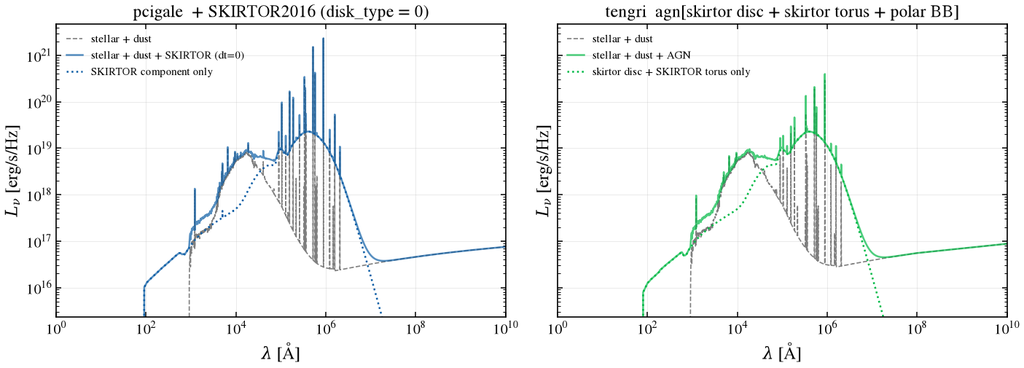

```python
sed_skirtor0 = C.run_chain(
    [
        _sfh_args_d,
        ("bc03", dict(imf=1, metallicity=0.02, separation_age=10)),
        NEB_FIDUCIAL_CIGALE,
        ("dustatt_modified_starburst", dict(E_BV_lines=0.3)),
        (
            "skirtor2016",
            dict(
                t=7,
                pl=1.0,
                q=1.0,
                oa=40,
                R=20,
                Mcl=0.97,
                i=30,
                disk_type=0,  # ← skirtor_disk ↔ tengri disc.skirtor
                delta=0,
                fracAGN=0.3,
                lambda_fracAGN="0/0",
                law=0,
                EBV=0.03,
                temperature=100.0,
                emissivity=1.6,
            ),
        ),
    ]
)
w_sk0, L_sk0 = C.to_lnu(sed_skirtor0)

m_agn_sk = SEDModel.build(
    ssp_data=ssp,
    met=MET_FIDUCIAL,
    sfh={
        "type": "delayed",
        "tau_gyr": Fixed(1.0),
        "age_gyr": Fixed(5.0),
        "log_total_mass": Fixed(0.0),
        "all_params": Fixed(DEFAULT),
    },
    dust_attenuation={
        "type": "two_component",
        "law_bc": "leitherer02",
        "law_diff": "leitherer02",
        "tau_bc": Fixed(TAU_BC_FIDUCIAL),
        "tau_diff": Fixed(TAU_DIFF_FIDUCIAL),
        # Same Lyman-limit clip as §9, so the stellar+dust floor under this
        # panel is the one §9 and the dashed baseline below already plot.
        "lyman_cutoff": True,
        "all_params": Fixed(DEFAULT),
    },
    agn={
        "type": "composable",
        "disc": {"type": "skirtor", "all_params": Fixed(DEFAULT)},  # ← the SKIRTOR analytic disc
        "torus": {"type": "skirtor", "all_params": Fixed(DEFAULT)},
        # Same polar-dust block and same fracAGN coupling as §9: only the disc
        # changes, so the two panels differ in one input.
        "atten": _POLAR_DUST_BLOCK,
        "agn_ir_frac": Fixed(0.3),
        "all_params": Fixed(DEFAULT),
    },
    neb=NEB_FIDUCIAL_TENGRI, redshift=Fixed(0.0),
)
s_agn_sk = m_agn_sk.predict_state({})

_print_agn_report(
    "§9b AGN parity, component by component (∫L_ν dν; skirtor disc):",
    sed_skirtor0,
    s_agn_sk,
)

fig, ax_l, ax_r = U.two_panel_fig()
U.panel(
    ax_l,
    ax_r,
    label_l="pcigale  + SKIRTOR2016 (disk_type = 0)",
    label_r="tengri  agn[skirtor disc + skirtor torus + polar BB]",
)
L_sk0_only = np.maximum(L_sk0 - U.regrid(w_base, L_base, w_sk0), 1e-50)
ax_l.plot(w_base, L_base, "k--", linewidth=1.0, alpha=0.5, label="stellar + dust")
ax_l.plot(w_sk0, L_sk0, "C0-", linewidth=1.5, alpha=0.7, label="stellar + dust + SKIRTOR (dt=0)")
ax_l.plot(w_sk0, L_sk0_only, "C0:", linewidth=1.5, label="SKIRTOR component only")
ax_l.legend(fontsize=9)
ax_l.grid(True, alpha=0.3)
L_sk_only = np.maximum(np.asarray(s_agn_sk.derived["sed_agn"]), 1e-50)
ax_r.plot(
    s_agn_base.wave,
    s_agn_base.sed_intrinsic,
    "k--",
    linewidth=1.0,
    alpha=0.5,
    label="stellar + dust",
)
ax_r.plot(
    s_agn_sk.wave,
    s_agn_sk.sed_intrinsic,
    "C1-",
    linewidth=1.5,
    alpha=0.7,
    label="stellar + dust + AGN",
)
ax_r.plot(
    s_agn_sk.wave, L_sk_only, "C1:", linewidth=1.5, label="skirtor disc + SKIRTOR torus only"
)
ax_r.legend(fontsize=9)
ax_r.grid(True, alpha=0.3)
_xmin_b = float(min(w_sk0.min(), float(np.asarray(s_agn_sk.wave).min())))
_xmax_b = float(max(w_sk0.max(), float(np.asarray(s_agn_sk.wave).max())))
_ymax_b = max(float(np.asarray(L_sk0).max()), float(np.asarray(s_agn_sk.sed_intrinsic).max()))
for ax in (ax_l, ax_r):
    ax.set_xlim(_xmin_b, _xmax_b)
    ax.set_ylim(_ymax_b * 1e-6, _ymax_b * 2)
fig.tight_layout()
save_fig("cigale_09b_disc_skirtor.png")
```

### §9d What separates the polar reference

Both codes set the polar dust's absorbed power from the same product, `g(oa) × R_faceon × J`: the polar cone's share of the disc's anisotropic emission, the face-on disc integral measured against the SKIRTOR dust integral, and `J = ∫disc·(1 − e^−τ) dλ / ∫disc dλ`, the fraction of the disc spectrum the polar screen absorbs. `g(oa)` is the same closed form on both sides and cancels from the comparison. The cell prints the other two and the two terms their ratio factors into, with the polar screen set to `polar_law="bongiorno"` (CIGALE's `law=0`) and, for contrast, to the default `polar_law="smc"` (Pei 1992).

`R_faceon` agrees: tengri reads 4.553520 off the vendored SKIRTOR grid against pcigale's own 4.562211, a ratio of 0.998095× (−0.19 %). What separates the polar reference is the pair of terms printed beneath it.

**The wavelength axis.** The vendored grid carries 136 wavelengths across 10 Å – 10⁸ Å where pcigale's carries 948, and each code integrates on its own. Holding the curve fixed (CIGALE's, on the vendored axis) and changing only the axis moves the absorbed fraction from 0.222842 to 0.232605, worth +4.18 % once `R_faceon` is included.

**The extinction curve.** With `polar_law="bongiorno"` the two curves coincide above 100 nm (the printed A(λ)/E(B−V) ratios are 1.000 at 2500 Å, 5500 Å and 1 µm) and differ only in the sub-100 nm SMC-bar shape (0.985 at 912 Å); the curve term is 0.975828× (−2.42 %). The default `polar_law="smc"` is a different curve (A(λ)/E(B−V) ratios 1.076, 1.011, 0.972 and 1.207 at 912 Å, 2500 Å, 5500 Å and 1 µm) and its curve term is 0.943527× (−5.65 %). Use `polar_law="bongiorno"` to compare with CIGALE's default polar dust.

The two terms multiply to 1.016639× with `polar_law="bongiorno"`: tengri sets its polar dust from 1.66 % more absorbed disc power than pcigale does. With the default `polar_law="smc"` the product is 0.982987×.

```python
from pcigale.data import SimpleDatabase as _CigaleDB
from pcigale.sed_modules.skirtor2016 import k_ext as _cigale_k_ext
from pcigale.sed_modules.skirtor2016 import schartmann2005_disk as _cigale_disc

from tengri.components.agn.disc_cigale import schartmann2005_disk_spectrum
from tengri.components.agn.polar_dust import bongiorno2012_extinction_curve
from tengri.components.agn.skirtor import load_skirtor_bundle, skirtor_disc_dust_ratio
from tengri.components.dust.attenuation import smc as _tengri_smc

_OA_SKIRTOR, _EBV_POLAR, _RV_SMC = 40.0, 0.03, 2.93
_COS_I_FIDUCIAL = float(np.cos(np.deg2rad(30.0)))

# tengri's face-on reference, straight off the vendored grid. The tie is given
# an unreddened disc (`ext_fac = 1`), exactly as the composable AGN calls it:
# the polar screen enters through J below, not through R_faceon.
_w_tie = np.logspace(1.0, 7.0, 20000)
_tie = skirtor_disc_dust_ratio(
    _w_tie,
    schartmann2005_disk_spectrum(_w_tie),
    np.ones_like(_w_tie),
    _template=load_skirtor_bundle().disc_dust,
    agn_oa_skirtor=_OA_SKIRTOR,
    agn_cos_inc=_COS_I_FIDUCIAL,
)
_R_faceon_t = float(_tie.R_faceon)
_wave_native = np.asarray(_tie.wave_native)
_disc_shape_t = np.asarray(_tie.faceon_shape_native)

# pcigale's own, rebuilt from its database the way skirtor2016._init_code does:
# the i = 0 record carried onto the observer record's luminosity scale by
# norm(0)/norm(i), divided by that record's dust integral.
with _CigaleDB("skirtor2016") as _db:
    _sk_i = _db.get(t=7, pl=1.0, q=1.0, oa=40, R=20, Mcl=0.97, i=30)
    _sk_0 = _db.get(t=7, pl=1.0, q=1.0, oa=40, R=20, Mcl=0.97, i=0)
_wave_c_nm = np.asarray(_sk_i.wl)
_R_faceon_c = float(
    np.trapezoid(np.asarray(_sk_0.disk) * (_sk_0.norm / _sk_i.norm), x=np.asarray(_sk_0.wl))
    / np.trapezoid(np.asarray(_sk_i.dust), x=_wave_c_nm)
)

# The curves on one dense axis. `k_ext` rescales its sub-100 nm branch to meet
# the power law at the last grid point below that boundary, so it has to be
# evaluated once on an axis that resolves the boundary rather than sampled point
# by point. tengri's `polar_law="bongiorno"` is the curve the notebook's builds
# use; the default `polar_law="smc"` (Pei 1992 SMC bar, R_V = 2.93) is shown for
# contrast.
_w_dense = np.logspace(1.0, 6.0, 20001)
_k_cigale_dense = _cigale_k_ext(_w_dense / 10.0, 0)
_k_tengri_dense = np.asarray(bongiorno2012_extinction_curve(jnp.asarray(_w_dense)))
_k_pei_dense = np.asarray(_tengri_smc(_w_dense)) * _RV_SMC


def _absorbed_fraction(disc_shape, wave_aa, k_lambda):
    """J = ∫disc·(1 − 10^(−0.4·k·E(B−V))) dλ / ∫disc dλ [dimensionless]."""
    _transmitted = 10.0 ** (-0.4 * k_lambda * _EBV_POLAR)
    return float(
        np.trapezoid(disc_shape * (1.0 - _transmitted), wave_aa)
        / np.trapezoid(disc_shape, wave_aa)
    )


_J_t = _absorbed_fraction(_disc_shape_t, _wave_native, np.interp(_wave_native, _w_dense, _k_tengri_dense))
_J_pei = _absorbed_fraction(_disc_shape_t, _wave_native, np.interp(_wave_native, _w_dense, _k_pei_dense))
# CIGALE's curve on tengri's axis: the control that separates the two terms.
_J_c_on_native = _absorbed_fraction(
    _disc_shape_t, _wave_native, np.interp(_wave_native, _w_dense, _k_cigale_dense)
)
_J_c = _absorbed_fraction(
    _cigale_disc(_wave_c_nm), _wave_c_nm * 10.0, _cigale_k_ext(_wave_c_nm, 0)
)

_term_quadrature = (_R_faceon_t * _J_c_on_native) / (_R_faceon_c * _J_c)
_term_curve = _J_t / _J_c_on_native
_polar_reference_ratio = (_R_faceon_t * _J_t) / (_R_faceon_c * _J_c)

print("§9d polar reference g(oa)·R_faceon·J, tengri against pcigale (i = 30°):")
print(
    f"  R_faceon = ∫disc(face-on)/∫dust: tengri {_R_faceon_t:.6f}, "
    f"pcigale {_R_faceon_c:.6f} → {_R_faceon_t / _R_faceon_c:.6f}× "
    f"({(_R_faceon_t / _R_faceon_c - 1) * 100:+.2f}%)"
)
print(
    f"  wavelength axis: vendored grid {_wave_native.size} points, "
    f"pcigale {_wave_c_nm.size}, same 10 Å–10⁸ Å span"
)
print(
    f"  J absorbed fraction: tengri {_J_t:.6f}, pcigale {_J_c:.6f} "
    f"(CIGALE's curve on the vendored axis: {_J_c_on_native:.6f})"
)
print(
    f"  term 1, wavelength quadrature: {_term_quadrature:.6f}× "
    f"({(_term_quadrature - 1) * 100:+.2f}%)"
)
print(
    f"  term 2, polar_law='bongiorno' extinction curve: {_term_curve:.6f}× "
    f"({(_term_curve - 1) * 100:+.2f}%)"
)
print(
    f"  product {_term_quadrature * _term_curve:.6f}× = polar reference ratio "
    f"{_polar_reference_ratio:.6f}× ({(_polar_reference_ratio - 1) * 100:+.2f}%)"
)
_CURVE_POINTS = ((912.0, "912 Å"), (2500.0, "2500 Å"), (5500.0, "5500 Å"), (1e4, "1 µm"))
for _curve_name, _k_dense in (("bongiorno", _k_tengri_dense), ("smc (Pei 1992, default)", _k_pei_dense)):
    print(
        f"  A(λ)/E(B−V), pcigale / tengri polar_law='{_curve_name}': "
        + ", ".join(
            f"{float(np.interp(_x, _w_dense, _k_cigale_dense)) / float(np.interp(_x, _w_dense, _k_dense)):.3f} at {_label}"
            for _x, _label in _CURVE_POINTS
        )
    )
print(
    f"  for contrast, the default polar_law='smc': J = {_J_pei:.6f}, term 2 = "
    f"{_J_pei / _J_c_on_native:.6f}× ({(_J_pei / _J_c_on_native - 1) * 100:+.2f}%), "
    f"polar reference ratio {(_R_faceon_t * _J_pei) / (_R_faceon_c * _J_c):.6f}×"
)
```

```
§9d polar reference g(oa)·R_faceon·J, tengri against pcigale (i = 30°):
  R_faceon = ∫disc(face-on)/∫dust: tengri 4.553520, pcigale 4.562211 → 0.998095× (-0.19%)
  wavelength axis: vendored grid 136 points, pcigale 948, same 10 Å–10⁸ Å span
  J absorbed fraction: tengri 0.226983, pcigale 0.222842 (CIGALE's curve on the vendored axis: 0.232605)
  term 1, wavelength quadrature: 1.041822× (+4.18%)
  term 2, polar_law='bongiorno' extinction curve: 0.975828× (-2.42%)
  product 1.016639× = polar reference ratio 1.016639× (+1.66%)
  A(λ)/E(B−V), pcigale / tengri polar_law='bongiorno': 0.985 at 912 Å, 1.000 at 2500 Å, 1.000 at 5500 Å, 1.000 at 1 µm
  A(λ)/E(B−V), pcigale / tengri polar_law='smc (Pei 1992, default)': 1.076 at 912 Å, 1.011 at 2500 Å, 0.972 at 5500 Å, 1.207 at 1 µm
  for contrast, the default polar_law='smc': J = 0.219469, term 2 = 0.943527× (-5.65%), polar reference ratio 0.982987×
```

### §9e AGN dust grids: SKIRTOR (τ, oa, i) and Fritz

CIGALE modules `skirtor2016` and `fritz2006` ↔ tengri's `torus.skirtor` and `torus.fritz` with the same polar-dust block as §9. Each panel compares AGN dust emission, torus plus polar screen summed; the two figures overlay the sums and show the tengri/CIGALE ratio. The sum is independent of how each code partitions the two: pcigale subtracts the polar re-emission from the torus dust, while tengri rescales the torus against a shared budget and carries the polar term separately.

SKIRTOR: τ_9.7 ∈ {3, 7, 11}, oa ∈ {20°, 40°, 60°}, i ∈ {0°, 30°, 70°}, each varied one at a time from §9's fiducial (7, 40°, 30°). The printed IR-band table gives a median ratio of 1.002–1.007× in every case, with no band outside 5 % and a worst band of at most 1.031×: optical depth, opening angle and inclination all agree.

Fritz 2006: (τ, opening angle, ψ) ∈ {(1, 60°, 0.001°), (1, 100°, 40.1°), (6, 60°, 89.99°)}, with r_ratio=60, β=−0.5, γ=4, a Schartmann disc, fracAGN=0.3 and EBV=0.03. `agn_cos_inc` is the one inclination: the library's viewing elevation is ψ = 90° − i, so the cell passes `agn_cos_inc = sin ψ`. CIGALE's opening angle is the full angle and maps to tengri's half-angle via `agn_fritz_oa = (180 − opening_angle) / 2`. Under `cigale_joint` the Fritz torus carries the same `agn_ir_frac` tie as SKIRTOR. The printed table gives band medians of 0.919×–0.970×, with worst bands between 0.843× and 1.146× and 9 to 10 of 12 IR bands outside 5 %: the median band differs by 3–8 % (9, 9 and 10 of 12 bands are outside 5 %), and the spread across bands places the remaining difference in the spectral distribution rather than in one scale factor.

```
§9e SKIRTOR (τ, oa, i) grid (IR_BANDS):
  §9e τ=3, oa=40°, i=30°                               median 1.007x  worst 1.023x  0/13 outside 5%
  §9e τ=7, oa=40°, i=30°                               median 1.004x  worst 1.026x  0/13 outside 5%
  §9e τ=11, oa=40°, i=30°                              median 1.003x  worst 1.024x  0/13 outside 5%
  §9e τ=7, oa=20°, i=30°                               median 1.005x  worst 1.015x  0/13 outside 5%
  §9e τ=7, oa=60°, i=30°                               median 1.006x  worst 1.031x  0/13 outside 5%
  §9e τ=7, oa=40°, i=0°                                median 1.004x  worst 1.023x  0/13 outside 5%
  §9e τ=7, oa=40°, i=70°                               median 1.002x  worst 1.024x  0/13 outside 5%
```

```
§9e Fritz 2006 (τ, opening angle, ψ) grid (IR_BANDS):
  §9e τ=1.0, oa=60.0°, ψ=0.001°                        median 0.970x  worst 1.146x  9/12 outside 5%
  §9e τ=1.0, oa=100.0°, ψ=40.1°                        median 0.919x  worst 0.843x  9/12 outside 5%
  §9e τ=6.0, oa=60.0°, ψ=89.99°                        median 0.954x  worst 1.143x  10/12 outside 5%
```

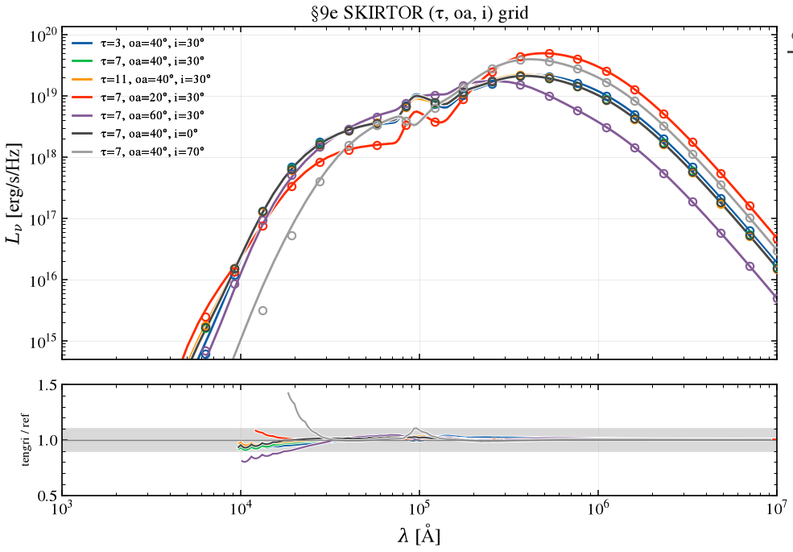

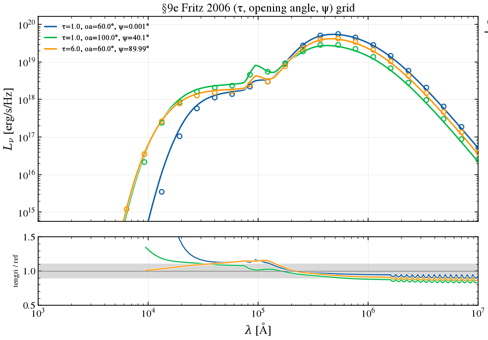

```python
_AGN_SFH_9E = {
    "type": "delayed", "tau_gyr": Fixed(1.0), "age_gyr": Fixed(5.0),
    "log_total_mass": Fixed(0.0), "all_params": Fixed(DEFAULT),
}
_AGN_DUSTATT_9E = {
    "type": "two_component", "law_bc": "leitherer02", "law_diff": "leitherer02",
    "tau_bc": Fixed(TAU_BC_FIDUCIAL), "tau_diff": Fixed(TAU_DIFF_FIDUCIAL),
    "lyman_cutoff": True, "all_params": Fixed(DEFAULT),
}


def _cigale_skirtor_sed(t, oa, i):
    return C.run_chain(
        [
            _sfh_args_d,
            ("bc03", dict(imf=1, metallicity=0.02, separation_age=10)),
            NEB_FIDUCIAL_CIGALE,
            ("dustatt_modified_starburst", dict(E_BV_lines=0.3)),
            (
                "skirtor2016",
                dict(
                    t=t, pl=1.0, q=1.0, oa=oa, R=20, Mcl=0.97, i=i, disk_type=1, delta=0,
                    fracAGN=0.3, lambda_fracAGN="0/0", law=0, EBV=0.03, temperature=100.0, emissivity=1.6,
                ),
            ),
        ]
    )


m_skirtor_sweep = SEDModel.build(
    ssp_data=ssp,
    met=MET_FIDUCIAL,
    sfh=_AGN_SFH_9E,
    dust_attenuation=_AGN_DUSTATT_9E,
    agn={
        "type": "composable",
        "disc": {"type": "schartmann2005", "all_params": Fixed(DEFAULT)},
        "torus": {
            "type": "skirtor",
            "tau_skirtor": Uniform(3.0, 11.0, default=7.0),
            "oa_skirtor": Uniform(10.0, 80.0, default=40.0),
            "cos_inc": Uniform(0.0, 1.0, default=float(np.cos(np.deg2rad(30.0)))),
            "all_params": Fixed(DEFAULT),
        },
        "atten": _POLAR_DUST_BLOCK,
        "agn_ir_frac": Fixed(0.3),
        "all_params": Fixed(DEFAULT),
    },
    neb=NEB_FIDUCIAL_TENGRI, redshift=Fixed(0.0),
)
p_sk_sweep = dict(m_skirtor_sweep.spec.sample(jax.random.PRNGKey(0)))

_skirtor_grid = [(3, 40, 30), (7, 40, 30), (11, 40, 30), (7, 20, 30), (7, 60, 30), (7, 40, 0), (7, 40, 70)]
_cases_9e_sk = []
for _tau, _oa, _i in _skirtor_grid:
    _sed_c9e = _cigale_skirtor_sed(_tau, _oa, _i)
    _w_c9e, _L_torus_c9e = C.to_lnu_contribution(_sed_c9e, "agn.SKIRTOR2016_torus")
    _, _L_polar_c9e = C.to_lnu_contribution(_sed_c9e, "agn.SKIRTOR2016_polar_dust")
    _L_c9e = _L_torus_c9e + _L_polar_c9e  # Sum torus + polar (partition-independent)
    _pred_9e = m_skirtor_sweep.predict(
        {
            **p_sk_sweep,
            "agn_tau_skirtor": jnp.float64(_tau),
            "agn_oa_skirtor": jnp.float64(_oa),
            "agn_cos_inc": jnp.float64(np.cos(np.deg2rad(_i))),
        }
    )
    _w_t_9e = np.asarray(_pred_9e.sed.components["wavelength"])
    _L_torus_t_9e = np.asarray(_pred_9e.sed.components["sed_agn_torus"])
    _L_polar_t_9e = np.asarray(_pred_9e.sed.components["sed_agn_polar"])
    _L_t_9e = _L_torus_t_9e + _L_polar_t_9e  # Sum torus + polar
    _cases_9e_sk.append(
        (f"τ={_tau}, oa={_oa}°, i={_i}°", _w_c9e, _L_c9e, _w_t_9e, _L_t_9e)
    )
    _assert_comparable(_L_c9e, _L_t_9e, name=f"§9e skirtor {_tau},{_oa},{_i}")

fig, (ax, ax_r), _ratios_9e_sk = V.sweep_fig(
    _cases_9e_sk, ref_label="CIGALE", title="§9e SKIRTOR (τ, oa, i) grid", xlim=(1e3, 1e7)
)
fig.tight_layout()
save_fig("cigale_09e_skirtor_grid.png")
print("§9e SKIRTOR (τ, oa, i) grid (IR_BANDS):")
for _label, _w_ref, _L_ref, _w_t, _L_t in _cases_9e_sk:
    _rows = V.filter_rows_native(np.asarray(_w_t), np.asarray(_L_t), _w_ref, _L_ref, filters=V.IR_BANDS)
    V.print_filter_table(_rows, ref_name="CIGALE", title=f"§9e {_label}", compact=True)


def _cigale_fritz_sed(tau, oa, psy):
    return C.run_chain(
        [
            _sfh_args_d,
            ("bc03", dict(imf=1, metallicity=0.02, separation_age=10)),
            NEB_FIDUCIAL_CIGALE,
            ("dustatt_modified_starburst", dict(E_BV_lines=0.3)),
            (
                "fritz2006",
                dict(
                    r_ratio=60.0, tau=tau, beta=-0.5, gamma=4.0, opening_angle=oa, psy=psy,
                    disk_type=1, fracAGN=0.3, EBV=0.03, temperature=100.0, emissivity=1.6,
                ),
            ),
        ]
    )


# Under `agn_norm='cigale_joint'` the Fritz torus carries the same fracAGN tie as
# SKIRTOR: `agn_ir_frac = 0.3` sets P_AGN = L_absorbed x f/(1-f) and ties the disc
# to the library's disc-to-dust ratio at the viewing angle, as CIGALE's
# `fritz2006` does.
m_fritz_sweep = SEDModel.build(
    ssp_data=ssp,
    met=MET_FIDUCIAL,
    sfh=_AGN_SFH_9E,
    dust_attenuation=_AGN_DUSTATT_9E,
    agn={
        "type": "composable",
        "disc": {"type": "schartmann2005", "all_params": Fixed(DEFAULT)},
        "torus": {
            "type": "fritz",
            "fritz_tau": Uniform(0.1, 10.0, default=1.0),
            "fritz_oa": Uniform(20.0, 60.0, default=60.0),
            "agn_cos_inc": Uniform(0.0, 1.0, default=0.7071),
            "fritz_r_ratio": Fixed(60.0),
            "fritz_beta": Fixed(-0.5),
            "fritz_gamma": Fixed(4.0),
            "all_params": Fixed(DEFAULT),
        },
        "atten": _POLAR_DUST_BLOCK,
        "agn_ir_frac": Fixed(0.3),
        "all_params": Fixed(DEFAULT),
    },
    neb=NEB_FIDUCIAL_TENGRI, redshift=Fixed(0.0),
)
p_fritz_sweep = dict(m_fritz_sweep.spec.sample(jax.random.PRNGKey(0)))

_fritz_grid = [(1.0, 60.0, 0.001), (1.0, 100.0, 40.1), (6.0, 60.0, 89.99)]
_cases_9e_fr = []
for _tau, _oa, _psy in _fritz_grid:
    _sed_c9f = _cigale_fritz_sed(_tau, _oa, _psy)
    _w_c9f, _L_torus_c9f = C.to_lnu_contribution(_sed_c9f, "agn.fritz2006_torus")
    _, _L_polar_c9f = C.to_lnu_contribution(_sed_c9f, "agn.fritz2006_polar_dust")
    _L_c9f = _L_torus_c9f + _L_polar_c9f  # Sum torus + polar (partition-independent)
    _oa_half = (180.0 - _oa) / 2.0
    _pred_9f = m_fritz_sweep.predict(
        {
            **p_fritz_sweep,
            "agn_fritz_tau": jnp.float64(_tau),
            "agn_fritz_oa": jnp.float64(_oa_half),
            # One inclination: the library elevation psi = 90 deg - i, cos i = sin psi.
            "agn_cos_inc": jnp.float64(np.sin(np.radians(_psy))),
        }
    )
    _w_t_9f = np.asarray(_pred_9f.sed.components["wavelength"])
    _L_torus_t_9f = np.asarray(_pred_9f.sed.components["sed_agn_torus"])
    _L_polar_t_9f = np.asarray(_pred_9f.sed.components["sed_agn_polar"])
    _L_t_9f = _L_torus_t_9f + _L_polar_t_9f  # Sum torus + polar
    _cases_9e_fr.append(
        (f"τ={_tau}, oa={_oa}°, ψ={_psy}°", _w_c9f, _L_c9f, _w_t_9f, _L_t_9f)
    )
    _assert_comparable(_L_c9f, _L_t_9f, name=f"§9e fritz {_tau},{_oa},{_psy}")

fig, (ax, ax_r), _ratios_9e_fr = V.sweep_fig(
    _cases_9e_fr, ref_label="CIGALE", title="§9e Fritz 2006 (τ, opening angle, ψ) grid", xlim=(1e3, 1e7)
)
fig.tight_layout()
save_fig("cigale_09f_fritz_grid.png")
print("§9e Fritz 2006 (τ, opening angle, ψ) grid (IR_BANDS):")
for _label, _w_ref, _L_ref, _w_t, _L_t in _cases_9e_fr:
    _rows = V.filter_rows_native(np.asarray(_w_t), np.asarray(_L_t), _w_ref, _L_ref, filters=V.IR_BANDS)
    V.print_filter_table(_rows, ref_name="CIGALE", title=f"§9e {_label}", compact=True)
```

## §10 X-ray

CIGALE module `xray` (Yang et al. 2020: an AGN corona power law plus X-ray binaries and hot gas) ↔ tengri `xray={"type": "yang20"}`. The figure overlays the two coronas against photon energy, with the tengri/CIGALE ratio below. Three conventions are matched: α_ox is derived from L_2500 (Just et al. 2007, `L_2keV = L_2500 · 10^(α_ox/0.3838)`) on both sides at log₁₀ L_2500 = 29.47; inclination follows Yang+2020 at i = 30° (`agn_cos_inc`); and N_H is pinned to zero on both sides. The disc power is set through `agn_log_lbol` (the angle-integrated accretion power), solved so that both codes' intrinsic L_2500 agree to the printed digits. At `log N_H = 0` tengri's Ricci et al. (2017) scattered floor is 1 % of an unabsorbed corona and is not what the printed residual is. The cell prints the ratio at 2 keV and as a median over 0.5–10 keV.

**Verification Status:** PARTIAL (3/16): Radio, X-ray and AGN

```
§10 matched disc L_2500: CIGALE log10=29.4745  tengri log10=29.4745
§10 corona parity (tengri/CIGALE): 2 keV = 1.010x, median 0.5-10 keV = 1.010x
```

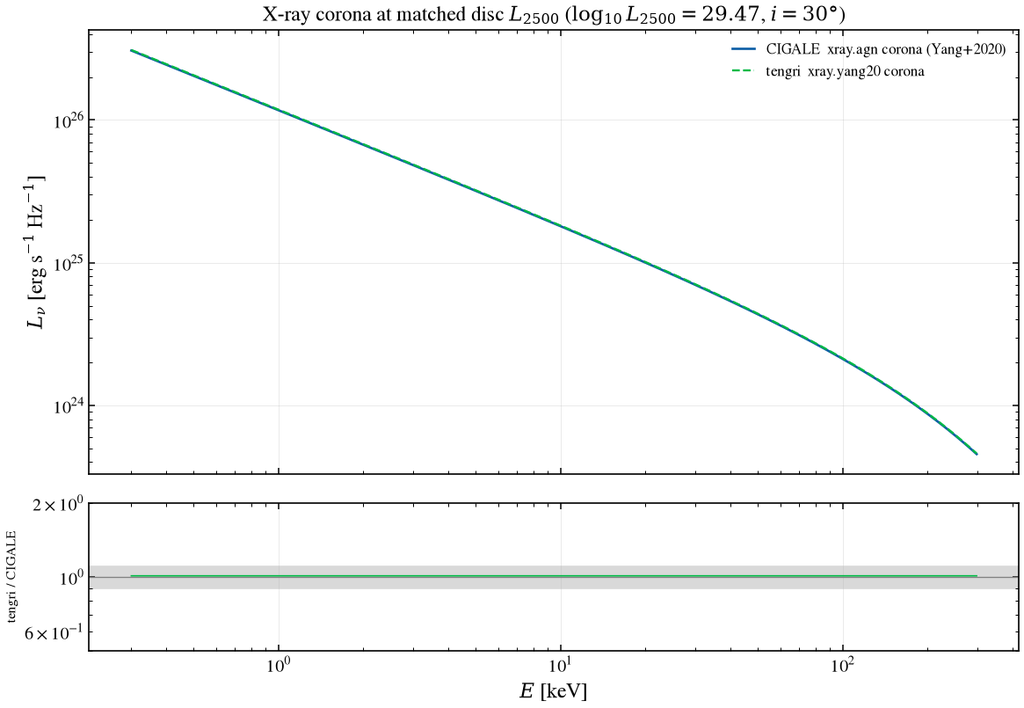

```python
_LOG_L2500_TARGET = (2.638 + 1.4) / 0.137  # Just+2007 == CIGALE's -1.4


def _cigale_xray(sfr_a, incl):
    return C.run_chain(
        [
            (
                "sfhdelayed",
                dict(
                    tau_main=1000,
                    age_main=5000,
                    tau_burst=50,
                    age_burst=20,
                    f_burst=0.0,
                    sfr_A=sfr_a,
                    normalise=False,
                ),
            ),
            ("bc03", dict(imf=1, metallicity=0.02, separation_age=10)),
            NEB_FIDUCIAL_CIGALE,
            ("dustatt_modified_starburst", dict(E_BV_lines=0.3)),
            ("dale2014", dict(alpha=2.0)),
            (
                "skirtor2016",
                dict(
                    t=7,
                    pl=1.0,
                    q=1.0,
                    oa=40,
                    R=20,
                    Mcl=0.97,
                    i=incl,
                    disk_type=1,
                    delta=-0.36,
                    fracAGN=0.3,
                    law=0,
                    EBV=0.0,
                    temperature=100,
                    emissivity=1.6,
                ),
            ),
            (
                "yang20",
                dict(
                    gam=1.8,
                    E_cut=300.0,
                    alpha_ox=-1.4,
                    max_dev_alpha_ox=0.2,
                    angle_coef="0.5 & 0",
                    det_lmxb=0.0,
                    det_hmxb=0.0,
                ),
            ),
        ]
    )


def _cigale_corona(sed):
    """CIGALE's corona-only component in tengri units (erg/s/Hz, Å)."""
    return U.wnm_to_erg_per_hz_per_aa(
        np.asarray(sed.wavelength_grid), np.asarray(sed.luminosities["xray.agn"])
    )


def _cigale_l2500(sed):
    """Intrinsic disc L_2500 [erg/s/Hz]; CIGALE stores W/Hz."""
    return float(sed.info["agn.intrin_Lnu_2500A_30deg"]) * 1e7


def _tengri_xray(log_lbol, cos_inc):
    return SEDModel.build(
        ssp_data=ssp,
        met=MET_FIDUCIAL,
        sfh={
            "type": "delayed",
            "tau_gyr": Fixed(1.0),
            "age_gyr": Fixed(5.0),
            "log_total_mass": Fixed(0.0),
            "all_params": Fixed(DEFAULT),
        },
        dust_attenuation={
            "type": "two_component",
            "law_bc": "leitherer02",
            "law_diff": "leitherer02",
            "tau_bc": Fixed(TAU_BC_FIDUCIAL),
            "tau_diff": Fixed(TAU_DIFF_FIDUCIAL),
            # Lyman-limit clip (CIGALE parity) — match §5/§6
            "lyman_cutoff": True,
            "all_params": Fixed(DEFAULT),
        },
        agn={
            "type": "composable",
            "disc": {"type": "schartmann2005", "all_params": Fixed(DEFAULT)},
            "torus": {"type": "skirtor", "all_params": Fixed(DEFAULT)},
            # Polar dust off, matching the ``EBV=0.0`` in this section's
            # skirtor2016 call — stated rather than left to omission, since it
            # is the one AGN input §9 and §10 deliberately differ on.
            # ``type='none'`` and not ``polar_dust`` with ebv = 0: the block
            # refuses to be selected with no extinction to apply.
            "atten": {"type": "none"},
            # No ``agn_ir_frac`` here: this section solves for the disc power
            # directly, so ``agn_log_lbol`` is the knob that acts.
            "agn_log_lbol": Fixed(log_lbol),
            "agn_cos_inc": Fixed(cos_inc),
            "all_params": Fixed(DEFAULT),
        },
        xray={"type": "yang20", "log_nh": Fixed(0.0), "all_params": Fixed(DEFAULT)},
        neb=NEB_FIDUCIAL_TENGRI, redshift=Fixed(0.0),
    )


_COS30 = float(np.cos(np.radians(30.0)))

# Solve both codes onto log10 L_2500 = 29.47 from one trial run each —
# the disc scales linearly with sfr_A (CIGALE, via fracAGN) and with
# 10**agn_log_lbol (tengri, schartmann2005 has an L_bol-independent shape).
_trial_c = _cigale_xray(1e8, 30)
_SFR_A_XRAY = 1e8 * 10.0**_LOG_L2500_TARGET / _cigale_l2500(_trial_c)
sed_x = _cigale_xray(_SFR_A_XRAY, 30)
w_x, L_x = _cigale_corona(sed_x)
_l2500_c = _cigale_l2500(sed_x)

_trial_t = _tengri_xray(11.5, _COS30).predict_state({})
_AGN_LOG_LBOL_XRAY = 11.5 + float(
    np.log10(_l2500_c / float(np.asarray(_trial_t.derived["L_2500_intrinsic"])))
)
state_x = _tengri_xray(_AGN_LOG_LBOL_XRAY, _COS30).predict_state({})
_l2500_t = float(np.asarray(state_x.derived["L_2500_intrinsic"]))
print(
    f"§10 matched disc L_2500: CIGALE log10={np.log10(_l2500_c):.4f}  "
    f"tengri log10={np.log10(_l2500_t):.4f}"
)

w_t = np.asarray(state_x.wave)
sed_t = np.asarray(state_x.derived["sed_xray"])
e_kev_c = 12.398 / w_x
e_kev_t = 12.398 / w_t

m_c = (e_kev_c >= 0.3) & (e_kev_c <= 300) & (L_x > 0)
_order = np.argsort(e_kev_c[m_c])
_e = e_kev_c[m_c][_order]
_Lc = L_x[m_c][_order]
_Lt = U.regrid(e_kev_t, sed_t, _e)
_ratio = _Lt / np.maximum(_Lc, 1e-300)
_assert_comparable(_Lc, _Lt, name="§10 corona")

fig, (ax, ax_r) = plt.subplots(
    2, 1, figsize=(10, 7), sharex=True, gridspec_kw={"height_ratios": [3, 1]}
)
ax.plot(_e, _Lc, "C0-", linewidth=1.6, label="CIGALE  xray.agn corona (Yang+2020)")
ax.plot(_e, _Lt, "C1--", linewidth=1.4, label="tengri  xray.yang20 corona")
ax.set_xscale("log")
ax.set_yscale("log")
ax.set_ylabel(r"$L_\nu$ [erg s$^{-1}$ Hz$^{-1}$]")
ax.set_title(
    r"X-ray corona at matched disc $L_{2500}$ "
    r"($\log_{10} L_{2500} = 29.47$, $i = 30°$)"
)
ax.legend(fontsize=10)
ax.grid(True, alpha=0.3)
ax_r.axhspan(0.9, 1.1, color="0.85", zorder=0)
ax_r.axhline(1.0, color="0.5", linewidth=0.8)
ax_r.plot(_e, _ratio, "C1-", linewidth=1.0)
ax_r.set_xscale("log")
ax_r.set_yscale("log")
ax_r.set_ylim(0.5, 2.0)
ax_r.set_xlabel(r"$E$ [keV]")
ax_r.set_ylabel("tengri / CIGALE", fontsize=9)
ax_r.grid(True, alpha=0.3)
_soft = (_e >= 0.5) & (_e <= 10.0)
print(
    f"§10 corona parity (tengri/CIGALE): 2 keV = "
    f"{_ratio[np.argmin(np.abs(_e - 2.0))]:.3f}x, "
    f"median 0.5-10 keV = {float(np.median(_ratio[_soft])):.3f}x"
)
fig.tight_layout()
save_fig("cigale_10_xray_corona.png")
```

### §10b Inclination sweep

The Yang et al. (2022) corona anisotropy `f(μ) = (a₁μ + 1 − a₁) / (1 − 0.13397 a₁)` with a₁ = 0.5 equals 1 at the 30° anchor. Both codes apply the same f(cos i) tilt; the sweep rescales each angle to hold the corona anchor at the α_ox crossing.

```
 i     f(mu)   log10 L_2500,c   tengri/CIGALE @ 2 keV
```

```
  0    1.0718   29.4745          1.0100
```

```
 30    1.0000   29.4745          1.0100
```

```
 60    0.8038   29.4745          1.0100
```

```
 80    0.6290   29.4745          1.0100
```

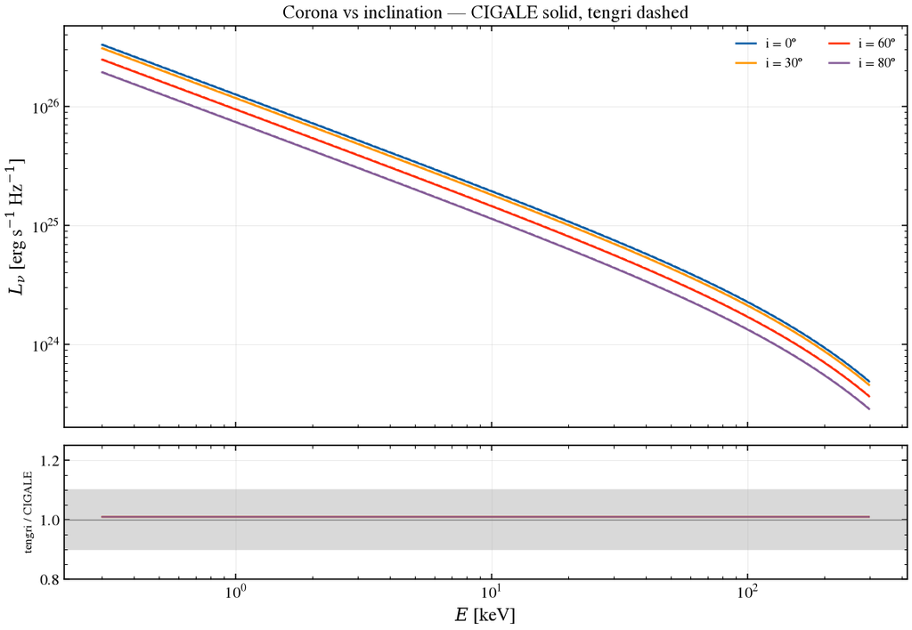

```python
fig, (ax, ax_r) = plt.subplots(
    2, 1, figsize=(10, 7), sharex=True, gridspec_kw={"height_ratios": [3, 1]}
)
print(" i     f(mu)   log10 L_2500,c   tengri/CIGALE @ 2 keV")
for _i_deg, _col in zip((0, 30, 60, 80), ("C0", "C2", "C3", "C4")):
    # hold the corona anchor at the alpha_ox crossing: fracAGN raises the
    # intrinsic disc as the torus hides it, so rescale sfr_A per angle
    _probe_i = _cigale_xray(_SFR_A_XRAY, _i_deg)
    sed_i = _cigale_xray(_SFR_A_XRAY * 10.0**_LOG_L2500_TARGET / _cigale_l2500(_probe_i), _i_deg)
    w_ci, L_ci = _cigale_corona(sed_i)
    _l25_i = _cigale_l2500(sed_i)
    _mu = float(np.cos(np.radians(_i_deg)))
    st_i = _tengri_xray(
        _AGN_LOG_LBOL_XRAY + float(np.log10(_l25_i / _l2500_c)), _mu
    ).predict_state({})
    w_ti = np.asarray(st_i.wave)
    L_ti = np.asarray(st_i.derived["sed_xray"])
    e_ci = 12.398 / w_ci
    _mm = (e_ci >= 0.3) & (e_ci <= 300) & (L_ci > 0)
    _oo = np.argsort(e_ci[_mm])
    _ee = e_ci[_mm][_oo]
    _LLc = L_ci[_mm][_oo]
    _LLt = U.regrid(12.398 / w_ti, L_ti, _ee)
    ax.plot(_ee, _LLc, color=_col, linewidth=1.5, label=f"i = {_i_deg}°")
    ax.plot(_ee, _LLt, color=_col, linewidth=1.2, linestyle="--")
    ax_r.plot(_ee, _LLt / np.maximum(_LLc, 1e-300), color=_col, linewidth=1.0)
    _f_mu = (0.5 * _mu + 0.5) / (1.0 - 0.13397 * 0.5)
    _r2 = float(_LLt[np.argmin(np.abs(_ee - 2.0))] / _LLc[np.argmin(np.abs(_ee - 2.0))])
    print(f" {_i_deg:2d}    {_f_mu:.4f}   {np.log10(_l25_i):.4f}          {_r2:.4f}")
ax.set_xscale("log")
ax.set_yscale("log")
ax.set_ylabel(r"$L_\nu$ [erg s$^{-1}$ Hz$^{-1}$]")
ax.set_title("Corona vs inclination — CIGALE solid, tengri dashed")
ax.legend(fontsize=10, ncol=2)
ax.grid(True, alpha=0.3)
ax_r.axhspan(0.9, 1.1, color="0.85", zorder=0)
ax_r.axhline(1.0, color="0.5", linewidth=0.8)
ax_r.set_xscale("log")
ax_r.set_ylim(0.8, 1.25)
ax_r.set_xlabel(r"$E$ [keV]")
ax_r.set_ylabel("tengri / CIGALE", fontsize=9)
ax_r.grid(True, alpha=0.3)
fig.tight_layout()
save_fig("cigale_10b_xray_inclination.png")
```

## §11 Radio

CIGALE module `radio` (`qir_sf`, `alpha_sf`) ↔ tengri `radio={"sf": {"type": "bell2003", "freefree": False}, "radio_q_ir": 2.5, "radio_alpha_sf": 0.8}`. The figure overlays the star-forming radio spectrum of both codes; the lower panel is the tengri/CIGALE ratio.

**What `q_IR` calibrates.** pcigale's `radio` module is synchrotron only: its `qir_sf` sets the 21 cm *non-thermal* luminosity, `L_ref = L_dust / (3.75e12 · 10^q_IR)`, and CIGALE's thermal free-free comes from its `nebular` module. tengri's `radio_q_ir` is by default Bell (2003)'s *total* 1.4 GHz calibration (synchrotron plus thermal): the synchrotron is the non-thermal share `1 − f_th` of that total, and the thermal part comes from the nebular continuum or, with `freefree: True`, from the Murphy et al. (2011) free-free term. `freefree: False` switches to CIGALE's convention: `q_IR` calibrates the non-thermal term alone, the synchrotron carries all of it, and the thermal free-free is whatever the nebular continuum supplies. The like-for-like comparison below therefore uses `freefree: False`; the default (total) convention is overlaid as the dash-dot curve.

Both codes anchor the amplitude on the absorbed dust power, so any mismatch in `L_absorbed` lands 1:1 in the radio. Two conventions predict the flat synchrotron ratio without being fitted: the anchor frequency (Bell 2003 defines `q_IR` at 1.4 GHz, CIGALE normalizes at 21 cm = 1.4276 GHz) and the energy anchor (`L_absorbed` against CIGALE's `dust.luminosity`, §6). The cell prints the measured range beside the prediction.

With `freefree: False` the synchrotron carries the whole `q_IR`; in the default (total) convention the printed (synchrotron + nebular continuum) / Bell total at 1.4 GHz is 0.954, below 1 because the nebular free-free share there is smaller than the Murphy et al. (2011) share `f_th` that the synchrotron subtracts.

The ratio panel also compares the two thermal terms, the nebular continuum's free-free tail and the Murphy et al. (2011) term, with CIGALE's synchrotron: a calibration comparison between two implementations of the same physics.

```
§11 radio tengri/CIGALE median (1.0–1.5 GHz): 0.994×
§11 synchrotron alone (freefree=False), tengri/CIGALE: 0.9941–0.9942 across 0.1–100 GHz (flat)
§11   predicted from conventions: anchor ×0.9845 · energy-balance ×1.0099 = ×0.9942
§11 default (total) convention: synchrotron / freefree=False synchrotron = 0.9033 at 1.4 GHz
§11   (synchrotron + nebular continuum) / Bell's calibrated total L(1.4 GHz) = 0.954
§11 thermal free-free, component-wise, as a fraction of CIGALE's synchrotron:
      0.15 GHz: nebular tail ×0.011, Murphy+2011 ×0.020
      1.40 GHz: nebular tail ×0.054, Murphy+2011 ×0.096
     10.02 GHz: nebular tail ×0.212, Murphy+2011 ×0.381
     99.85 GHz: nebular tail ×1.001, Murphy+2011 ×1.906
```

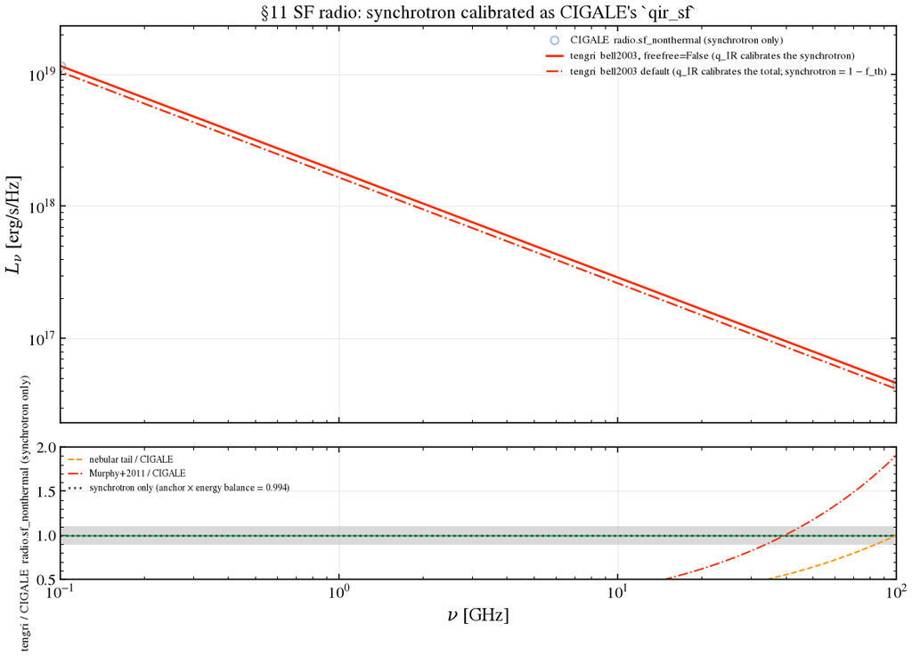

```python
sed_r = C.run_chain(
    [
        (
            "sfhdelayed",
            dict(
                tau_main=1000,
                age_main=5000,
                tau_burst=50,
                age_burst=20,
                f_burst=0.0,
                sfr_A=1.0,
                normalise=True,
            ),
        ),
        ("bc03", dict(imf=1, metallicity=0.02, separation_age=10)),
        NEB_FIDUCIAL_CIGALE,
        ("dustatt_modified_starburst", dict(E_BV_lines=0.3)),
        ("dale2014", dict(alpha=2.0)),
        ("radio", dict(qir_sf=2.5, alpha_sf=0.8, R_agn=0.0, alpha_agn=0.7)),
    ]
)
# CIGALE's SF radio is a single synchrotron component: isolate it.
w_r, L_r = U.wnm_to_erg_per_hz_per_aa(
    np.asarray(sed_r.wavelength_grid), np.asarray(sed_r.luminosities["radio.sf_nonthermal"])
)

_dust_radio_cfg = {
    "type": "two_component",
    "law_bc": "leitherer02",
    "law_diff": "leitherer02",
    "tau_bc": Fixed(TAU_BC_FIDUCIAL),
    "tau_diff": Fixed(TAU_DIFF_FIDUCIAL),
    "lyman_cutoff": True,
    "all_params": Fixed(DEFAULT),
}


def _radio_model(sf_block):
    """The §11 galaxy with one star-forming radio configuration."""
    return SEDModel.build(
        ssp_data=ssp,
        met=MET_FIDUCIAL,
        sfh={
            "type": "delayed",
            "tau_gyr": Fixed(1.0),
            "age_gyr": Fixed(5.0),
            "log_total_mass": Fixed(0.0),
            "all_params": Fixed(DEFAULT),
        },
        dust_attenuation=_dust_radio_cfg,
        dust_emission={
            "type": "dale2014_cigale",
            "alpha_dale": Fixed(2.0),
            "all_params": Fixed(DEFAULT),
        },
        radio={
            "sf": sf_block,
            "agn": {"type": "powerlaw"},
            "radio_q_ir": Fixed(2.5),
            "radio_alpha_sf": Fixed(0.8),
            "all_params": Fixed(DEFAULT),
        },
        neb=NEB_FIDUCIAL_TENGRI,
        redshift=Fixed(0.0),
    )


# CIGALE's convention: q_IR calibrates the non-thermal term alone.
state_r = _radio_model({"type": "bell2003", "freefree": False}).predict_state({})
w_t = np.asarray(state_r.wave)
sed_t = np.asarray(state_r.derived["sed_radio"])  # synchrotron carrying the whole q_IR

# tengri's default: q_IR calibrates Bell's total; thermal from the nebular continuum.
state_r_tot = _radio_model({"type": "bell2003"}).predict_state({})
sed_t_tot = np.asarray(state_r_tot.derived["sed_radio"])  # (1 - f_th) of the total

# Shared-axis overlay + ratio panel: the main pair is non-thermal on both sides.
fig, ax, ax_r, ratio = U.overlay_ratio_fig(
    w_r,
    L_r,
    w_t,
    sed_t,
    x_of_wave=lambda w: C_AA / w / 1e9,
    xlabel=r"$\nu$ [GHz]",
    title="§11 SF radio: synchrotron calibrated as CIGALE's `qir_sf`",
    label_c="CIGALE  radio.sf_nonthermal (synchrotron only)",
    label_t="tengri  bell2003, freefree=False (q_IR calibrates the synchrotron)",
    xlim=(0.1, 100.0),
    ratio_ylim=(0.5, 2.0),
)
# Widen CIGALE into a translucent band so the thin curves read against it.
for _ln in ax.get_lines():
    if _ln.get_label().startswith("CIGALE"):
        _ln.set(linewidth=4.0, alpha=0.35, solid_capstyle="round")

# The default (total-q) build: synchrotron is the non-thermal share of Bell's total.
ax.plot(
    C_AA / w_t / 1e9,
    sed_t_tot,
    color="C3",
    ls="-.",
    lw=1.4,
    label="tengri  bell2003 default (q_IR calibrates the total; synchrotron = 1 − f_th)",
)
ax.legend(fontsize=8, frameon=False)
_nu_r = C_AA / w_r / 1e9
_g14 = (_nu_r >= 1.0) & (_nu_r <= 1.5) & (L_r > 0)
print(f"§11 radio tengri/CIGALE median (1.0–1.5 GHz): {float(np.median(ratio[_g14])):.3f}×")

# Synchrotron against the two conventions that predict the ratio.
_L_ir_t = float(np.asarray(state_r.derived["L_ir"]))
_f_lir = _L_ir_t / (float(sed_r.info["dust.luminosity"]) * 1e7)
_f_anchor = float((1.4276e9 / 1.4e9) ** (-0.8))
_syn_t_on_c = U.regrid(w_t, sed_t, w_r)
_valid = (_nu_r >= 0.1) & (_nu_r <= 100.0) & (L_r > 0) & np.isfinite(ratio)
_syn_ratio = _syn_t_on_c[_valid] / L_r[_valid]
print(
    f"§11 synchrotron alone (freefree=False), tengri/CIGALE: "
    f"{_syn_ratio.min():.4f}–{_syn_ratio.max():.4f} across 0.1–100 GHz (flat)"
)
print(
    f"§11   predicted from conventions: anchor ×{_f_anchor:.4f} · "
    f"energy-balance ×{_f_lir:.4f} = ×{_f_anchor * _f_lir:.4f}"
)

# The total-q convention: the synchrotron is a fixed share of the freefree=False one,
# and synchrotron + nebular thermal recovers Bell's calibrated total at 1.4 GHz.
_sed_neb = np.asarray(state_r.derived["sed_nebular"])  # nebular continuum incl. free-free tail
_j14 = int(np.argmin(np.abs(C_AA / w_t - 1.4e9)))
_bell_total_14 = _L_ir_t / (3.75e12 * 10.0**2.5)
print(
    f"§11 default (total) convention: synchrotron / freefree=False synchrotron = "
    f"{sed_t_tot[_j14] / sed_t[_j14]:.4f} at 1.4 GHz"
)
print(
    f"§11   (synchrotron + nebular continuum) / Bell's calibrated total L(1.4 GHz) = "
    f"{(sed_t_tot[_j14] + _sed_neb[_j14]) / _bell_total_14:.3f}"
)

# Thermal free-free calibration, component-wise against CIGALE's synchrotron: the
# nebular continuum's tail and the Murphy+2011 term (the free-free the radio block
# adds with `freefree: True`) evaluated at the same L_IR.
_sed_murphy = np.asarray(
    radio_freefree(jnp.asarray(w_t), _L_ir_t, T_e=1.0e4, alpha_ff=-0.1)
)
_den = np.where(L_r > 0, L_r, np.nan)
_neb_on_c = np.asarray(U.regrid(w_t, _sed_neb, w_r))
_murphy_on_c = np.asarray(U.regrid(w_t, _sed_murphy, w_r))
ax_r.plot(_nu_r, _neb_on_c / _den, color="C2", ls="--", lw=1.2, label="nebular tail / CIGALE")
ax_r.plot(_nu_r, _murphy_on_c / _den, color="C3", ls="-.", lw=1.2, label="Murphy+2011 / CIGALE")
ax_r.axhline(
    _f_anchor * _f_lir,
    color="0.25",
    ls=":",
    lw=1.6,
    label=f"synchrotron only (anchor × energy balance = {_f_anchor * _f_lir:.3f})",
)
ax_r.legend(fontsize=7, frameon=False, loc="upper left")
_nu_valid = np.asarray(_nu_r[_valid])
_neb_valid = _neb_on_c[_valid] / L_r[_valid]
_murphy_valid = _murphy_on_c[_valid] / L_r[_valid]
print("§11 thermal free-free, component-wise, as a fraction of CIGALE's synchrotron:")
for _f in (0.15, 1.4, 10.0, 100.0):
    _j = int(np.argmin(np.abs(_nu_valid - _f)))
    print(
        f"    {float(_nu_valid[_j]):6.2f} GHz: nebular tail ×{float(_neb_valid[_j]):.3f}, "
        f"Murphy+2011 ×{float(_murphy_valid[_j]):.3f}"
    )
fig.tight_layout()
save_fig("cigale_11_radio_synchrotron.png")
```

## §12 IGM transmission

CIGALE module `redshifting` (`igm_transmission`) ↔ tengri `igm.meiksin06` (`igm_transmission_meiksin06`): Meiksin (2006) IGM attenuation, Lyman series and the diffuse-IGM Lyα forest continuum suppression. The figure plots each code's transmission against observed wavelength at z = 3, 5 and 7.

**Where they differ.** CIGALE 2025.1 evaluates the n ≥ 3 Lyman-series optical depths at the source redshift (`redshifting.py:63-81`), while tengri evaluates every line at its absorber redshift z_n = λ_obs/λ_n − 1 as Meiksin (2006) Table 1 defines. This is an open difference: the printed |ΔT| statistics reach a few percent at z = 3 and 5. Redward of Lyβ (rest ≥ 1026 Å) only Lyα is active; the cell prints the max |ΔT| there separately, and prints both codes' transmission at observed 1730 Å.

```
§12 Meiksin 2006 transmission (tengri − CIGALE) on the plotted grid:
```

```
    z = 3: max |ΔT| redward of Lyβ (rest ≥ 1026 Å) = 2.22e-16; over the whole grid max |ΔT| = 4.42e-02, median |ΔT| = 6.37e-04, 300/600 points above 1e-3
    z = 5: max |ΔT| redward of Lyβ (rest ≥ 1026 Å) = 2.78e-16; over the whole grid max |ΔT| = 4.63e-02, median |ΔT| = 1.53e-04, 209/600 points above 1e-3
    z = 7: max |ΔT| redward of Lyβ (rest ≥ 1026 Å) = 1.60e-16; over the whole grid max |ΔT| = 2.00e-02, median |ΔT| = 4.39e-07, 118/600 points above 1e-3
```

```
    T(1730 Å) at z = 3: tengri 0.038559, CIGALE 0.030353
    T(1730 Å) at z = 5: tengri 0.003283, CIGALE 0.000909
```

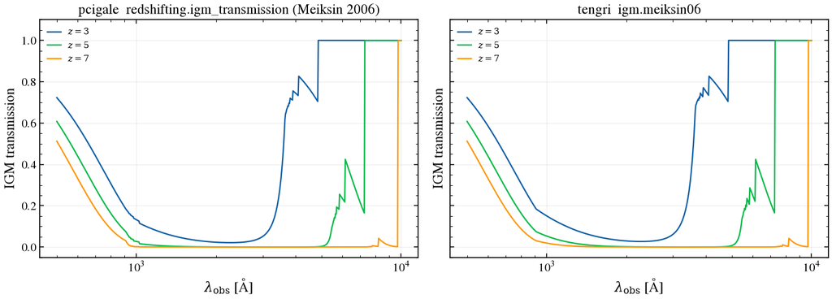

```python
# Both transmission curves come straight from each code's own IGM
# function — no SED build, no flux-ratio reconstruction. CIGALE exposes
# the Meiksin (2006) transmission as
# `pcigale.sed_modules.redshifting.igm_transmission(wave_nm, z)`; tengri
# exposes `igm_transmission_meiksin06(wave_obs_AA, z)`. Same prescription,
# so the curves should overlay.
import jax.numpy as _jnp
from pcigale.sed_modules.redshifting import igm_transmission as cigale_igm

from tengri.igm import igm_transmission_meiksin06

fig, ax_l, ax_r = U.two_panel_fig()
for ax in (ax_l, ax_r):
    ax.set_xlabel(r"$\lambda_{\rm obs}$ [Å]")
    ax.set_ylabel("IGM transmission")
    ax.set_xscale("log")
    ax.set_ylim(-0.05, 1.1)
    ax.grid(True, alpha=0.3)
ax_l.set_title("pcigale  redshifting.igm_transmission (Meiksin 2006)")
ax_r.set_title("tengri  igm.meiksin06")

wave_obs_aa = np.logspace(np.log10(500.0), np.log10(1e4), 600)
print("§12 Meiksin 2006 transmission (tengri − CIGALE) on the plotted grid:")
for color, z in zip(("C0", "C1", "C2"), (3.0, 5.0, 7.0)):
    # CIGALE igm_transmission takes wavelength in nm.
    T_c = np.asarray(cigale_igm(wave_obs_aa / 10.0, z))
    T_t = np.asarray(igm_transmission_meiksin06(_jnp.asarray(wave_obs_aa), z))
    ax_l.plot(wave_obs_aa, T_c, color=color, linewidth=1.4, label=rf"$z = {z:.0f}$")
    ax_r.plot(wave_obs_aa, T_t, color=color, linewidth=1.4, label=rf"$z = {z:.0f}$")
    _dT = np.abs(T_t - T_c)
    _red = wave_obs_aa >= 1026.0 * (1.0 + z)
    print(
        f"    z = {z:.0f}: max |ΔT| redward of Lyβ (rest ≥ 1026 Å) = {float(_dT[_red].max()):.2e}; "
        f"over the whole grid max |ΔT| = {float(_dT.max()):.2e}, "
        f"median |ΔT| = {float(np.median(_dT)):.2e}, "
        f"{int((_dT > 1e-3).sum())}/{_dT.size} points above 1e-3"
    )

for _z in (3.0, 5.0):
    _t_c = float(np.asarray(cigale_igm(np.array([1730.0 / 10.0]), _z))[0])
    _t_t = float(np.asarray(igm_transmission_meiksin06(_jnp.asarray([1730.0]), _z))[0])
    print(f"    T(1730 Å) at z = {_z:.0f}: tengri {_t_t:.6f}, CIGALE {_t_c:.6f}")

ax_l.legend(fontsize=9)

ax_r.legend(fontsize=9)
fig.tight_layout()
save_fig("cigale_12_igm_transmission.png")
```

## tengri in CIGALE-mode — the full X-ray → radio SED

The whole chain at once: tengri configured as CIGALE's `sfhdelayed` + `bc03` + `nebular` + `dustatt_modified_starburst` + `dale2014` + `xray` (Yang+2020) + `radio` chain, overlaid on pcigale at matched parameters. The figure shows ν L_ν over eleven decades of wavelength and the tengri/CIGALE residual below. The radio block is `freefree: False` with `q_IR = 2.5` (§11), so `q_IR` calibrates the synchrotron as in CIGALE's `qir_sf` and the thermal free-free comes from the nebular continuum on both sides.

**The stellar-to-FIR core.** Optical agreement is reported as a normalization ratio and its 16–84 % spread. With the single-screen dust mapping (`tau_bc = 0`) the lower panel's shaded band marks ±25 %. The sub-912 Å excursion is the Lyman-continuum extrapolation. The 1 mm to 1 cm decade carries thermal free-free from the nebular continuum on both codes (Cue's tail on tengri's side, CIGALE's `nebular` module on the other). The X-ray wing is XRB + hot gas with no AGN corona (`alpha_ox` is supplied but there is no disc for it to act on), and the Lehmer+2016 LMXB term is scaled by the SSP mass-weighted age of this galaxy. Every number is printed below.

```
full-SED head-to-head tengri/CIGALE optical (1000–10000 Å): normalization 1.02×, 16–84% spread 1.00–1.07×
  X-ray  1 keV = 0.96×, 5 keV = 0.97×  (XRB + hot gas; no AGN corona)
  radio  1.4 GHz = 1.00×, 150 MHz = 1.01×  (SF synchrotron, q_IR = 2.5 calibrating the non-thermal term)
  mm     1 mm = 1.00×, 3 mm = 1.07×, 1 cm = 1.05×, 3 cm = 1.02×  (one thermal free-free term on the whole grid from the nebular continuum; radio blocks synchrotron-only)
```

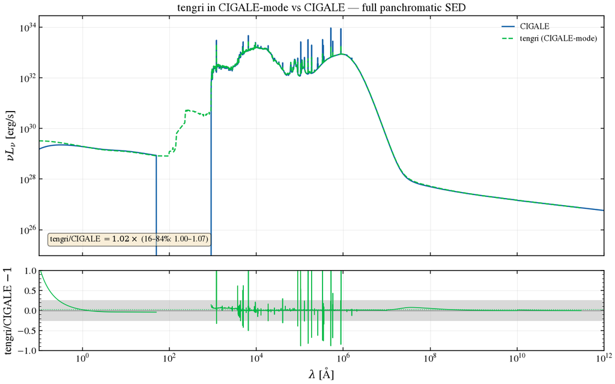

```python
import chex

# The full X-ray -> radio SED: the §6/§7 galaxy (stellar + dust + Dale IR) plus
# the §10 X-ray (Yang+2020 XRB + hot gas, no AGN corona in this galaxy-only
# chain) and the §11 radio (`freefree=False`: q_IR = 2.5 calibrates the
# synchrotron, as CIGALE's `qir_sf`), so the master grid spans ~0.01 Å (hard
# X-ray) to ~1 m (radio).
sed_c_full = C.run_chain(
    [
        (
            "sfhdelayed",
            dict(
                tau_main=1000,
                age_main=5000,
                tau_burst=50,
                age_burst=20,
                f_burst=0.0,
                sfr_A=1.0,
                normalise=True,
            ),
        ),
        ("bc03", dict(imf=1, metallicity=0.02, separation_age=10)),
        NEB_FIDUCIAL_CIGALE,
        ("dustatt_modified_starburst", dict(E_BV_lines=0.3)),
        ("dale2014", dict(alpha=2.0)),
        (
            "yang20",
            dict(
                gam=1.8,
                E_cut=300.0,
                alpha_ox=-1.4,  # no AGN disc here -> corona is zero; XRB + hot gas only
                max_dev_alpha_ox=0.2,
                angle_coef="0.5 & 0",
                det_lmxb=0.0,
                det_hmxb=0.0,
            ),
        ),
        ("radio", dict(qir_sf=2.5, alpha_sf=0.8, R_agn=0.0, alpha_agn=0.7)),
        ("redshifting", dict(redshift=0.0)),
    ]
)
_w_full, _L_full = C.to_lnu(sed_c_full)
w_ext, L_ext = np.asarray(_w_full), np.asarray(_L_full)

m_full = SEDModel.build(
    ssp_data=ssp,
    met=MET_FIDUCIAL,
    sfh={
        "type": "delayed",
        "tau_gyr": Fixed(1.0),
        "age_gyr": Fixed(5.0),
        "log_total_mass": Fixed(0.0),
        "all_params": Fixed(DEFAULT),
    },
    dust_attenuation={
        "type": "two_component",
        "law_bc": "leitherer02",
        "law_diff": "leitherer02",
        "tau_bc": Fixed(TAU_BC_FIDUCIAL),
        "tau_diff": Fixed(TAU_DIFF_FIDUCIAL),
        "lyman_cutoff": True,
        "all_params": Fixed(DEFAULT),
    },
    dust_emission={"type": "dale2014_cigale", "alpha_dale": Fixed(2.0), "all_params": Fixed(DEFAULT)},
    xray={"type": "yang20", "all_params": Fixed(DEFAULT)},
    radio={
        "sf": {"type": "bell2003", "freefree": False},
        "agn": {"type": "powerlaw"},
        "radio_q_ir": Fixed(2.5),
        "radio_alpha_sf": Fixed(0.8),
        "all_params": Fixed(DEFAULT),
    },
    neb=NEB_FIDUCIAL_TENGRI, redshift=Fixed(0.0),
)
s_full = m_full.predict_state({})
wave_t = np.asarray(s_full.wave)
L_t = np.asarray(s_full.sed_intrinsic)

# Put tengri on CIGALE's wavelength grid so the two compare point for point.
L_t_on_ext = U.regrid(wave_t, L_t, w_ext)
chex.assert_equal_shape([L_ext, L_t_on_ext])

mask = (w_ext > 0) & (L_ext > 0) & (L_t_on_ext > 0)
resid = np.full(w_ext.shape, np.nan, dtype=float)
resid[mask] = L_t_on_ext[mask] / L_ext[mask] - 1.0

# Headline numbers: the optical normalization ratio tengri/CIGALE and its
# 16–84% spread. With the shared BC03 grid, matched mass convention and
# single-screen dust mapping the ratio sits near 1. Three things sit outside
# that window: the far-UV, which is §3's age-binning convention; the sub-912 Å
# excursion, which is the Lyman-continuum extrapolation; and the 1 mm–1 m decade,
# where both codes carry thermal free-free from the nebular continuum (Cue's tail
# extends the continuum from the 1 cm table edge to 1 m; CIGALE's `nebular`
# module's native reach) with the radio blocks calibrated on the synchrotron
# alone. The Cue-vs-CLOUDY nebular residual of §8 is part of the optical window.
opt = mask & (w_ext >= 1000.0) & (w_ext <= 10000.0)
ratio_opt = L_t_on_ext[opt] / L_ext[opt]
norm = float(np.median(ratio_opt))
p16, p84 = float(np.percentile(ratio_opt, 16)), float(np.percentile(ratio_opt, 84))
print(
    f"full-SED head-to-head tengri/CIGALE optical (1000–10000 Å): "
    f"normalization {norm:.2f}×, 16–84% spread {p16:.2f}–{p84:.2f}×"
)


def _ratio_at(target_aa: float) -> float:
    """tengri/CIGALE L_ν ratio at the CIGALE grid point nearest ``target_aa``."""
    j = int(np.argmin(np.abs(w_ext - target_aa)))
    return float(L_t_on_ext[j] / L_ext[j]) if L_ext[j] > 0 else float("nan")


_C_AA_HZ = C_AA
print(
    "  X-ray  1 keV = {:.2f}×, 5 keV = {:.2f}×  (XRB + hot gas; no AGN corona)".format(
        _ratio_at(12.398 / 1.0), _ratio_at(12.398 / 5.0)
    )
)
print(
    "  radio  1.4 GHz = {:.2f}×, 150 MHz = {:.2f}×  (SF synchrotron, q_IR = 2.5 calibrating the non-thermal term)".format(
        _ratio_at(_C_AA_HZ / 1.4e9), _ratio_at(_C_AA_HZ / 0.15e9)
    )
)
print(
    "  mm     1 mm = {:.2f}×, 3 mm = {:.2f}×, 1 cm = {:.2f}×, 3 cm = {:.2f}×  "
    "(one thermal free-free term on the whole grid from the nebular continuum; "
    "radio blocks synchrotron-only)".format(
        _ratio_at(1e7), _ratio_at(3e7), _ratio_at(1e8), _ratio_at(3e8)
    )
)
_assert_comparable(L_ext, L_t, name="full-SED head-to-head")

fig, (ax, ax_r) = plt.subplots(
    2, 1, figsize=(11, 7), sharex=True, gridspec_kw={"height_ratios": [3, 1]}
)
# nu L_nu, not L_nu. Over eleven decades of wavelength L_nu is a hopeless
# display coordinate: the synchrotron tail climbs as a power law to the grid
# edge, so the SED spans 16.2 decades in L_nu and any peak-anchored y-limit
# that keeps the stellar and dust humps legible amputates the X-ray and the
# far-UV. The same SED spans 8.5 decades in nu L_nu, so everything fits on one
# axis — and equal areas are equal energy, which is what makes the stellar and
# dust humps read as the comparable reservoirs energy balance says they are.
_nu_ext = _C_AA_HZ / w_ext
nuL_ext = _nu_ext * L_ext
# Mask where tengri's grid has run out rather than let regrid's zero-fill draw a
# vertical cliff at the grid edge — the model stops there, it does not go dark.
nuL_t_on_ext = np.where(L_t_on_ext > 0, _nu_ext * L_t_on_ext, np.nan)
ax.plot(w_ext, nuL_ext, "C0-", linewidth=1.5, label="CIGALE")
ax.plot(w_ext, nuL_t_on_ext, "C1--", linewidth=1.5, label="tengri (CIGALE-mode)")
ax.set_xscale("log")
ax.set_yscale("log")
ax.set_xlim(1e-1, 1e12)  # hard X-ray -> radio
_ymax_h = float(max(np.nanmax(nuL_ext), np.nanmax(nuL_t_on_ext)))
ax.set_ylim(_ymax_h * 1e-9, _ymax_h * 3.0)
ax.set_ylabel(r"$\nu L_\nu$ [erg/s]")
ax.set_title(r"tengri in CIGALE-mode vs CIGALE — full panchromatic SED")
ax.legend(fontsize=10)
ax.grid(True, alpha=0.3)
ax.text(
    0.02,
    0.05,
    rf"tengri/CIGALE $= {norm:.2f}\times$ (16–84%: {p16:.2f}–{p84:.2f})",
    transform=ax.transAxes,
    fontsize=10,
    va="bottom",
    bbox=dict(boxstyle="round", facecolor="wheat", alpha=0.5),
)

ax_r.axhspan(-0.25, 0.25, color="0.85", zorder=0)
ax_r.axhline(0.0, color="0.5", linewidth=0.8)
ax_r.axhline(norm - 1.0, color="C1", linestyle=":", linewidth=0.9)
ax_r.plot(w_ext, resid, "C1-", linewidth=1.0)
ax_r.set_xscale("log")
ax_r.set_xlim(1e-1, 1e12)
ax_r.set_ylim(-1.0, 1.0)
ax_r.set_xlabel(r"$\lambda$ [Å]")
ax_r.set_ylabel(r"tengri/CIGALE $-1$")
ax_r.grid(True, alpha=0.3)
fig.tight_layout()
save_fig("cigale_full_sed_headtohead.png")
plt.show()
```

## Summary

Section by section, tengri / CIGALE as printed above. A ratio is tengri over CIGALE; sweep sections quote the median across the swept cases and the worst printed case.

| § | Block | Agreement | |---|---|---| | 1 | SSP | median residual 2.0–2.2e-8 at every age (float32 round-trip) | | 2 | SFH | `delayed` median 1.00002×; `sfh2exp` median 1.00015×, 2 of 1969 points beyond 1 % (burst step); §2c median 1.000× except periodic exponential 0.999× and rectangular 0.993× | | 3 | stellar SED | 912–1200 Å 1.060×, 1200–3000 Å 1.034×, 0.3–1 µm 1.002×, L_bol 1.016×, Q_H 1.150× (age-binning convention); §3b band medians 0.999–1.020×, worst band 0.837× | | 4 | attenuation laws | max |Δ| 0.252 % (calzleit), 0.247 % (starburst + bump), 0.000 % (CF00); 0.000 % outside the 1500–1800 Å crossover | | 5 | attenuation applied | 0.1–1 µm median 1.0093× intrinsic, 0.9988× attenuated (medians; maxima 14.5 % at 915 Å in 912–1200 Å, 923 % at 1214 Å intrinsic and 94 % at 1216 Å attenuated, at the Lyα edge); §5b band medians 0.998–1.001× | | 6 | dust IR | 10–100 µm median 1.010×; `L_absorbed` 1.0099× `dust.luminosity`; energy balance residual 0; §6c 8–1000 µm medians 1.0095–1.0211×, worst filter 1.370× (`dl2014` α = 1); `schreiber2016` 1.010× | | 7 | panchromatic | 1.0599× (912–1200 Å), 1.0620× (1200–3000 Å), 1.0038× (0.3–1 µm), 1.0075× (3–8 µm), 1.0102× (10–1000 µm) | | 8 | nebular | Q_H 1.145× (shared SSP), 1.378× (dense SSP); Hα 1.35×, [O III] 0.47×, Hβ 1.33×; §8b largest line-ratio ratio-of-ratios 1.03× (Hα/Hβ), 3.96× ([O III]/Hβ), 44.75× ([O II]/Hβ), all at Z_gas = 0.041 (Cue against CIGALE's Cloudy grids; open differences) | | 9 | AGN, SKIRTOR | disc 1.0056×, torus 1.0068×, polar dust 1.0035× (§9); 1.0034×, 1.0106×, 0.9912× with the SKIRTOR disc (§9b); §9d `R_faceon` 0.998095×, polar reference 1.016639× (`polar_law="bongiorno"`; 0.982987× with the default `"smc"`); §9e SKIRTOR grid band medians 1.002–1.007× | | 9 | AGN, Fritz | §9e band medians 0.919–0.970×, worst band 0.843–1.146×; 9, 9 and 10 of 12 bands outside 5 % | | 10 | X-ray | 1.010× at 2 keV and as a 0.5–10 keV median, at i = 0°, 30°, 60° and 80° | | 11 | radio | synchrotron 0.9941–0.9942× across 0.1–100 GHz against 0.9942× predicted from the 21 cm anchor and the energy anchor (`freefree: False`) | | 12 | IGM | max |ΔT| 4.4e-2, 4.6e-2, 2.0e-2 at z = 3, 5, 7; median |ΔT| 6.4e-4, 1.5e-4, 4.4e-7 (open difference: the n ≥ 3 Lyman lines differ blueward of Lyβ); redward of Lyβ the max |ΔT| is printed in §12 | | full | CIGALE-mode SED | optical 1.02× (16–84 %: 1.00–1.07×); X-ray 0.96× (1 keV), 0.97× (5 keV); radio 1.00× (1.4 GHz), 1.01× (150 MHz); 1 mm / 3 mm / 1 cm / 3 cm 1.00× / 1.07× / 1.05× / 1.02× |

Three conventions account for most of the residuals and are stated where they are measured. tengri's age-binning convention (§3) sets the UV, Q_H and, through `L_absorbed`, the ~1 % offset under the dust IR and radio (§6, §11). The nebular emitter differs by design (§8). The polar-dust extinction law must be set to `polar_law="bongiorno"` to match CIGALE (§9, §9d), and `freefree: False` makes `radio_q_ir` calibrate the synchrotron alone, as CIGALE's `qir_sf` does (§11).

## References

- Bell 2003, ApJ 586, 794: IR–radio correlation
- Boquien et al. 2019, A&A 622, A103: CIGALE
- Bruzual & Charlot 2003, MNRAS 344, 1000: BC03 SSPs
- Calzetti et al. 2000, ApJ 533, 682: starburst attenuation law
- Charlot & Fall 2000, ApJ 539, 718: two-component dust
- Condon 1992, ARA&A 30, 575: radio synchrotron / IR–radio correlation
- Dale et al. 2014, ApJ 784, 83: IR dust templates
- Fritz et al. 2006, MNRAS 366, 767: AGN torus
- Inoue et al. 2014, MNRAS 442, 1805: IGM transmission
- Li et al. 2025, ApJ, 986, 9 (Cue, arXiv:2405.04598): neural CLOUDY emulator
- Madau 1995, ApJ 441, 18: original IGM transmission
- Meiksin 2006, MNRAS 365, 807: updated IGM transmission
- Murphy et al. 2011, ApJ 737, 67: free-free radio SFR calibration
- Noll et al. 2009, A&A 507, 1793: modified Calzetti
- Silva et al. 2004, MNRAS 355, 973: AGN torus
- Stalevski et al. 2016, MNRAS 458, 2288: SKIRTOR
- Yang et al. 2020, MNRAS 491, 740: X-ray CIGALE module